# Wine & Dine

## Advanced Machine Learning — Final Project

### Overview

**Wine & Dine** is a multimodal food-to-wine recommendation system. Given only a photograph of a dish, the system identifies the food, encodes its flavor profile into a shared taste embedding space learned from wine reviews, and returns three semantically grounded wine recommendations — each matched by taste-vector similarity and annotated with a match confidence score, a tasting note, and a quality rating.

The project integrates two independently trained deep learning branches — a convolutional image classifier and a recurrent taste encoder — into a unified cross-modal retrieval pipeline. The bridge between modalities is a **512-dimensional taste embedding space** built from 824,000 wine reviews, where both food descriptions and wine tasting notes can be placed using the same encoder and compared by cosine similarity.

### Full Pipeline — One Photo to Three Recommendations

[output not shown]

### The Taste Embedding Space — Core Technical Contribution

The central challenge in food-wine pairing is the **vocabulary gap**: food descriptions use culinary language ("fatty mozzarella", "charred crust") while wine reviews use sensory language ("grippy tannins", "mineral finish"). There is no shared vocabulary to match on.

This project resolves the gap by projecting both modalities through the same encoder:

**Step 1 — Taste axis labelling.** The WineSensed dataset (824k reviews) is annotated along 10 orthogonal sensory axes derived from sommelier literature. Each review can activate multiple axes simultaneously (multi-label):

| Axis (code) | Cluster nickname | Card adjective | Captures | Example wines |
| --- | --- | --- | --- | --- |
| `acidity` | The Electric | *crispy* | Crisp, bright, zingy, racy | Champagne, Vermentino, Albariño |
| `tannin` | The Grippy | *bold* | Drying grip, structure, firm | Barolo, Cabernet Sauvignon, Tannat |
| `red_fruit` | The Berry | *juicy* | Cherry, strawberry, raspberry | Pinot Noir, Beaujolais, Barbera |
| `dark_fruit` | The Dark | *deep* | Plum, blackberry, cassis, fig | Merlot, Shiraz, Zinfandel |
| `earthy` | The Earthy | *earthy* | Soil, leather, herbs, tobacco | Burgundy, Ribera del Duero |
| `sweet` | The Honey | *sweet* | Honey, jam, dessert, residual sugar | Sauternes, Riesling Spätlese |
| `body` | The Velvet | *soft* | Full, round, plush, velvety | White Burgundy, oaked Chardonnay |
| `oaky` | The Smoky | *smoky* | Oak, vanilla, toast, smoke | Rioja Reserva, new-world Chardonnay |
| `floral` | The Floral | *delicate* | Rose, violet, blossom, lavender | Gewürztraminer, Viognier, Moscato |
| `mineral` | The Mineral | *mineral* | Chalk, salinity, flint, slate | Chablis, Muscadet, Sancerre |

**Cluster naming is fully automatic.** After BisectingKMeans groups wine vectors into 9 clusters, TF-IDF extracts the most distinctive vocabulary of each cluster's reviews. The dominant taste axis in that vocabulary becomes the cluster's name — *"The Berry"*, *"The Smoky"*, *"The Earthy & The Bold"*. No cluster label is ever manually assigned.

`red_fruit` and `dark_fruit` are separated deliberately — a single "fruity" axis compressed Pinot Noir (bright cherry) and Shiraz (blackberry, plum) into the same region, destroying their contrast. `mineral` is kept distinct because it is the most food-pairing-relevant axis for shellfish, sashimi, and oysters — a category that grape-based models miss entirely.

**Step 2 — TasteBiLSTM training.** A BiLSTM with Bahdanau attention is trained on the labelled reviews to classify the dominant taste axis. After training, the final hidden state is a 512-d vector that captures sensory character, not grape variety.

**Step 3 — Embedding space quality.** Unlike a grape-variety classifier (pairwise cosine 0.85–0.99, all wines compressed near the decision boundary), the taste space is genuinely spread out: pairwise cosine ranges from −0.097 to 0.841, mean 0.391. BisectingKMeans discovers 9 cohesive, balanced flavor neighborhoods — validated by silhouette score.

**Step 4 — Cross-modal retrieval.** A food's flavor description is tokenised and encoded by the same TasteBiLSTM. The resulting vector lives in the same space as wine review vectors — no translation layer needed. Cosine similarity directly measures taste compatibility.

### Example Output — Pizza Margherita

| **Input** | Photo of pizza margherita |
| --- | --- |
| **CNN output** | Pizza (94% confidence) |
| **Flavor description** | *"Savory tomato sauce with dried oregano and basil, fatty mozzarella, charred yeasty crust..."* |

[output not shown]

*Bold Move confidence = normalised contrast strength (not cosine similarity).*

### Models and Components

[output not shown]

### Pairing Logic

| Card | Strategy | How the cluster is chosen | How the wine is chosen |
| --- | --- | --- | --- |
| **Safe Bet** ✅ | Echoes the dish's dominant flavor | Nearest centroid (cosine) to the "classic" description | Pool wine with highest cosine to food vector |
| **Hidden Gem** 💎 | Compatible but unexpected | Nearest centroid to the "surprising" description | Pool wine with highest cosine to food vector |
| **Bold Move** 🔥 | Contrasting — resets the palate | distance × (1 + secondary affinity) — contrast that's still drinkable | Pool wine with highest cosine to food vector |

Every match is driven entirely by the shared taste embedding space. No pairing rules are hardcoded.

### Why Taste Clusters — Not Grape Varieties?

The first design iteration mapped food descriptions directly to the 15 grape-variety centroids from the BiLSTM classifier. It failed: cross-entropy training compresses all class embeddings toward their decision boundaries — pairwise cosine similarity between grape centroids was 0.85–0.99. Every food received the same Sangiovese or Tempranillo suggestion regardless of flavor profile.

The solution is to train a model on **sensory axes** rather than labels. Taste-axis training does not push all wines toward a boundary — it spreads them across a continuous sensory manifold. BisectingKMeans on this manifold discovers 9 flavor neighborhoods that correspond to recognisable wine style categories (structured reds, fresh whites, mineral wines, etc.) with balanced cluster sizes and meaningful vocabulary differences confirmed by TF-IDF.

### Datasets

| Dataset | Size | Source | Used for |
| --- | --- | --- | --- |
| Food-101 | 101,000 images · 101 classes | `torchvision.datasets.Food101` | CNN training and evaluation |
| WineSensed (NeurIPS 2023) | 824,000 reviews | `Dakhoo/L2T-NeurIPS-2023` on Hugging Face | LSTM / BiLSTM / TasteBiLSTM training · tasting note retrieval |
| Food flavor table | 101 entries × 3 descriptions | `data/food_flavor_description_v2.json` (LLM-generated, Claude Sonnet 4.6) | Cross-modal bridge: food → wine-register text |

### Development Phases

| Phase | Where | Sections | GPU |
| --- | --- | --- | --- |
| Phase 0 | Colab | Appendix — 8 failed architectures (grape centroids, transformers, triplet loss…) | ✓ |
| Phase 1 | Local | §§1–5, 7, 11 — data, EDA, text, RNN | ✗ |
| Phase 2 | Colab | §§6, 8, 9 — preprocessing, CNNs | ✓ |
| Phase 3 | Local | §§10, 13 — Grad-CAM, export | ✗ |
| Phase 4 | Colab | §§12, 14, 15 — TasteBiLSTM, clustering, joint | ✓ |
| Phase 5 | HF Spaces | §16 — Gradio deployment | ✗ |

### Notebook Structure

| Section | Status | Content |
| --- | --- | --- |
| 1 | ✅ Done | Environment setup — packages, imports, storage helpers |
| 2 | ✅ Done | Raw data loading — Food-101, WineSensed |
| 3 | ✅ Done | Data cleaning — WineSensed, top-15 grape selection, food flavor table |
| 4 | ✅ Done | Train / val / test split — both datasets, stratified |
| 5 | ✅ Done | EDA — image and text datasets |
| 6 | ✅ Done | Image preprocessing and DataLoaders |
| 7 | ✅ Done | Text preprocessing — tokenisation, vocab, GloVe, Word2Vec, DataLoaders |
| 8 | ✅ Done | CNN from scratch — architecture, training, evaluation |
| 9 | ✅ Done | CNN ResNet-50 — two-phase fine-tuning, evaluation, comparison |
| 10 | ✅ Done | CNN explainability — Grad-CAM |
| 11 | ✅ Done | RNN/LSTM — LSTM baseline, BiLSTM + attention, DistilBERT *(+3 pts)*, comparison |
| 12 | ✅ Done | TasteBiLSTM — taste-label dataset, training, evaluation, encoder export |
| 13 | ✅ Done | Save all models — weights, Drive sync |
| 14 | ✅ Done | Flavor-cluster recommendation — BisectingKMeans K=9, `recommend_v2()`, 101-food evaluation |
| 15 | ✅ Done | Joint model — multimodal fusion: CNN + TasteBiLSTM → flavor-cluster prediction *(+10 pts bonus)* |
| 16 | ✅ Done | Deployment — Gradio app on HuggingFace Spaces |
| 17 | ✅ Done | Business framing, ethics, team contributions |

| 18 | ✅ Done | Appendix — Road to the final architecture: 8 failed approaches and lessons learned |

## Section 1 — Environment Setup

This section prepares the execution environment before any data is loaded or models are trained. It must be run in full at the start of every Colab session.

**Four steps:**

1. **Environment check** — confirm Colab + CUDA availability before installing packages
2. **pip installs** — install and version-pin all required libraries (PyTorch, gensim, transformers, etc.)
3. **Library imports** — import all packages, set the random seed for reproducibility, detect hardware
4. **Storage helpers** — define `save_checkpoint()` / `load_checkpoint()` / `save_figure()` that transparently handle the Colab VM → Google Drive save flow

> **Always re-run Section 1 completely when starting a fresh Colab session.** Skipping any cell will cause import errors or missing helpers in later sections.

```python
import sys, torch

IN_COLAB = "google.colab" in sys.modules

# ── CUDA health check ─────────────────────────────────────────────────────────
# torch.cuda.is_available() can return True yet the GPU kernel image may not
# match the installed PyTorch build (AcceleratorError: no kernel image for device).
# We probe with a small operation and fall back to CPU if it fails.
_cuda_ok = False
if torch.cuda.is_available():
    try:
        torch.zeros(1).cuda()
        _cuda_ok = True
    except Exception as _e:
        print(f"⚠  CUDA reported available but failed health check: {_e}")
        print("   Falling back to CPU. For GPU support reinstall PyTorch with the")
        print("   correct CUDA version: Runtime → Factory reset → reinstall torch.")

DEVICE = torch.device("cuda" if _cuda_ok else "cpu")

print(f"{'Environment':<20} {'Google Colab' if IN_COLAB else 'Local'}")
print(f"{'Device':<20} {DEVICE}")
print(f"{'CUDA available':<20} {torch.cuda.is_available()}  (healthy: {_cuda_ok})")

if not IN_COLAB:
    print("\n⚠  Not running in Google Colab — GPU sections (6, 8, 9, 12, 14) require Colab.")
elif not _cuda_ok:
    print("\n⚠  CUDA not healthy — enable the T4 GPU runtime: Runtime → Change runtime type → T4 GPU.")
else:
    print("\n✓ Environment check passed — Colab + CUDA confirmed.")
```

```
Environment          Google Colab
Device               cuda
CUDA available       True  (healthy: True)

✓ Environment check passed — Colab + CUDA confirmed.
```

### 1.1 — Package installation

Installs all required libraries and pins them to specific versions to guarantee reproducibility across Colab sessions and local environments.

> ⚠️ **Expected behaviour — the kernel will crash and restart when you run this cell.** This is intentional and required, not an error. Python cannot hot-reload an upgraded package into a running process, so the cell deliberately triggers a kernel restart after any install or upgrade. **After the restart, continue from Section 1.2 — do not re-run Section 1.1.** If all packages are already at the correct versions, no restart occurs and the cell exits in under 5 seconds.

**Design decisions:**

- **Version pinning** (`gensim==4.3.3`, `transformers>=4.40`) prevents silent breakage from upstream API changes — gensim's Word2Vec API changed significantly between versions 3 and 4.
- **Child-process probe for transformers** — a broken transformers install can crash the kernel (segfault), not just raise `ImportError`. We test it in a subprocess so a failure is caught cleanly.
- **Automatic kernel restart** — if any package was installed or upgraded, the kernel restarts immediately. Python cannot hot-reload packages into a running process; skipping the restart causes silent import of the old version.
- **Environment detection** — PyTorch is installed with the CUDA 11.8 wheel on Colab and the CPU wheel locally, saving several hundred MB on local machines.

```python
import subprocess, sys, importlib.util, importlib.metadata

def pip_install(*args):
    subprocess.check_call([sys.executable, "-m", "pip", "install", "--quiet", *args])

def is_installed(import_name):
    return importlib.util.find_spec(import_name) is not None

def installed_version(dist_name):
    try:
        return importlib.metadata.version(dist_name)
    except importlib.metadata.PackageNotFoundError:
        return None

# ── Detect environment ────────────────────────────────────────────
IN_COLAB = "google.colab" in sys.modules
print(f"Environment: {'Google Colab' if IN_COLAB else 'Local'}")

_anything_installed = False   # only True if something actually changed on disk

# ── Install PyTorch with correct backend ────────────────────────────────
if is_installed("torch"):
    import torch
    print(f"  OK  torch {torch.__version__}")
else:
    print("  INSTALLING  torch ...")
    if IN_COLAB:
        pip_install("torch", "torchvision", "torchaudio",
                    "--index-url", "https://download.pytorch.org/whl/cu118")
    else:
        pip_install("torch", "torchvision", "torchaudio",
                    "--index-url", "https://download.pytorch.org/whl/cpu")
    print("  DONE  torch")
    _anything_installed = True

# ── Pinned packages — only install/upgrade when the version is wrong ──────────
# Python can't reload packages into a running process; any real install requires
# a kernel restart. We avoid spurious restarts by checking the version first.
_PINNED = {
    "gensim":   ("gensim",   "4.3.3"),
    "datasets": ("datasets", "2.20.0"),
}

for _import_name, (_dist_name, _target_ver) in _PINNED.items():
    _cur = installed_version(_dist_name)
    if _cur == _target_ver:
        print(f"  OK  {_dist_name} {_cur}")
    else:
        print(f"  INSTALLING  {_dist_name}=={_target_ver}  (current: {_cur}) ...")
        pip_install(f"{_dist_name}=={_target_ver}")
        print(f"  DONE  {_dist_name}=={_target_ver}")
        _anything_installed = True

# ── Early restart if pinned packages changed ────────────────────────────────
# Restart now so the transformers probe always runs on a stable, clean kernel.
if _anything_installed:
    print("\nPinned packages changed — restarting kernel before continuing ...")
    if IN_COLAB:
        import os, signal; os.kill(os.getpid(), signal.SIGKILL)
    else:
        import IPython; ip = IPython.get_ipython()
        if ip: ip.ask_exit()

# ── Install remaining packages ────────────────────────────────────────────
PACKAGES = {
    "nltk":       "nltk",
    "torchcam":   "torchcam",
    "wordcloud":  "wordcloud",
    "matplotlib": "matplotlib",
    "seaborn":    "seaborn",
    "pandas":     "pandas",
    "sklearn":    "scikit-learn",
    "PIL":        "Pillow",
    "ipywidgets": "ipywidgets",
    "tqdm":       "tqdm",
}

for pkg, install_name in PACKAGES.items():
    if is_installed(pkg):
        print(f"  OK  {pkg}")
    else:
        print(f"  INSTALLING  {pkg} ...")
        pip_install(install_name)
        print(f"  DONE  {pkg}")
        _anything_installed = True

# ── Transformers ecosystem (DistilBERT bonus, Section 11.10–11.12) ────────────
# Probe in a *child process* so a broken pre-installed transformers
# (which can crash/segfault, not just raise ImportError) cannot kill this kernel.
_tf_ok = subprocess.call(
    [sys.executable, "-c",
     "from transformers import DistilBertTokenizerFast, DistilBertModel"],
    stdout=subprocess.DEVNULL,
    stderr=subprocess.DEVNULL,
) == 0

if _tf_ok:
    _tf_ver = installed_version("transformers") or "unknown"
    print(f"  OK  transformers {_tf_ver}")
else:
    print("  INSTALLING  transformers ecosystem (import probe failed) ...")
    pip_install(
        "transformers>=4.40.0,<5.0",
        "tokenizers>=0.19,<1.0",
        "huggingface-hub>=0.23,<1.0",
        "safetensors>=0.4",
    )
    print("  DONE  transformers ecosystem")
    _anything_installed = True

# ── Auto-restart kernel if anything was installed ─────────────────────────────
if _anything_installed:
    print("\nPackages installed/upgraded — restarting kernel automatically ...")
    if IN_COLAB:
        import os, signal
        os.kill(os.getpid(), signal.SIGKILL)
    else:
        import IPython
        ip = IPython.get_ipython()
        if ip is not None:
            ip.ask_exit()
        else:
            print("  \u26a0  Could not auto-restart. Please restart the kernel manually.")
else:
    print("\nAll packages already at required versions — no restart needed.")
    print("Continue to the next cell.")
```

```
Environment: Google Colab
  OK  torch 2.10.0+cu128
  OK  gensim 4.3.3
  OK  datasets 2.20.0
  OK  nltk
  OK  torchcam
  OK  wordcloud
  OK  matplotlib
  OK  seaborn
  OK  pandas
  OK  sklearn
  OK  PIL
  OK  ipywidgets
  OK  tqdm
  OK  transformers 5.0.0

All packages already at required versions — no restart needed.
Continue to the next cell.
```

### 1.2 — Library imports and global configuration

Imports all packages used across the notebook and sets three global constants that every subsequent section depends on:

| Constant | Value | Purpose |
| --- | --- | --- |
| `SEED` | `42` | Fixed random seed — passed to `random`, `numpy`, `torch`, and all `train_test_split` calls |
| `DEVICE` | `cuda` or `cpu` | Auto-detected — all tensors and models are moved here |
| `IN_COLAB` | `True` / `False` | Controls Drive paths, display behavior, and install logic |

**Reproducibility:** `SEED = 42` is applied to `random.seed()`, `np.random.seed()`, `torch.manual_seed()`, and `torch.cuda.manual_seed_all()`. This ensures that weight initialisation, data shuffling, and train/val/test splits produce identical results across runs.

**Project directories** (`weights/`, `figures/`, `deployment/`, `data/`) are created here if they do not exist. On Colab these are temporary VM folders; the permanent copies live on Google Drive (set up in Section 1.3).

```python
# ── Standard library ──────────────────────────────────────────────────────────
import os
import sys
import random
import importlib
from pathlib import Path
from collections import Counter

# Suppress HF Hub symlinks warning on Windows (fallback to copies, still works)
os.environ.setdefault("HF_HUB_DISABLE_SYMLINKS_WARNING", "1")

# ── Numeric / data ────────────────────────────────────────────────────────────
import numpy as np
import pandas as pd

# ── Visualisation ─────────────────────────────────────────────────────────────
import matplotlib.pyplot as plt
import seaborn as sns
from wordcloud import WordCloud
from PIL import Image

# ── PyTorch core ──────────────────────────────────────────────────────────────
import torch
import torch.nn as nn
import torch.nn.functional as F
from torch.utils.data import Dataset, DataLoader, random_split
from torch.optim import Adam
from torch.optim.lr_scheduler import ReduceLROnPlateau

# ── Computer vision ───────────────────────────────────────────────────────────
import torchvision.transforms as T
import torchvision.models as models
import torchvision.datasets as tv_datasets
from torchcam.methods import GradCAM

# ── NLP ───────────────────────────────────────────────────────────────────────
import nltk
from nltk.tokenize import word_tokenize
from tqdm import tqdm

# ── Word embeddings ───────────────────────────────────────────────────────────
import gensim
import gensim.downloader as gensim_api
from gensim.models import Word2Vec, KeyedVectors

# ── Transformers (DistilBERT bonus, Section 11) ───────────────────────────────
from transformers import DistilBertTokenizerFast, DistilBertModel

# ── Sklearn ───────────────────────────────────────────────────────────────────
from sklearn.model_selection import train_test_split
from sklearn.metrics import classification_report, confusion_matrix, f1_score
from sklearn.cluster import KMeans
from sklearn.preprocessing import LabelEncoder

# ── Environment ───────────────────────────────────────────────────────────────
IN_COLAB = "google.colab" in sys.modules

# ── Reproducibility ───────────────────────────────────────────────────────────
SEED = 42
random.seed(SEED)
np.random.seed(SEED)
torch.manual_seed(SEED)
if torch.cuda.is_available():
    torch.cuda.manual_seed_all(SEED)

DEVICE = torch.device("cuda" if torch.cuda.is_available() else "cpu")

# ── Project directories ───────────────────────────────────────────────────────
BASE_DIR = Path(".")
WEIGHTS  = BASE_DIR / "weights"
FIGURES  = BASE_DIR / "figures"
DEPLOY   = BASE_DIR / "deployment"
DATA_DIR = BASE_DIR / "data"

for d in [WEIGHTS, FIGURES, DEPLOY, DATA_DIR]:
    d.mkdir(exist_ok=True)

# ── NLTK data ─────────────────────────────────────────────────────────────────
nltk.download("punkt",     quiet=True)
nltk.download("punkt_tab", quiet=True)
nltk.download("stopwords", quiet=True)

# ── Summary ───────────────────────────────────────────────────────────────────
print(f"Environment : {'Google Colab' if IN_COLAB else 'Local'}")
print(f"Device      : {DEVICE}")
if torch.cuda.is_available():
    props = torch.cuda.get_device_properties(0)
    print(f"GPU         : {props.name}  ({props.total_memory // 1024**3} GB)")
print(f"Directories : weights/  figures/  deployment/  data/")
print()
print("Key library versions:")
for lib in ["torch", "numpy", "pandas", "gensim", "transformers", "sklearn"]:
    try:
        mod = importlib.import_module(lib)
        print(f"  {lib:<16} {getattr(mod, '__version__', 'n/a')}")
    except ImportError:
        print(f"  {lib:<16} NOT INSTALLED")
print("\nSection 1.2 complete — ready for storage setup.")
```

```
Environment : Google Colab
Device      : cuda
GPU         : Tesla T4  (14 GB)
Directories : weights/  figures/  deployment/  data/

Key library versions:
  torch            2.10.0+cu128
  numpy            1.26.4
  pandas           2.2.2
  gensim           4.3.3
  transformers     5.0.0
  sklearn          1.6.1

Section 1.2 complete — ready for storage setup.
```

### 1.3 — Storage setup: Colab VM → Google Drive save flow

**The problem:** Google Colab's `/content/` filesystem is ephemeral — it is wiped when the runtime disconnects or times out. Training a ResNet-50 for 15 epochs takes ~30 minutes on a T4; losing that without a backup would mean retraining from scratch.

**The solution:** a three-step save helper that writes to both the fast VM disk and Google Drive:

```
Step 1 → Save to /content/weights/           (fast, temporary — wiped on disconnect)
Step 2 → Copy  to /MyDrive/wine-dine/weights/  (permanent — survives all disconnects)
Step 3 → Verify the Drive copy is non-empty    (catches silent network write failures)
```

If Step 2 or 3 fails, a clear warning is printed and the local copy is preserved.

**Helper functions defined in the code cell below:**

| Function | Purpose |
| --- | --- |
| `save_checkpoint(state, filename)` | Save any dict (model weights, optimiser state, epoch, metrics) as a `.pt` file using the 3-step flow |
| `load_checkpoint(filename, device)` | Load a `.pt` file — tries the Colab VM first (fast), falls back to Drive if not found |
| `save_figure(fig, filename)` | Save a matplotlib figure to `figures/` locally and Drive |

On a local machine (VS Code / CPU), all saves go directly to `./weights/` and `./figures/` — no Drive is mounted.

> **Run this cell before any training cell.** After a Colab disconnect, re-run all of Section 1, then load the most recent checkpoint with `load_checkpoint()` to resume.

```python
# ── 1.3  Storage Setup ────────────────────────────────────────────────────────
import shutil

# ── Paths ─────────────────────────────────────────────────────────────────────
LOCAL_WEIGHTS = WEIGHTS   # Path object defined in Section 1.2
LOCAL_FIGURES = FIGURES

if IN_COLAB:
    from google.colab import drive
    drive.mount('/content/drive')
    DRIVE_DIR   = '/content/drive/MyDrive/wine-dine'
    WEIGHTS_DIR = f'{DRIVE_DIR}/weights'
    FIGURES_DIR = f'{DRIVE_DIR}/figures'
    for d in [DRIVE_DIR, WEIGHTS_DIR, FIGURES_DIR]:
        os.makedirs(d, exist_ok=True)
    print("✓ Google Drive mounted")
    print(f"  Permanent weights → {WEIGHTS_DIR}")
    print(f"  Permanent figures → {FIGURES_DIR}")
else:
    WEIGHTS_DIR = str(WEIGHTS)
    FIGURES_DIR = str(FIGURES)
    print("✓ Local mode — no Drive needed")
    print(f"  Weights → {WEIGHTS_DIR}")
    print(f"  Figures → {FIGURES_DIR}")


# ─────────────────────────────────────────────────────────────────────────────
# save_checkpoint  — best-model save (overwrites; call only when val improves)
# ─────────────────────────────────────────────────────────────────────────────
def save_checkpoint(state, filename):
    """
    Save a best-model checkpoint. Call only when validation improves.
    Overwrites a single file — no per-epoch accumulation.

    On Colab (3 steps):
      1. Save to /content/weights/<filename>   ← fast, temporary (wiped on disconnect)
      2. Copy  to Google Drive/<filename>       ← permanent, survives disconnect
      3. Verify Drive copy is not empty         ← catches silent failures

    Locally:
      Saves directly to ./weights/<filename>

    Usage:
        if val_acc > best_val_acc:
            best_val_acc = val_acc
            save_checkpoint(model.state_dict(), "my_model_best.pt")
    """
    local_path = os.path.join(str(LOCAL_WEIGHTS), filename)
    torch.save(state, local_path)

    if IN_COLAB:
        drive_path = os.path.join(WEIGHTS_DIR, filename)
        try:
            shutil.copy2(local_path, drive_path)
        except Exception as e:
            print(f"  ⚠️  Drive copy FAILED for '{filename}': {e}")
            print(f"  ⚠️  Local copy safe at: {local_path}  (temporary!)")
            return
        if os.path.getsize(drive_path) == 0:
            print(f"  ⚠️  Drive copy of '{filename}' is empty.")
            return
        print(f"  ✓ {filename}  →  Colab VM + Drive")
    else:
        print(f"  ✓ {filename}  →  {local_path}")


# ─────────────────────────────────────────────────────────────────────────────
# load_checkpoint  — VM first, Drive fallback
# ─────────────────────────────────────────────────────────────────────────────
def load_checkpoint(filename, device=None):
    """
    Load a saved checkpoint (state dict).

    Tries Colab VM first; falls back to Drive if not found on VM.

    Usage:
        model.load_state_dict(load_checkpoint("my_model_best.pt"))
    """
    if device is None:
        device = DEVICE

    local_path = os.path.join(str(LOCAL_WEIGHTS), filename)
    if os.path.exists(local_path):
        print(f"  → Loading from VM: {local_path}")
        return torch.load(local_path, map_location=device, weights_only=False)

    if IN_COLAB:
        drive_path = os.path.join(WEIGHTS_DIR, filename)
        if os.path.exists(drive_path):
            print(f"  → Loading from Drive: {drive_path}")
            return torch.load(drive_path, map_location=device, weights_only=False)
        raise FileNotFoundError(
            f"\n❌ '{filename}' not found on VM ({local_path}) or Drive ({drive_path}).\n"
            f"   Train the model first, or re-run Section 1.3 to mount Drive."
        )

    raise FileNotFoundError(
        f"\n❌ '{filename}' not found at: {local_path}\n"
        f"   Run the training cell first."
    )


# ─────────────────────────────────────────────────────────────────────────────
# save_figure  — save matplotlib figure locally and to Drive
# ─────────────────────────────────────────────────────────────────────────────
def save_figure(fig, filename, dpi=100):
    """
    Save a matplotlib figure.

    Usage:
        fig, ax = plt.subplots()
        ax.plot(...)
        save_figure(fig, "my_plot.png")
        plt.show()
    """
    local_path = os.path.join(str(LOCAL_FIGURES), filename)
    fig.savefig(local_path, dpi=dpi, bbox_inches="tight")

    if IN_COLAB:
        drive_path = os.path.join(FIGURES_DIR, filename)
        try:
            shutil.copy2(local_path, drive_path)
        except Exception as e:
            print(f"  ⚠️  Drive copy FAILED for '{filename}': {e}")
            return
        if os.path.getsize(drive_path) == 0:
            print(f"  ⚠️  Drive copy of '{filename}' is empty.")
            return
        print(f"  ✓ {filename}  →  Colab VM + Drive")
    else:
        print(f"  ✓ {filename}  →  {local_path}")


# ─────────────────────────────────────────────────────────────────────────────
# restore_weights_from_drive  — bulk copy Drive → VM at session start
# ─────────────────────────────────────────────────────────────────────────────
def restore_weights_from_drive():
    """
    Copy all .pt files from Google Drive back to the Colab VM.
    Call once at the start of a new session after Drive is mounted.
    Has no effect locally.
    """
    if not IN_COLAB:
        print("  (local mode — nothing to restore)")
        return

    if not os.path.isdir(WEIGHTS_DIR):
        print(f"  ⚠️  Drive weights folder not found: {WEIGHTS_DIR}")
        return

    files = [f for f in os.listdir(WEIGHTS_DIR) if f.endswith("_best.pt")]
    if not files:
        print(f"  ℹ️  No *_best.pt files in {WEIGHTS_DIR} — train first.")
        return

    copied, skipped = 0, 0
    for fname in sorted(files):
        src  = os.path.join(WEIGHTS_DIR, fname)
        dest = os.path.join(str(LOCAL_WEIGHTS), fname)
        if os.path.exists(dest) and os.path.getsize(dest) == os.path.getsize(src):
            skipped += 1
            continue
        shutil.copy2(src, dest)
        print(f"  ✓ Restored: {fname}  ({os.path.getsize(dest) / 1e6:.1f} MB)")
        copied += 1

    print(f"restore_weights_from_drive: {copied} copied, {skipped} already up-to-date.")


# ── Auto-restore on Colab at session start ────────────────────────────────────
restore_weights_from_drive()

print("\n✓ Storage helpers ready:  save_checkpoint | load_checkpoint | save_figure | restore_weights_from_drive")
```

```
✓ Google Drive mounted
  Permanent weights → /content/drive/MyDrive/wine-dine/weights
  Permanent figures → /content/drive/MyDrive/wine-dine/figures
  ✓ Restored: joint_cnn_best.pt  (96.5 MB)
  ✓ Restored: joint_full_best.pt  (109.0 MB)
  ✓ Restored: joint_rnn_best.pt  (12.0 MB)
  ✓ Restored: lstm_best.pt  (5.3 MB)
  ✓ Restored: mpnet_supcon_best.pt  (0.9 MB)
  ✓ Restored: resnet50_phaseA_best.pt  (95.2 MB)
  ✓ Restored: tastebilstm_best.pt  (11.5 MB)
restore_weights_from_drive: 7 copied, 4 already up-to-date.

✓ Storage helpers ready:  save_checkpoint | load_checkpoint | save_figure | restore_weights_from_drive
```

### 1.4 — Download trained weights to your local machine

After training in Colab, this cell lets you retrieve all saved weights and figures to your local machine in one step — without manually navigating Google Drive.

**Two-step workflow:**

| Step | Where | Action |
| --- | --- | --- |
| **Step A** | Colab | Run cell — zips all `weights/` and `figures/` files, uploads the zip to Drive, prints a `DRIVE_FILE_ID` |
| **Step B** | Local (VS Code) | Run the same cell — uses `gdown` to pull the zip from Drive by that ID and extracts it into `wine-dine/weights/` |

The cell auto-detects whether it is running on Colab or locally, so the same code cell handles both directions.

> **When to use:** after finishing a training phase in Colab (e.g., after Section 9 — ResNet-50), run this cell on Colab to package the weights, then switch to VS Code and run it again to download them. This keeps the local repository in sync with the latest Colab outputs.

```python
# ── 1.4  Weights ↔ Google Drive ↔ Local PC ────────────────────────────────────
#
# ON COLAB:  zip weights → share on Drive → print the file ID
# ON LOCAL:  pull that zip from Drive via gdown → extract to ./weights/
# ──────────────────────────────────────────────────────────────────────────────

# ══════════════════════════════════════════════════════════════════════════════
# ▶ PASTE YOUR DRIVE FILE ID HERE (printed when you run this cell on Colab):
WEIGHTS_ZIP_ID = ""   # e.g. "1aBcDeFgHiJkLmNoPqRsTuVwXyZ"
# ══════════════════════════════════════════════════════════════════════════════

if IN_COLAB:
    # ── COLAB SIDE: zip + share + print ID ────────────────────────────────────
    import zipfile, glob

    # Step 1: ensure weights are on VM
    print("Step 1 — restoring weights from Google Drive to Colab VM ...")
    restore_weights_from_drive()

    # Step 2: create zip
    found = sorted(glob.glob(os.path.join(str(LOCAL_WEIGHTS), "*.pt")))
    found += sorted(glob.glob(os.path.join(str(LOCAL_WEIGHTS), "*.pth")))

    if not found:
        print("\n⚠️  No .pt / .pth files found — train the model first!")
    else:
        zip_name = "wine-dine-weights.zip"
        zip_path = os.path.join(DRIVE_DIR, zip_name)

        print(f"\nStep 2 — creating {zip_name} on Google Drive ...")
        with zipfile.ZipFile(zip_path, 'w', zipfile.ZIP_DEFLATED) as zf:
            for fpath in found:
                fname = os.path.basename(fpath)
                size_mb = os.path.getsize(fpath) / 1e6
                print(f"  + {fname}  ({size_mb:.1f} MB)")
                zf.write(fpath, arcname=fname)

        zip_size = os.path.getsize(zip_path) / 1e6
        print(f"\n✓ Zip created: {zip_path}  ({zip_size:.1f} MB)")

        # Step 3: make it shareable and get file ID
        print("\nStep 3 — making zip shareable (anyone with link) ...")
        from google.colab import drive as _drive
        from googleapiclient.discovery import build
        from google.auth import default

        creds, _ = default()
        service = build('drive', 'v3', credentials=creds)

        # Find the file on Drive
        query = f"name='{zip_name}' and trashed=false"
        results = service.files().list(q=query, fields="files(id,name)").execute()
        files = results.get('files', [])

        if files:
            file_id = files[0]['id']
            # Make it accessible to anyone with the link
            service.permissions().create(
                fileId=file_id,
                body={'type': 'anyone', 'role': 'reader'},
            ).execute()

            print(f"\n{'='*70}")
            print(f"  ✓ DONE!  Copy this ID into WEIGHTS_ZIP_ID in this cell:")
            print(f"")
            print(f'    WEIGHTS_ZIP_ID = "{file_id}"')
            print(f"")
            print(f"  Then run this same cell on your LOCAL machine to download.")
            print(f"{'='*70}")
        else:
            print("  ⚠️  Could not find zip on Drive — try downloading manually.")

else:
    # ── LOCAL SIDE: pull zip from Drive using gdown ───────────────────────────
    if not WEIGHTS_ZIP_ID:
        print("⚠️  WEIGHTS_ZIP_ID is empty!")
        print("   → Run this cell on Colab first to get the ID.")
        print("   → Then paste it into WEIGHTS_ZIP_ID above and re-run locally.")
    else:
        import subprocess, sys, zipfile

        # Install gdown if needed
        try:
            import gdown
        except ImportError:
            subprocess.check_call([sys.executable, "-m", "pip", "install", "gdown", "-q"])
            import gdown

        zip_dest = str(WEIGHTS / "wine-dine-weights.zip")
        url = f"https://drive.google.com/uc?id={WEIGHTS_ZIP_ID}"

        print(f"Downloading weights from Google Drive ...")
        print(f"  ID:   {WEIGHTS_ZIP_ID}")
        print(f"  Dest: {WEIGHTS}/\n")

        gdown.download(url, zip_dest, quiet=False)

        # Extract
        print(f"\nExtracting to {WEIGHTS} ...")
        with zipfile.ZipFile(zip_dest, 'r') as zf:
            zf.extractall(str(WEIGHTS))
            names = zf.namelist()

        # Clean up zip
        os.remove(zip_dest)

        print(f"\n✓ Done! {len(names)} file(s) extracted to {WEIGHTS}/")
        for n in sorted(names):
            size_mb = os.path.getsize(str(WEIGHTS / n)) / 1e6
            print(f"  • {n}  ({size_mb:.1f} MB)")
```

## Section 2 — Raw Data Loading

This section loads both datasets in their **original, uncleaned form**. No rows are dropped, no columns are filtered, and no transformations are applied. The goal is to confirm that the data arrived correctly and to establish a baseline picture of what we are working with before any cleaning decisions are made.

**Why load raw before cleaning?**  
If you clean and load in the same step, you cannot inspect what was removed. Keeping loading and cleaning as separate steps (Sections 2 and 3) means every dropped row is an explicit, documented decision — not a silent side effect of the loader.

**Two data sources:**

[output not shown]

### 2.1 — Load Food-101

Food-101 is loaded via `torchvision.datasets.Food101`. On the first run it downloads and extracts the dataset to `data/food-101/` (~5 GB). Subsequent runs load from disk instantly from the cache.

**Dataset structure:** 1,000 images per class — 750 in the official train split and 250 in the test split — for a total of 75,750 training and 25,250 test images. The class distribution is perfectly balanced by design, which means no class weighting is needed for the image model.

**Validation checks performed:**

- Train split has exactly 75,750 images, test split has 25,250
- Number of unique class labels equals 101
- Spot-check: first 10 integer labels are in the valid range [0, 100]

> The official Food-101 train/test split (75k/25k) does **not** match the required 70/15/15 ratio. We will pool both splits in Section 4 and create a fresh stratified split.

```python
# ── 2.1  Load Food-101 via torchvision ───────────────────────────────────────
# torchvision.datasets.Food101 downloads to DATA_DIR/food-101/ on first run.
# Subsequent runs load from the local cache — no network needed.
FOOD101_ROOT = DATA_DIR  # downloads into DATA_DIR/food-101/

print("Loading Food-101 (train split) …")
ds_train = tv_datasets.Food101(root=FOOD101_ROOT, split="train", download=True)
print("Loading Food-101 (test split) …")
ds_test  = tv_datasets.Food101(root=FOOD101_ROOT, split="test",  download=True)
print("Done.\n")

# ── Inspect structure ─────────────────────────────────────────────────────────
train_size  = len(ds_train)
test_size   = len(ds_test)
class_names = ds_train.classes          # list of 101 food names
n_classes   = len(class_names)

print(f"{'Split':<15} {'Rows':>8}")
print("-" * 25)
print(f"{'train':<15} {train_size:>8,}")
print(f"{'test':<15} {test_size:>8,}")
print(f"{'total':<15} {train_size + test_size:>8,}")
print()
print(f"Classes : {n_classes}")
print(f"Example labels: {class_names[:5]} … {class_names[-5:]}")

# ── Validation ────────────────────────────────────────────────────────────────
assert train_size == 75_750, f"Expected 75,750 train rows, got {train_size}"
assert test_size  == 25_250, f"Expected 25,250 test rows, got {test_size}"
assert n_classes  == 101,    f"Expected 101 classes, got {n_classes}"

# Spot-check: first 10 labels are valid integers in [0, 100]
sample_labels = [ds_train[i][1] for i in range(10)]
assert all(0 <= l < 101 for l in sample_labels), "Invalid labels found in train split"

print("\n✓ Section 2.1 validation passed — Food-101 loaded correctly.")
```

```
Loading Food-101 (train split) …
```

```
Loading Food-101 (test split) …
Done.

Split               Rows
-------------------------
train             75,750
test              25,250
total            101,000

Classes : 101
Example labels: ['apple_pie', 'baby_back_ribs', 'baklava', 'beef_carpaccio', 'beef_tartare'] … ['tacos', 'takoyaki', 'tiramisu', 'tuna_tartare', 'waffles']
```

### 2.2 — Load WineSensed reviews (raw)

**How this dataset is used across the project:**

[output not shown]

**Raw columns loaded and their roles:**

| Column | Content | Role |
| --- | --- | --- |
| `review` | Vivino tasting note | Renamed to `review_text`; model input text and card quote |
| `wine` | Wine name (e.g. *Château Margaux*) | Combined with `year` → `wine_label` for the recommendation card |
| `year` | Vintage year | Combined with `wine` → `wine_label` |
| `grape` | Primary grape variety (comma-separated, first entry used) | Classification label for BiLSTM; TasteBiLSTM uses its own labels |
| `rating` | Vivino avg rating 0–5 | Converted to `rating_pct` (0–100%) here; shown on recommendation card |
| `country` / `region` | Wine origin | Context only |

**Expected raw data issues (cleaned in Section 3):**

- Missing values in `review`, `grape`, `rating`
- Non-English reviews (Vivino is a global platform)
- Very short reviews (< 5 words) with no useful signal
- Duplicate review texts

**Licence:** CC BY-NC-ND 4.0 — non-commercial research use only.

```python
# ── 2.2  Load WineSensed Reviews (raw) ───────────────────────────────────────
# Dataset : Dakhoo/L2T-NeurIPS-2023 — WineSensed (NeurIPS 2023)
# Licence : CC BY-NC-ND 4.0 — non-commercial research use
#
# The dataset's built-in loading script is broken (references all.tar.gz which
# does not exist — the repo only has all_dataset.jsonl). We download the JSONL
# directly via hf_hub_download.
#
# HF token: suppresses the vault warning and ensures access to gated datasets.
# Read from (in order):
#   1. Colab Secrets  — Runtime → Manage secrets → key: HF_TOKEN  (preferred)
#   2. HF_TOKEN environment variable
#   3. Unauthenticated fallback (works for public datasets, but shows a warning)
#
# No filtering or cleaning here. Missing values, duplicates, and non-English
# reviews are all handled in Section 3 with explicit row counts per step.

from huggingface_hub import hf_hub_download, login

# ── Resolve HF token ─────────────────────────────────────────────────────────
_hf_token = None

if IN_COLAB:
    try:
        from google.colab import userdata
        _hf_token = userdata.get("HF_TOKEN")
        if _hf_token:
            print("✓ HF_TOKEN loaded from Colab Secrets.")
        else:
            print("⚠  HF_TOKEN not found in Colab Secrets — add it via Runtime → Manage secrets.")
    except Exception:
        pass

if not _hf_token:
    _hf_token = os.environ.get("HF_TOKEN")
    if _hf_token:
        print("✓ HF_TOKEN loaded from environment variable.")

if _hf_token:
    login(token=_hf_token, add_to_git_credential=False)
else:
    print("⚠  No HF token — proceeding unauthenticated (vault warning expected, still works).")

# ── Download (cached after first run) ────────────────────────────────────────
_jsonl_path = DATA_DIR / "all_dataset.jsonl"

if not _jsonl_path.exists():
    print("\nDownloading all_dataset.jsonl from Hugging Face (~357 MB) …")
    _downloaded = hf_hub_download(
        repo_id   = "Dakhoo/L2T-NeurIPS-2023",
        filename  = "data/all/all_dataset.jsonl",
        repo_type = "dataset",
        local_dir = str(DATA_DIR),
        token     = _hf_token,
    )
    if str(_downloaded) != str(_jsonl_path):
        shutil.copy(_downloaded, str(_jsonl_path))
    print(f"Saved to {_jsonl_path}")
else:
    print(f"\nUsing cached file: {_jsonl_path}")

# ── Parse JSONL ───────────────────────────────────────────────────────────────
print("\nReading JSONL …")
df_wine = pd.read_json(_jsonl_path, lines=True)
df_wine.columns = [c.strip().lower().replace(" ", "_") for c in df_wine.columns]
print(f"Shape    : {df_wine.shape}   (rows × columns)")
print(f"Columns  : {df_wine.columns.tolist()}")

# ── Standardise: review → review_text ────────────────────────────────────────
for _cand in ["review_text", "review", "reviews"]:
    if _cand in df_wine.columns:
        if _cand != "review_text":
            df_wine = df_wine.rename(columns={_cand: "review_text"})
        break

# ── Derived column: wine_label = wine name + vintage year ────────────────────
# Used on the recommendation card ("Château Margaux 2015")
if "wine" in df_wine.columns and "year" in df_wine.columns:
    df_wine["wine_label"] = (
        df_wine["wine"].fillna("").astype(str).str.strip()
        + " "
        + df_wine["year"].fillna("").astype(str).str.strip()
    ).str.strip()
elif "wine" in df_wine.columns:
    df_wine["wine_label"] = df_wine["wine"].astype(str).str.strip()
else:
    df_wine["wine_label"] = ""

# ── Derived column: rating_pct = Vivino rating (0–5) → approval % (0–100) ────
# Vivino's 0.0 encodes "not yet rated" — not a genuine score.
# We clip to [0, 5] before rescaling; zero-rated rows are dropped in Section 3.
if "rating" in df_wine.columns:
    df_wine["rating_pct"] = (
        pd.to_numeric(df_wine["rating"], errors="coerce")
        .clip(0, 5)
        .div(5.0)
        .mul(100)
        .round(0)
        .astype("Int64")
    )

# ── Preview (5 rows, key columns only) ───────────────────────────────────────
_PREVIEW = ["wine_label", "review_text", "rating_pct", "grape", "country"]
_preview_cols = [c for c in _PREVIEW if c in df_wine.columns]
pd.set_option("display.max_colwidth", 90)
display(df_wine[_preview_cols].head(5))
pd.reset_option("display.max_colwidth")
```

```
⚠  No HF token — proceeding unauthenticated (vault warning expected, still works).

Downloading all_dataset.jsonl from Hugging Face (~357 MB) …
Saved to data/all_dataset.jsonl

Reading JSONL …
Shape    : (1010152, 14)   (rows × columns)
Columns  : ['vintage_id', 'image', 'review', 'experiment_id', 'year', 'winery_id', 'wine_alcohol', 'country', 'region', 'price', 'rating', 'grape', 'vintage_page_url', 'wine']
```

|  | wine_label | review_text | rating_pct | grape | country |
| --- | --- | --- | --- | --- | --- |
| 0 |  | Ничего особого в нем не нашел. В меру сухое, вкус не сильно выражен. Для тихого вечера... | <NA> | None | None |
| 1 |  | None | <NA> | None | None |
| 2 |  | None | <NA> | None | None |
| 3 |  | 3,3/5. Белая Риоха. Бленд на основе виуры (75%) и 25% все остальное - белое семь сорто... | <NA> | None | None |
| 4 |  | Parfum! Super frumos! | <NA> | None | None |

```python
# ── 2.2  Raw shape check ─────────────────────────────────────────────────────
# Null counts for the four columns we cannot work without.
# High null % is expected at this stage — cleaned in Section 3.

print(f"Raw rows : {len(df_wine):,}   columns : {df_wine.shape[1]}")
print()
print(f"{'Column':<20} {'Non-null':>10}  {'Null':>8}  {'Null %':>7}")
print("─" * 48)
for col in ["review_text", "grape", "wine_label", "rating_pct"]:
    if col in df_wine.columns:
        non_null = df_wine[col].notna().sum()
        null     = df_wine[col].isna().sum()
        pct      = null / len(df_wine) * 100
        print(f"  {col:<18} {non_null:>10,}  {null:>8,}  {pct:>6.1f}%")

print(f"\n✓ Section 2.2 complete — {len(df_wine):,} raw rows in df_wine.")
print("  Missing values, short reviews, and non-English text removed in Section 3.")
```

```
Raw rows : 1,010,152   columns : 16

Column                 Non-null      Null   Null %
────────────────────────────────────────────────
  review_text           947,476    62,676     6.2%
  grape                  45,339   964,813    95.5%
  wine_label          1,010,152         0     0.0%
  rating_pct             45,339   964,813    95.5%

  Missing values, short reviews, and non-English text removed in Section 3.
```

## Section 3 — Data Cleaning

**Best practice:** clean data *before* EDA and *before* model training. If you clean after plotting, your charts describe data the model never sees — that is misleading. Every statistic in Section 5 (review length, grape distribution, word clouds) reflects the data the models will actually train on.

Food-101 image data needs no cleaning — torchvision downloads a curated, balanced dataset with no missing labels. Only the WineSensed text data is cleaned here.

### Why each cleaning step matters

| Step | What is removed | Why |
| --- | --- | --- |
| 1 — Missing essentials | Rows with no review, grape, wine name, or rating | All four are required — missing any one makes the row unusable for training or the recommendation card |
| 2 — Zero rating | `rating_pct == 0` | Vivino encodes "not yet rated" as 0.0; it is not a genuine score and would show as 0% on the card |
| 3 — Short reviews | Fewer than 5 words | Too little text for BiLSTM or TasteBiLSTM to learn from; also pollutes the Word2Vec vocabulary |
| 4 — Non-English | Less than 80% ASCII characters | Word2Vec and both BiLSTM models are trained on English; non-Latin-script reviews produce near-zero vectors |
| 5 — Duplicates | Identical `review_text` entries | Vivino reattaches the same note to multiple vintages; duplicates bias class distributions for both BiLSTM and TasteBiLSTM |

### 3.1 — Clean WineSensed

```python
# ── 3.1  Clean WineSensed Reviews — setup ────────────────────────────────────
_raw_count = len(df_wine)
_step      = {}

# Helper: detect empty / null / placeholder values
def _is_empty(s):
    return (
        s.isna()
        | (s.astype(str).str.strip() == "")
        | (s.astype(str).str.lower().str.strip() == "none")
    )

print(f"Starting row count: {_raw_count:,}")
```

```
Starting row count: 1,010,152
```

```python
# ── Step 1: Drop rows missing any essential column ────────────────────────────
# review_text : BiLSTM training text + review retrieval output
# grape       : classification label + Word2Vec grape embedding target
# wine_label  : bottle name shown on the recommendation card
# rating_pct  : approval % shown on the recommendation card
_n    = len(df_wine)
_drop = (
    _is_empty(df_wine["review_text"])
    | _is_empty(df_wine["grape"])
    | _is_empty(df_wine["wine_label"])
    | df_wine["rating_pct"].isna()
)
df_wine = df_wine[~_drop].copy()
_step["1  missing essentials"] = _n - len(df_wine)

print(f"Step 1 — dropped {_step['1  missing essentials']:,} rows (missing essentials)  |  remaining: {len(df_wine):,}")
```

```
Step 1 — dropped 965,145 rows (missing essentials)  |  remaining: 45,007
```

```python
# ── Step 2: Drop zero-rated wines ─────────────────────────────────────────────
# Vivino encodes "not yet rated" as 0.0 — not a genuine score.
# Showing 0% approval on the recommendation card would be wrong.
_n      = len(df_wine)
df_wine = df_wine[df_wine["rating_pct"] > 0].copy()
_step["2  zero rating (0%)"] = _n - len(df_wine)

print(f"Step 2 — dropped {_step['2  zero rating (0%)']:,} rows (zero rating)  |  remaining: {len(df_wine):,}")
```

```
Step 2 — dropped 0 rows (zero rating)  |  remaining: 45,007
```

```python
# ── Step 3: Drop very short reviews (< 5 words) ───────────────────────────────
# Reviews shorter than 5 words carry almost no semantic signal for the BiLSTM
# and add noise to the Word2Vec fine-tuning vocabulary.
_n      = len(df_wine)
df_wine = df_wine[df_wine["review_text"].str.split().str.len() >= 5].copy()
_step["3  review < 5 words"] = _n - len(df_wine)

print(f"Step 3 — dropped {_step['3  review < 5 words']:,} rows (review < 5 words)  |  remaining: {len(df_wine):,}")
```

```
Step 3 — dropped 6,165 rows (review < 5 words)  |  remaining: 38,842
```

```python
# ── Step 4: Drop non-English reviews ──────────────────────────────────────────
# Google News Word2Vec is English-only. A French or Italian review will have
# near-zero vectors for most tokens — noise, not signal.
#
# Heuristic: keep rows where >= 80% of characters are plain ASCII (codes 0-127).
# This reliably filters CJK, Cyrillic, Arabic, Greek, etc. while keeping English
# and close Latin-script languages that share vocabulary with English anyway.
_n           = len(df_wine)
_ascii_ratio = df_wine["review_text"].apply(
    lambda t: sum(ord(c) < 128 for c in str(t)) / max(len(str(t)), 1)
)
df_wine = df_wine[_ascii_ratio >= 0.80].copy()
_step["4  non-English (ASCII < 80%)"] = _n - len(df_wine)

print(f"Step 4 — dropped {_step['4  non-English (ASCII < 80%)']:,} rows (non-English)  |  remaining: {len(df_wine):,}")
```

[output not shown]

```python
# ── Step 5: Drop duplicate reviews ────────────────────────────────────────────
# Vivino reattaches identical tasting notes to multiple vintages of the same
# wine. Keeping duplicates inflates the review count for certain grapes and
# certain taste patterns — biasing both the BiLSTM and TasteBiLSTM training.
# We keep the first occurrence (highest-rated, since df_wine was not re-sorted).
_n      = len(df_wine)
df_wine = df_wine.drop_duplicates(subset="review_text", keep="first").copy()
_step["5  duplicate review_text"] = _n - len(df_wine)

print(f"Step 5 — dropped {_step['5  duplicate review_text']:,} rows (duplicate reviews)  |  remaining: {len(df_wine):,}")
```

```
Step 5 — dropped 17,269 rows (duplicate reviews)  |  remaining: 21,521
```

```python
# ── 3.1  Summary ──────────────────────────────────────────────────────────────
print(f"{'Cleaning step':<42} {'Dropped':>8}  {'%':>5}")
print("─" * 58)
for step, dropped in _step.items():
    pct = dropped / _raw_count * 100
    print(f"  Step {step:<37} {dropped:>8,}  {pct:>4.1f}%")
print("─" * 58)
total_dropped = _raw_count - len(df_wine)
print(f"  {'Total dropped':<40} {total_dropped:>8,}  {total_dropped / _raw_count * 100:>4.1f}%")
print(f"  {'Clean rows remaining':<40} {len(df_wine):>8,}")
print(f"\n✓ Section 3.1 complete — df_wine is clean and ready for EDA and model training.")
```

[output not shown]

### 3.2 — Select top 15 grape varieties as classification labels

Rather than grouping wines into broad types (Red / White / Rosé), we use the **primary grape variety** as the BiLSTM classification target. This forces the model to learn the fine-grained flavor language specific to each grape — *"cassis and cedar"* for Cabernet Sauvignon vs *"strawberry and silk"* for Pinot Noir.

The resulting `df_wine_mapped` is shared by all three text-based model components:

| Component | Section | Uses `df_wine_mapped` for |
| --- | --- | --- |
| BiLSTM + DistilBERT | 11 | Grape classification training + evaluation |
| TasteBiLSTM | 12 | Taste encoder training (own labels added in Sec 12) |
| Recommendation engine | 14 | Review retrieval and wine card generation |

**Why this runs after cleaning:** grape frequency counts on raw data include rows that will be dropped (duplicates, non-English, etc.) — that would distort which 15 grapes are selected.

```python
# ── 3.2  Select top N grapes — Step 1: Extract primary grape ─────────────────
# Primary grape = first entry in the comma-separated `grape` column.

TOP_N_GRAPES = 15

df_wine["primary_grape"] = (
    df_wine["grape"]
    .fillna("")
    .str.split(",")
    .str[0]
    .str.strip()
)

print(f"Unique primary grapes found : {df_wine['primary_grape'].nunique():,}")
print(f"Sample values : {df_wine['primary_grape'].value_counts().head(5).to_dict()}")
```

```
Unique primary grapes found : 29
Sample values : {'Sangiovese': 6043, 'Shiraz/Syrah': 3911, 'Merlot': 2314, 'Pinot Noir': 2016, 'Tempranillo': 1605}
```

```python
# ── 3.2  Step 2: Find top N grapes by review count ────────────────────────────
grape_counts = df_wine["primary_grape"].value_counts()
top_grapes   = grape_counts.head(TOP_N_GRAPES).index.tolist()

print(f"Top {TOP_N_GRAPES} grapes selected (out of {df_wine['primary_grape'].nunique()} unique):\n")
print(", ".join(top_grapes))
```

```
Top 15 grapes selected (out of 29 unique):

Sangiovese, Shiraz/Syrah, Merlot, Pinot Noir, Tempranillo, Primitivo, Cabernet Sauvignon, Aglianico, Tinta Roriz, Corvina, Nebbiolo, Cabernet Franc, Montepulciano, Barbera, Monastrell
```

```python
# ── 3.2  Step 3: Filter df_wine to top N grapes & assign grape_class ──────────
df_wine["grape_class"] = df_wine["primary_grape"].where(
    df_wine["primary_grape"].isin(top_grapes)
)
df_wine_mapped = df_wine.dropna(subset=["grape_class"]).copy()

coverage = len(df_wine_mapped) / len(df_wine) * 100
print(f"Rows kept    : {len(df_wine_mapped):>10,}  ({coverage:.1f}% of reviews)")
print(f"Rows dropped : {len(df_wine) - len(df_wine_mapped):>10,}  "
      f"(primary grape not in top {TOP_N_GRAPES})")
```

```
Rows kept    :     20,768  (96.5% of reviews)
Rows dropped :        753  (primary grape not in top 15)
```

```python
# ── 3.2  Distribution + expose GRAPE_CLASSES ──────────────────────────────────
dist = df_wine_mapped["grape_class"].value_counts()

print(f"{'Grape variety':<28} {'Count':>8}  {'%':>6}")
print("-" * 46)
for grape, count in dist.items():
    pct = count / len(df_wine_mapped) * 100
    bar = "█" * int(pct / 2)
    print(f"{grape:<28} {count:>8,}  {pct:>5.1f}%  {bar}")

# Ordered class list — used as label index throughout Sections 7, 11, 12
GRAPE_CLASSES = dist.index.tolist()

print(f"\n✓ Section 3.2 complete — {TOP_N_GRAPES} grape classes, "
      f"{len(df_wine_mapped):,} rows in df_wine_mapped.")
```

```
Grape variety                   Count       %
----------------------------------------------
Sangiovese                      6,043   29.1%  ██████████████
Shiraz/Syrah                    3,911   18.8%  █████████
Merlot                          2,314   11.1%  █████
Pinot Noir                      2,016    9.7%  ████
Tempranillo                     1,605    7.7%  ███
Primitivo                       1,282    6.2%  ███
Cabernet Sauvignon              1,078    5.2%  ██
Aglianico                         758    3.6%  █
Tinta Roriz                       482    2.3%  █
Corvina                           382    1.8%
Nebbiolo                          214    1.0%
Cabernet Franc                    210    1.0%
Montepulciano                     186    0.9%
Barbera                           149    0.7%
Monastrell                        138    0.7%
```

### 3.3 — Food-101 Class Balance Check

Before building the flavor table it is worth confirming that the image dataset has no class-imbalance problem. An imbalanced image dataset would bias the CNN toward over-represented classes, and that error would propagate all the way into wine recommendations.

**Food-101 spec (by design):** 1,000 images per class — 750 train + 250 test × 101 classes.

**Validation checks:**

- Min and max image counts per class are equal in both splits
- All 101 classes are present in both splits

```python
# ── 3.3  Food-101 Class Balance Check ───────────────────────────────────────
# ds_train._labels / ds_test._labels are integer class indices loaded from
# the Food-101 metadata JSON files — no image decoding needed.

train_counts = Counter(ds_train._labels)
test_counts  = Counter(ds_test._labels)

train_vals = list(train_counts.values())
test_vals  = list(test_counts.values())

print("Food-101 class balance")
print("=" * 52)
print(f"{'Split':<8}  {'Classes':>8}  {'Min imgs':>10}  {'Max imgs':>10}  {'Mean':>7}")
print("-" * 52)
print(f"{'train':<8}  {len(train_counts):>8}  "
      f"{min(train_vals):>10}  {max(train_vals):>10}  "
      f"{sum(train_vals)/len(train_vals):>7.1f}")
print(f"{'test':<8}  {len(test_counts):>8}  "
      f"{min(test_vals):>10}  {max(test_vals):>10}  "
      f"{sum(test_vals)/len(test_vals):>7.1f}")
print()

for split_name, vals in [("train", train_vals), ("test", test_vals)]:
    if min(vals) == max(vals):
        print(f"✓ {split_name.capitalize()} — perfectly balanced "
              f"({min(vals)} images per class across all {len(vals)} classes).")
    else:
        ratio = max(vals) / min(vals)
        print(f"⚠️  {split_name.capitalize()} — imbalanced "
              f"(ratio {ratio:.2f}x, min={min(vals)}, max={max(vals)}).")

missing_train = set(range(101)) - set(train_counts.keys())
missing_test  = set(range(101)) - set(test_counts.keys())
if not missing_train and not missing_test:
    print("✓ All 101 classes present in both splits.")
else:
    for split_name, missing in [("train", missing_train), ("test", missing_test)]:
        if missing:
            print(f"⚠️  Missing from {split_name}: "
                  f"{[ds_train.classes[i] for i in sorted(missing)]}")

print("\n✓ Section 3.3 complete.")
```

```
Food-101 class balance
====================================================
Split      Classes    Min imgs    Max imgs     Mean
----------------------------------------------------
train          101         750         750    750.0
test           101         250         250    250.0

✓ Train — perfectly balanced (750 images per class across all 101 classes).
✓ Test — perfectly balanced (250 images per class across all 101 classes).
✓ All 101 classes present in both splits.
```

### 3.4 — Food flavor table

To pair food with wine in Section 14, we need a taste-space representation of each Food-101 class. We achieve this by storing plain-English descriptions of the flavor character of every food class in `food_flavor_description_v2.json` — generated by **Claude Sonnet 4.6**.

**How it fits the pipeline:**

[output not shown]

The descriptions use food taste vocabulary that maps naturally onto the 10 taste axes the TasteBiLSTM learned from wine reviews: `body`, `acidity`, `tannin`, `red_fruit`, `dark_fruit`, `earthy`, `sweet`, `oaky`, `floral`, `mineral`.

**Table format** — each of the 101 entries has three keys:

| Key | Card label (Section 16) | Purpose |
| --- | --- | --- |
| `classic` | Safe Bet | Closest taste match — the dish's dominant flavour identity in full |
| `contrast` | Bold Move | Deliberate clash — a taste that creates intentional tension |
| `safe_bet` | Hidden Gem | Compatible but surprising — pairs unexpectedly well |

**Two-cell pattern:**

[output not shown]

> Descriptions generated by **Claude Sonnet 4.6** (May 2026).

```python
import json  # stdlib — not grouped with third-party imports in Section 1

# ── Locate food_flavor_description_v2.json ────────────────────────────────────
_flavor_candidates = [BASE_DIR / "data" / "food_flavor_description_v2.json"]
if IN_COLAB:
    _flavor_candidates.insert(0, Path(DRIVE_DIR) / "data" / "food_flavor_description_v2.json")

FLAVOR_PATH = next((p for p in _flavor_candidates if p.exists()), None)

if FLAVOR_PATH is None:
    raise FileNotFoundError(
        "food_flavor_description_v2.json not found. "
        "Expected it at: " + str(_flavor_candidates[-1])
    )

# ── Load and validate ──────────────────────────────────────────────────────────
with open(FLAVOR_PATH, "r", encoding="utf-8") as f:
    food_flavor_table_v2 = {
        k: v for k, v in json.load(f).items()
        if not k.startswith("_")          # skip _meta
    }

REQUIRED_KEYS = {"classic", "contrast", "safe_bet"}
errors = {
    food: set(v.keys()) for food, v in food_flavor_table_v2.items()
    if set(v.keys()) != REQUIRED_KEYS
}

print(f"Loaded: {FLAVOR_PATH}")
print(f"Entries: {len(food_flavor_table_v2)}/101")
print(f"Key errors: {len(errors)}")

assert len(food_flavor_table_v2) == 101, \
    f"Expected 101 entries, got {len(food_flavor_table_v2)}"
assert len(errors) == 0, \
    f"Entries with missing/extra keys: {errors}"

print("✓ Section 3.4 complete — food_flavor_table_v2 validated: 101 entries, all 3 keys present.")
```

```
Loaded: /content/drive/MyDrive/wine-dine/data/food_flavor_description_v2.json
Entries: 101/101
Key errors: 0
```

## Section 4 — Train / Val / Test Split (Both Datasets)

**Both datasets are split here, before any EDA.** Performing EDA on the full dataset would leak test-set information into architecture decisions — `MAX_SEQ_LEN` would be set using test-review lengths, class-distribution charts would show test-class proportions, and word clouds would include test-set vocabulary. All of these constitute subtle but real data leakage.

> ⛔ **Test sets are frozen immediately after this section and must not be inspected until the final evaluation cell of each model.**

| Sub-section | Dataset | Method | Outputs |
| --- | --- | --- | --- |
| **4.1** | WineSensed (text) | Stratified `train_test_split` on `df_wine_mapped` | `df_train`, `df_val`, `df_test`, `GRAPE_TO_IDX` |
| **4.2** | Food-101 (images) | Pool all 101k images, stratified `train_test_split` on indices | `_idx_train`, `_idx_val`, `_idx_test` |

### 4.1 — WineSensed (text reviews)

| Split | Variable | Size | Purpose |
| --- | --- | --- | --- |
| **train** (70%) | `df_train` | ~70% of rows | Vocabulary building; Word2Vec fine-tuning (§7); BiLSTM training (§11); TasteBiLSTM training (§12); K-means fitting (§14) |
| **val** (15%) | `df_val` | ~15% of rows | Early stopping, hyperparameter tuning |
| **test** (15%) | `df_test` | ~15% of rows | Final evaluation only — touched once per model |

Stratified by `grape_class` — every split preserves the same class proportions as the full dataset. A per-grape proportion table is printed to verify stratification.

```python
# ── 4.1  Train / Val / Test split — WineSensed ───────────────────────────────
# Split BEFORE EDA (Section 5) so all statistics — review length percentiles,
# word clouds, class distributions — are computed on training data only.
# Computing them on the full dataset would let test-set information silently
# influence MAX_SEQ_LEN and other decisions baked into the model.
#
# 70 / 15 / 15 stratified by grape_class so every split preserves the same
# class proportions as the full cleaned dataset.
GRAPE_TO_IDX = {g: i for i, g in enumerate(GRAPE_CLASSES)}

_df     = df_wine_mapped.copy()
_labels = _df["grape_class"].map(GRAPE_TO_IDX)

df_train, _df_tmp = train_test_split(
    _df, test_size=0.30, stratify=_labels, random_state=SEED
)
df_val, df_test = train_test_split(
    _df_tmp, test_size=0.50,
    stratify=_df_tmp["grape_class"].map(GRAPE_TO_IDX),
    random_state=SEED
)

df_train = df_train.reset_index(drop=True)
df_val   = df_val.reset_index(drop=True)
df_test  = df_test.reset_index(drop=True)

# ── Split sizes ───────────────────────────────────────────────────────────────
print(f"{'Split':<8} {'Rows':>8}  {'%':>5}")
print("-" * 25)
for name, df in [("train", df_train), ("val", df_val), ("test", df_test)]:
    print(f"{name:<8} {len(df):>8,}  {len(df)/len(df_wine_mapped)*100:>4.1f}%")
print(f"{'total':<8} {len(df_train)+len(df_val)+len(df_test):>8,}")

# ── Stratification check — class proportions should be ~70 / 15 / 15 ─────────
print("\nStratification check — each grape should be ~70 / 15 / 15:")
print(f"{'Grape':<25} {'train%':>7}  {'val%':>6}  {'test%':>6}")
print("-" * 50)
for grape in GRAPE_CLASSES:
    tr = (df_train["grape_class"] == grape).sum()
    v  = (df_val["grape_class"]   == grape).sum()
    te = (df_test["grape_class"]  == grape).sum()
    n  = tr + v + te
    print(f"{grape:<25} {tr/n*100:>6.1f}%  {v/n*100:>5.1f}%  {te/n*100:>5.1f}%")

print(f"\n⛔ df_test frozen — do not inspect until final evaluation "
      f"(Sec 11: BiLSTM, Sec 12: TasteBiLSTM, Sec 14: Recommendation).")
print(f"   EDA in Section 5 uses df_train only.")
print(f"\n✓ Section 4.1 complete.")
```

```
Split        Rows      %
-------------------------
train      14,537  70.0%
val         3,115  15.0%
test        3,116  15.0%
total      20,768

Stratification check — each grape should be ~70 / 15 / 15:
Grape                      train%    val%   test%
--------------------------------------------------
Sangiovese                  70.0%   15.0%   15.0%
Shiraz/Syrah                70.0%   15.0%   15.0%
Merlot                      70.0%   15.0%   15.0%
Pinot Noir                  70.0%   15.0%   15.0%
Tempranillo                 70.0%   15.0%   15.0%
Primitivo                   70.0%   15.0%   15.1%
Cabernet Sauvignon          70.0%   14.9%   15.0%
Aglianico                   70.1%   14.9%   15.0%
Tinta Roriz                 69.9%   15.1%   14.9%
Corvina                     69.9%   15.2%   14.9%
Nebbiolo                    70.1%   15.0%   15.0%
Cabernet Franc              70.0%   15.2%   14.8%
Montepulciano               69.9%   15.1%   15.1%
Barbera                     69.8%   15.4%   14.8%
Monastrell                  70.3%   15.2%   14.5%

⛔ df_test frozen — do not inspect until final evaluation (Sec 11: BiLSTM, Sec 12: TasteBiLSTM, Sec 14: Recommendation).
   EDA in Section 5 uses df_train only.
```

### 4.2 — Food-101 (images)

Food-101's built-in 75k / 25k split does not match the required 70 / 15 / 15 ratios. We **pool all 101,000 images** and create a fresh stratified 3-way split using the same fixed `SEED`.

| Split | Index array | Samples | % | Per-class |
| --- | --- | --- | --- | --- |
| **train** | `_idx_train` | 70,700 | 70% | ~700 |
| **val** | `_idx_val` | 15,150 | 15% | ~150 |
| **test** | `_idx_test` | 15,150 | 15% | ~150 |

Only **index arrays** are produced here — transforms and DataLoaders require GPU and are built in Section 6 on Colab. The index arrays are deterministic (fixed `SEED`) so Section 6 will produce exactly the same split.

```python
# ── 4.2  Train / Val / Test split — Food-101 (index arrays only) ─────────────
# Transforms and DataLoaders require GPU (Colab, Section 6).
# Here we only compute the index arrays so the split is determined BEFORE EDA
# and before any image statistics are computed.
#
# Food-101 has exactly 1,000 images per class across both official splits
# (750 train + 250 test). We pool all 101,000 and split 70/15/15 with SEED.

_base_train_meta = tv_datasets.Food101(root=FOOD101_ROOT, split="train", download=False,
                                        transform=None)
_base_test_meta  = tv_datasets.Food101(root=FOOD101_ROOT, split="test",  download=False,
                                        transform=None)

_n_food_tr  = len(_base_train_meta)                                      # 75,750
_all_labels = _base_train_meta._labels + _base_test_meta._labels         # 101,000 labels
_all_idx    = list(range(len(_all_labels)))                              # 0 .. 100,999

# Step 1 — 70% train vs 30% temp
_idx_train, _idx_tmp = train_test_split(
    _all_idx, test_size=0.30, stratify=_all_labels, random_state=SEED
)
# Step 2 — split 30% temp evenly → val (15%) and test (15%)
_lbl_tmp = [_all_labels[i] for i in _idx_tmp]
_idx_val, _idx_test = train_test_split(
    _idx_tmp, test_size=0.50, stratify=_lbl_tmp, random_state=SEED
)

# ── Verify split sizes ────────────────────────────────────────────────────────
_total = len(_all_labels)
print(f"{'Split':<8} {'Samples':>8}  {'%':>6}  {'Per-class (avg)':>16}")
print("-" * 46)
for _name, _idx in [("train", _idx_train), ("val", _idx_val), ("test", _idx_test)]:
    _n = len(_idx)
    print(f"{_name:<8} {_n:>8,}  {_n/_total*100:>5.1f}%  {_n/101:>15.0f}")
print(f"{'total':<8} {_total:>8,}  100.0%")

# ── Verify stratification — per-class sample counts should be uniform ─────────
_train_lbl_counts = Counter(_all_labels[i] for i in _idx_train)
_val_lbl_counts   = Counter(_all_labels[i] for i in _idx_val)
_test_lbl_counts  = Counter(_all_labels[i] for i in _idx_test)

_train_per_class = sorted(_train_lbl_counts.values())
_val_per_class   = sorted(_val_lbl_counts.values())
_test_per_class  = sorted(_test_lbl_counts.values())

print(f"\nPer-class sample range:")
print(f"  train : min={min(_train_per_class)}  max={max(_train_per_class)}  (expected ~700)")
print(f"  val   : min={min(_val_per_class)}  max={max(_val_per_class)}  (expected ~150)")
print(f"  test  : min={min(_test_per_class)}  max={max(_test_per_class)}  (expected ~150)")

print(f"\n⛔ _idx_test frozen — do not inspect until CNN evaluation (Sec 10).")
print(f"\n✓ Section 4.2 complete — index arrays ready: _idx_train ({len(_idx_train):,})  "
      f"_idx_val ({len(_idx_val):,})  _idx_test ({len(_idx_test):,})")
```

```
Split     Samples       %   Per-class (avg)
----------------------------------------------
train      70,700   70.0%              700
val        15,150   15.0%              150
test       15,150   15.0%              150
total     101,000  100.0%

Per-class sample range:
  train : min=700  max=700  (expected ~700)
  val   : min=150  max=150  (expected ~150)
  test  : min=150  max=150  (expected ~150)

⛔ _idx_test frozen — do not inspect until CNN evaluation (Sec 10).
```

### 4.3 — Test Set Freeze

**Both test sets are now frozen.** Do not inspect, plot, or evaluate on them until the relevant final evaluation cells.

| Variable | Dataset | First use |
| --- | --- | --- |
| `df_test` | WineSensed | Sec 11 (BiLSTM), Sec 12 (TasteBiLSTM), Sec 14 (Recommendation) |
| `_idx_test` | Food-101 | Sec 10 (CNN evaluation) |

## Section 5 — Exploratory Data Analysis

EDA runs on **clean, split data only** (after Sections 3–4). Every chart here describes exactly what the models will train on. Using pre-split training data prevents test-set statistics from influencing architecture choices.

| Sub-section | Dataset | Purpose |
| --- | --- | --- |
| **5.1** | Food-101 (images) | Sample grid, class distribution, image dimensions, channel statistics |
| **5.2** | WineSensed (text) | Review length → `MAX_SEQ_LEN`, grape distribution, word clouds, rating distribution |

`MAX_SEQ_LEN` is set at the end of 5.2 and reused in Sections 7 (W2V tokenisation), 11 (BiLSTM), and 12 (TasteBiLSTM).

### 5.1 — Food-101 Image EDA

Food-101 is a fixed, curated benchmark with 101 food categories and 1,000 images per class. The goals here are to confirm class balance, characterise native image dimensions, and verify that ImageNet normalisation statistics are appropriate for this dataset before applying them in Section 6.

```
EDA uses _idx_train: 70,700 images  (70% of pooled 101,000 Food-101 images)
```

[figure not shown]

```python
# ── 5.1  Image EDA ────────────────────────────────────────────────────────────
# All cells below use _idx_train — the 70,700-image training slice from Section 4.2.
# _base_train_meta / _base_test_meta are the lightweight (no-transform) Food101
# objects created in Section 4.2 solely to provide file paths and class labels.
# Full transforms and DataLoaders are built in Section 6 (GPU required).

def _food101_img_path(idx):
    """Return image file path for a pooled index (Section 4.2 convention)."""
    if idx < _n_food_tr:
        return _base_train_meta._image_files[idx]
    return _base_test_meta._image_files[idx - _n_food_tr]

print(f"EDA uses _idx_train: {len(_idx_train):,} images  "
      f"(70% of pooled {len(_idx_train)+len(_idx_val)+len(_idx_test):,} Food-101 images)")

# Build class → training-index lookup once (reused in grid + class-dist cell)
_cls_to_train_idx = {}
for _i in _idx_train:
    _cls_to_train_idx.setdefault(_all_labels[_i], []).append(_i)

# ── Sample image grid (16 classes, 1 image each) ─────────────────────────────
_grid_cls_idxs = random.sample(list(_cls_to_train_idx.keys()), 16)
fig, axes = plt.subplots(4, 4, figsize=(14, 14))
fig.suptitle("Food-101 — sample images (1 per class, our training split)", fontsize=13)

for ax, cls_idx in zip(axes.flat, _grid_cls_idxs):
    pool_i = random.choice(_cls_to_train_idx[cls_idx])
    img    = Image.open(_food101_img_path(pool_i)).convert("RGB")
    ax.imshow(img)
    ax.set_title(_base_train_meta.classes[cls_idx].replace("_", " "), fontsize=8)
    ax.axis("off")

plt.tight_layout()
plt.savefig(FIGURES / "eda_image_grid.png", dpi=100)
plt.show()
```

### 5.1.1 — Class Distribution

Food-101 is a perfectly balanced benchmark: 1,000 images per class. After our 70% stratified split this gives ~700 images per class (~70,700 total training images). The bar chart below confirms the split preserved balance — no class weighting is needed for the image model.

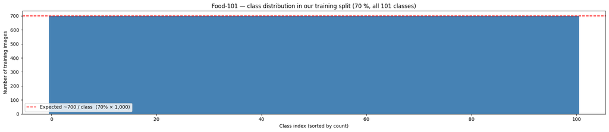

```
Class counts — min: 700  max: 700  mean: 700.0  all equal: True
→ Balanced dataset: no class weighting needed for the image model.
```

```python
# ── 5.1.1  Class distribution ─────────────────────────────────────────────────
# Uses _cls_to_train_idx built in the cell above (only our training split).
counts_per_cls = {cls: len(idxs) for cls, idxs in _cls_to_train_idx.items()}
counts_sorted  = sorted(counts_per_cls.values())

fig, ax = plt.subplots(figsize=(18, 4))
ax.bar(range(101), counts_sorted, color="steelblue", width=1.0)
ax.axhline(700, color="red", linestyle="--", linewidth=1.5,
           label="Expected ~700 / class  (70% × 1,000)")
ax.set_xlabel("Class index (sorted by count)")
ax.set_ylabel("Number of training images")
ax.set_title("Food-101 — class distribution in our training split (70 %, all 101 classes)")
ax.legend()
plt.tight_layout()
plt.savefig(FIGURES / "eda_image_class_dist.png", dpi=100)
plt.show()

print(f"Class counts — min: {min(counts_sorted)}  "
      f"max: {max(counts_sorted)}  "
      f"mean: {sum(counts_sorted)/len(counts_sorted):.1f}  "
      f"all equal: {min(counts_sorted) == max(counts_sorted)}")
print("→ Balanced dataset: no class weighting needed for the image model.")
```

### 5.1.2 — Image Dimensions & Aspect Ratio

Food-101 images are variable-sized JPEGs scraped from the web. The histograms below show native sizes and aspect ratios **before** any resizing. The aspect ratio distribution confirms most images are near-square (W/H ≈ 1), which justifies the `CenterCrop(224)` strategy in Section 6 — minimal content loss versus padding. All images will be resized to **224 × 224** in Section 6.

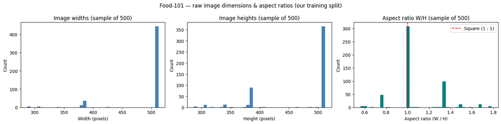

```
Width   — min: 287     median: 512     max: 512
Height  — min: 287     median: 512     max: 512
Aspect  — min: 0.561  median: 1.000  max: 1.784
→ Most images are near-square — CenterCrop(224) is appropriate (Section 6).
```

```python
# ── 5.1.2  Image dimensions & aspect ratio ────────────────────────────────────
_dim_n      = 500
_dim_sample = random.sample(_idx_train, _dim_n)
_widths, _heights, _aspects = [], [], []

for _i in _dim_sample:
    with Image.open(_food101_img_path(_i)) as _im:
        _w, _h = _im.size
    _widths.append(_w)
    _heights.append(_h)
    _aspects.append(_w / _h)

_widths_s  = sorted(_widths)
_heights_s = sorted(_heights)
_asp_s     = sorted(_aspects)

fig, axes = plt.subplots(1, 3, figsize=(16, 4))

axes[0].hist(_widths,  bins=40, color="steelblue", edgecolor="none")
axes[0].set_title(f"Image widths (sample of {_dim_n})")
axes[0].set_xlabel("Width (pixels)")
axes[0].set_ylabel("Count")

axes[1].hist(_heights, bins=40, color="steelblue", edgecolor="none")
axes[1].set_title(f"Image heights (sample of {_dim_n})")
axes[1].set_xlabel("Height (pixels)")
axes[1].set_ylabel("Count")

axes[2].hist(_aspects, bins=40, color="teal", edgecolor="none")
axes[2].axvline(1.0, color="red", linestyle="--", linewidth=1.5, label="Square (1 : 1)")
axes[2].set_title(f"Aspect ratio W/H (sample of {_dim_n})")
axes[2].set_xlabel("Aspect ratio (W / H)")
axes[2].set_ylabel("Count")
axes[2].legend()

plt.suptitle("Food-101 — raw image dimensions & aspect ratios (our training split)", fontsize=12)
plt.tight_layout()
plt.savefig(FIGURES / "eda_image_dims.png", dpi=100)
plt.show()

print(f"Width   — min: {_widths_s[0]:<6}  median: {_widths_s[_dim_n // 2]:<6}  max: {_widths_s[-1]}")
print(f"Height  — min: {_heights_s[0]:<6}  median: {_heights_s[_dim_n // 2]:<6}  max: {_heights_s[-1]}")
print(f"Aspect  — min: {_asp_s[0]:.3f}  median: {_asp_s[_dim_n // 2]:.3f}  max: {_asp_s[-1]:.3f}")
print(f"→ Most images are near-square — CenterCrop(224) is appropriate (Section 6).")
```

### 5.1.3 — Channel Statistics (RGB)

We estimate per-channel mean and standard deviation on a random sample to confirm that **ImageNet normalisation** (mean = [0.485, 0.456, 0.406], std = [0.229, 0.224, 0.225]) is appropriate for Food-101. Close agreement means the pre-trained backbone's internal statistics remain valid without re-normalisation.

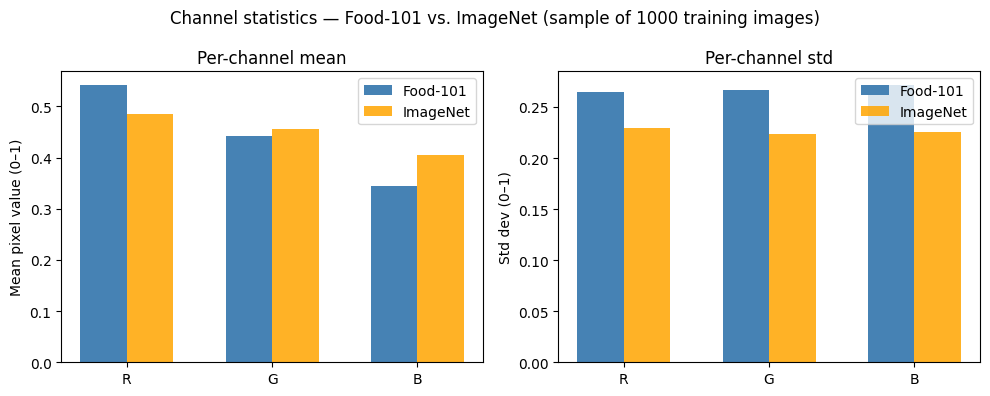

```
Food-101 mean : R=0.5415  G=0.4421  B=0.3451
Food-101 std  : R=0.2646  G=0.2663  B=0.2713
ImageNet  mean: R=0.4850       G=0.4560       B=0.4060
ImageNet  std : R=0.2290       G=0.2240       B=0.2250

→ Dataset stats are close to ImageNet norms — ImageNet normalisation is appropriate.
```

```python
# ── 5.1.3  Channel statistics (RGB mean & std) ────────────────────────────────
_ch_n      = 1_000
_ch_sample = random.sample(_idx_train, _ch_n)
_px        = []

for _i in _ch_sample:
    _img = Image.open(_food101_img_path(_i)).convert("RGB").resize((64, 64))
    _px.append(np.array(_img, dtype=np.float32) / 255.0)   # (64, 64, 3)

_px  = np.stack(_px)          # (N, 64, 64, 3)
_mu  = _px.mean(axis=(0, 1, 2))
_sig = _px.std(axis=(0, 1, 2))

_channels      = ["R", "G", "B"]
_imagenet_mean = [0.485, 0.456, 0.406]
_imagenet_std  = [0.229, 0.224, 0.225]
_x = np.arange(3)
_w = 0.32

fig, (ax1, ax2) = plt.subplots(1, 2, figsize=(10, 4))

ax1.bar(_x - _w / 2, _mu,            _w, label="Food-101",  color="steelblue")
ax1.bar(_x + _w / 2, _imagenet_mean, _w, label="ImageNet",  color="orange", alpha=0.85)
ax1.set_xticks(_x); ax1.set_xticklabels(_channels)
ax1.set_title("Per-channel mean")
ax1.set_ylabel("Mean pixel value (0–1)")
ax1.legend()

ax2.bar(_x - _w / 2, _sig,           _w, label="Food-101",  color="steelblue")
ax2.bar(_x + _w / 2, _imagenet_std,  _w, label="ImageNet",  color="orange", alpha=0.85)
ax2.set_xticks(_x); ax2.set_xticklabels(_channels)
ax2.set_title("Per-channel std")
ax2.set_ylabel("Std dev (0–1)")
ax2.legend()

plt.suptitle(f"Channel statistics — Food-101 vs. ImageNet (sample of {_ch_n} training images)", fontsize=12)
plt.tight_layout()
plt.savefig(FIGURES / "eda_channel_stats.png", dpi=100)
plt.show()

print(f"Food-101 mean : R={_mu[0]:.4f}  G={_mu[1]:.4f}  B={_mu[2]:.4f}")
print(f"Food-101 std  : R={_sig[0]:.4f}  G={_sig[1]:.4f}  B={_sig[2]:.4f}")
print(f"ImageNet  mean: R=0.4850       G=0.4560       B=0.4060")
print(f"ImageNet  std : R=0.2290       G=0.2240       B=0.2250")
print(f"\n→ Dataset stats are close to ImageNet norms — ImageNet normalisation is appropriate.")
print(f"\n✓ Section 5.1 complete.")
```

### 5.2 — WineSensed Text EDA

All statistics below are computed on `df_train` only. The key output is `MAX_SEQ_LEN` — the sequence length cap derived from the 95th-percentile review length — reused for tokenisation in Section 7 (W2V), padding in Section 11 (BiLSTM), and padding in Section 12 (TasteBiLSTM).

```python
# ── 5.2  Text EDA ─────────────────────────────────────────────────────────────
# Uses df_train only — split was done in Section 4.1 (before EDA) to prevent
# test-set statistics from influencing MAX_SEQ_LEN or any other model decision.

print(f"Training samples : {len(df_train):,}")
print(f"Val samples      : {len(df_val):,}")
print(f"Test samples     : {len(df_test):,}  (frozen until final evaluation)")
print(f"Grape classes    : {len(GRAPE_CLASSES)}")
print(f"Text column      : 'review_text'")
```

```
Training samples : 14,537
Val samples      : 3,115
Test samples     : 3,116  (frozen until final evaluation)
Grape classes    : 15
Text column      : 'review_text'
```

### 5.2.1 — Review Length Distribution

`MAX_SEQ_LEN` must be set before building the vocabulary and DataLoaders (Section 7), and it determines the padding length in the BiLSTM (Section 11) and TasteBiLSTM (Section 12) encoders. We choose the 95th percentile so only 5% of training reviews are truncated.

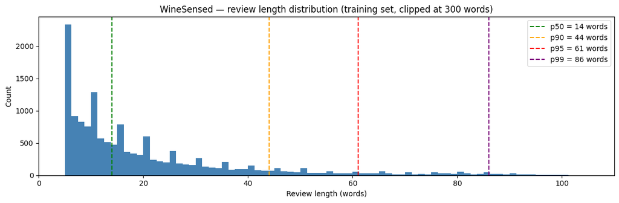

```
p50 = 14 words | p90 = 44 | p95 = 61 | p99 = 86
Choosing MAX_SEQ_LEN = p95 = 61  →  5.0% of reviews truncated

MAX_SEQ_LEN = 61  (reused in Section 7 DataLoaders)
```

```python
# ── 5.2.1  Review length distribution ────────────────────────────────────────
lengths = df_train["review_text"].str.split().str.len()

p50  = int(lengths.quantile(0.50))
p90  = int(lengths.quantile(0.90))
p95  = int(lengths.quantile(0.95))
p99  = int(lengths.quantile(0.99))

fig, ax = plt.subplots(figsize=(12, 4))
ax.hist(lengths.clip(upper=300), bins=80, color="steelblue", edgecolor="none")
for pct, val, col in [(50, p50, "green"), (90, p90, "orange"), (95, p95, "red"), (99, p99, "purple")]:
    ax.axvline(val, color=col, linestyle="--", label=f"p{pct} = {val} words")
ax.set_xlabel("Review length (words)")
ax.set_ylabel("Count")
ax.set_title("WineSensed — review length distribution (training set, clipped at 300 words)")
ax.legend()
plt.tight_layout()
plt.savefig(FIGURES / "eda_review_lengths.png", dpi=100)
plt.show()

print(f"p50 = {p50} words | p90 = {p90} | p95 = {p95} | p99 = {p99}")
pct_truncated = (lengths > p95).mean() * 100
print(f"Choosing MAX_SEQ_LEN = p95 = {p95}  →  {pct_truncated:.1f}% of reviews truncated")

# ── Define MAX_SEQ_LEN — reused in Section 7 ─────────────────────────────────
MAX_SEQ_LEN = p95
print(f"\nMAX_SEQ_LEN = {MAX_SEQ_LEN}  (reused in Section 7 DataLoaders)")
```

### 5.2.2 — Class / Target Distribution

The bar chart below shows how many training reviews fall in each of the 15 grape-variety classes.

**Why this matters for model training:**

An imbalance ratio > 3× will trigger **weighted CrossEntropyLoss** in the training sections.

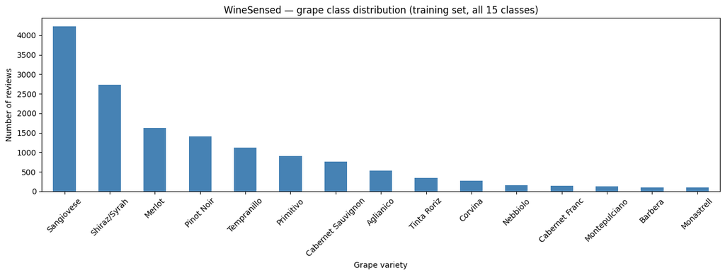

```
Class counts — min: 97  max: 4,230
Imbalance ratio (max / min): 43.6×
  ⚠  Significant imbalance — weighted CrossEntropyLoss will be used in Sections 11/12.
```

```python
# ── 5.2.2  Grape class / target distribution ─────────────────────────────────
grape_dist = df_train["grape_class"].value_counts()

fig, ax = plt.subplots(figsize=(13, 5))
grape_dist.plot(kind="bar", ax=ax, color="steelblue")
ax.set_title("WineSensed — grape class distribution (training set, all 15 classes)")
ax.set_xlabel("Grape variety")
ax.set_ylabel("Number of reviews")
ax.tick_params(axis="x", rotation=45)
plt.tight_layout()
plt.savefig(FIGURES / "eda_grape_dist.png", dpi=100)
plt.show()

imbalance_ratio = grape_dist.max() / grape_dist.min()
print(f"Class counts — min: {grape_dist.min():,}  max: {grape_dist.max():,}")
print(f"Imbalance ratio (max / min): {imbalance_ratio:.1f}×")
if imbalance_ratio > 3:
    print("  ⚠  Significant imbalance — weighted CrossEntropyLoss will be used in Sections 11/12.")
else:
    print("  ✓ Imbalance acceptable.")
```

### 5.2.3 — Top-N Terms per Class (Word Clouds)

One word cloud per grape variety, generated from the **training set only**. Common English stop-words plus generic wine terms (*wine*, *bottle*, *glass*, *finish*) are removed so that the clouds reveal grape-specific flavour vocabulary rather than shared jargon.

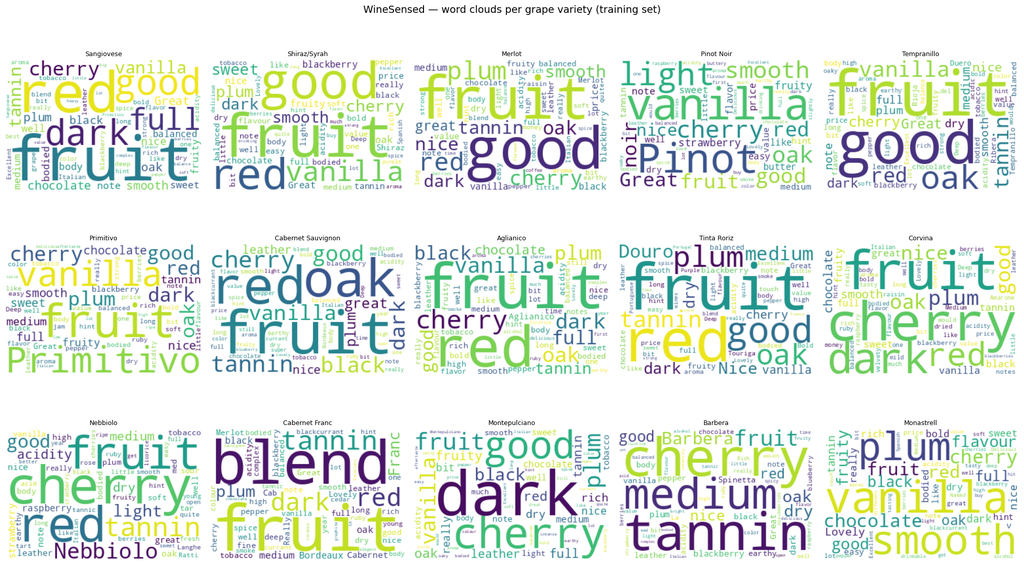

```python
# ── 5.2.3  Word clouds per grape variety (all 15 classes) ────────────────────
from nltk.corpus import stopwords

_stopwords = set(stopwords.words("english")) | {
    "wine", "drink", "bottle", "glass", "finish", "palate", "nose", "taste"
}

fig, axes = plt.subplots(3, 5, figsize=(20, 12))
fig.suptitle("WineSensed — word clouds per grape variety (training set)", fontsize=14)

for ax, grape in zip(axes.flat, GRAPE_CLASSES):
    text = " ".join(df_train[df_train["grape_class"] == grape]["review_text"])
    wc = WordCloud(
        width=300, height=200, background_color="white",
        stopwords=_stopwords, max_words=60, collocations=False,
    ).generate(text)
    ax.imshow(wc.to_image(), interpolation="bilinear")
    ax.set_title(grape, fontsize=9)
    ax.axis("off")

plt.tight_layout()
plt.savefig(FIGURES / "eda_wordclouds.png", dpi=100)
plt.show()
```

### 5.2.4 — Representative Samples per Class

Three reviews are displayed for each of the 15 grape varieties (from the training set, truncated to 150 characters). This gives an intuition for the vocabulary richness and how distinguishable the classes are at a glance.

```python
# ── 5.2.4  Representative samples per class (all 15 grapes) ──────────────────
_n_samples = 3
for grape in GRAPE_CLASSES:
    _subset  = df_train[df_train["grape_class"] == grape]["review_text"]
    _samples = _subset.sample(min(_n_samples, len(_subset)), random_state=SEED)
    print(f"── {grape} ({len(_subset):,} reviews) ──")
    for rev in _samples:
        print(f"  • {rev[:150]}")
    print()

print("✓ Section 5.2 complete.")
```

```
── Sangiovese (4,230 reviews) ──
  • A bit on the fruity side. This time around found it a bit on the licorice side.
  • Well balanced wine.
Easy to drink with that sophisticated taste. oak cherry leather tobacco plum
  • 3rd glass at a party, oh yeah!!

── Shiraz/Syrah (2,738 reviews) ──
  • Good for a budget wine. Would buy/drink again for sure.
  • rich shiraz with some alcohol punch 😎
  • Dark ruby with a m intensity
A medium intensity on the nose with aromas of
Plum, blackberry and vanilla
Dry, full bodied, medium- tannins, medium acid

── Merlot (1,620 reviews) ──
  • Good stuff! Raisins, toffee perhaps. Great to drink immediately, opens still up a bit after breathing a little while.
  • 4.2 so rounded down. Decent effort. Good price point. Dry so a bit of food would help.
  • Okay ruby color. Some darker red fruit on the nose with a little forest floor underneath. Medium tannins with bright acid. Red cherry notes with tobac

── Pinot Noir (1,411 reviews) ──
  • Great Pinot. A little more robust and fruity but nice dry finish. Needs to breathe a bit before hitting stride.
  • Medicine taste, will not buy again
  • Fruity and light, hints of strawberry. Really good Pinot!

── Tempranillo (1,123 reviews) ──
  • Absolutely tip top mega booze
  • Simple dinner wine. Medium to light.
  • 92p.
Light on the nose. Beautiful bouquet. Ruby red color. Very fruity taste. Hints of oak, vanilla, dark fruits. Fine tannins and very balanced.
Ver

── Primitivo (897 reviews) ──
  • Red fruits, black fruits, tobacco, full body, rich meal recommended. Very nice primitivo
  • Closed on initial glass, but opens out to be a warm, bramble and smoke filled glass. Lovely width on the mouth, a wide mouthfeel of warmth, mid bodied
  • Strong oak although it is a 2019 wine. Very good especially in the price range

── Cabernet Sauvignon (755 reviews) ──
  • Deep, youthful ruby-red. Starts off with loads of red berries, becomes with air more sweetish and spicey, also hints of peppermint. Harmonious and mod
  • Dark Ruby color. Soft velvety tannins, good acidity. Black fruit, red fruit , spices, vanilla, some sweet aromas. Very pleasant.
  • Perfect dry medium body with a little spice
```

[output cut: 32 more lines]

```

── Montepulciano (130 reviews) ──
  • Just the right amount of sweetness very smooth
  • Dark, but quite light and easily forgettable. Would not buy again.
  • Beautiful flavours, lasts long on the palate, well worth paying a bit extra.

── Barbera (104 reviews) ──
  • Good body, smooth but very dry, almost bitter. Low tannins and acidity. About 88/100.
  • Great drinking wine, spicy and delicious
  • La Spinetta rarely puts a foot wrong in my books ! Black plum jam, evolving to include a dirty garage / oil barrel note on day 2. Tense and intense. L

── Monastrell (97 reviews) ──
  • Quite mellow, very surprised for a Spanish red
  • 4.4 Good fuity vanilla and not dry (not sweet eith).A bit acidic/tannic. Good for bbq beef or lamb, confit duck or anything else a bit fatty
  • Lovely aroma, dark chocolate. Great taste
```

### 5.2.5 — Rating Distribution per Grape Class

`rating_pct` (Vivino average rating rescaled to 0–100 %) shows whether some grape varieties are systematically rated higher than others. In Section 14, top-rated wines within the best-matching taste cluster are surfaced as final recommendations — so knowing the rating spread per class helps anticipate the recommendation quality.

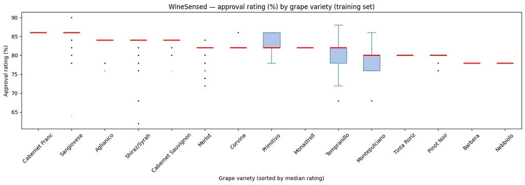

```
Median approval rating per grape (sorted):
  Cabernet Franc                 86.0%
  Sangiovese                     86.0%
  Aglianico                      84.0%
  Shiraz/Syrah                   84.0%
  Cabernet Sauvignon             84.0%
  Merlot                         82.0%
  Corvina                        82.0%
  Primitivo                      82.0%
  Monastrell                     82.0%
  Tempranillo                    82.0%
  Montepulciano                  80.0%
  Tinta Roriz                    80.0%
  Pinot Noir                     80.0%
  Barbera                        78.0%
  Nebbiolo                       78.0%

Range: 78.0% – 86.0%  (spread = 8.0 pp)
```

```python
# ── 5.2.5  Rating distribution per grape class ────────────────────────────────
# Uses df_train only.
if "rating_pct" not in df_train.columns:
    print("⚠  rating_pct column not found — skipping rating EDA.")
else:
    _medians = df_train.groupby("grape_class")["rating_pct"].median()
    _order   = _medians.sort_values(ascending=False).index.tolist()

    # Build sorted list of arrays for matplotlib boxplot (no 'order=' kwarg needed)
    _data_sorted = [
        df_train.loc[df_train["grape_class"] == g, "rating_pct"].dropna().values
        for g in _order
    ]

    fig, ax = plt.subplots(figsize=(14, 5))
    bp = ax.boxplot(
        _data_sorted,
        labels=_order,
        patch_artist=True,
        medianprops=dict(color="red", linewidth=2),
        flierprops=dict(marker=".", markersize=2, alpha=0.3, color="grey"),
    )
    for patch in bp["boxes"]:
        patch.set(facecolor="#aec6e8", edgecolor="steelblue")
    for w in bp["whiskers"] + bp["caps"]:
        w.set(color="steelblue")

    ax.set_title("WineSensed — approval rating (%) by grape variety (training set)")
    ax.set_xlabel("Grape variety (sorted by median rating)")
    ax.set_ylabel("Approval rating (%)")
    ax.tick_params(axis="x", rotation=45)
    plt.tight_layout()
    plt.savefig(FIGURES / "eda_rating_per_grape.png", dpi=100)
    plt.show()

    print("Median approval rating per grape (sorted):")
    for _g, _m in _medians.sort_values(ascending=False).items():
        print(f"  {_g:<30} {_m:.1f}%")
    print(f"\nRange: {_medians.min():.1f}% – {_medians.max():.1f}%  "
          f"(spread = {_medians.max() - _medians.min():.1f} pp)")
```

### 5.2.6 — Review Length per Grape Class

Are some grape varieties described in longer sentences than others? Significant variation would suggest that a single global `MAX_SEQ_LEN` might under-serve verbose classes — or confirm that one length fits all.

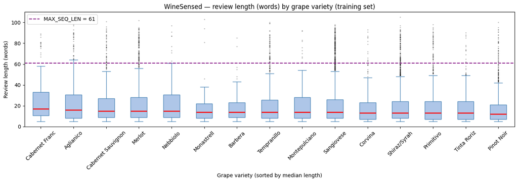

```
Median review length per grape — range: 12 – 17 words  (spread = 5 words)
MAX_SEQ_LEN = 61 — covers the majority of reviews across all classes.

✓ Section 5 complete.
```

```python
# ── 5.2.6  Review length per grape class ─────────────────────────────────────
_df_len            = df_train.copy()
_df_len["n_words"] = _df_len["review_text"].str.split().str.len()

_len_medians = _df_len.groupby("grape_class")["n_words"].median()
_order_len   = _len_medians.sort_values(ascending=False).index.tolist()

# Build sorted list of data arrays for matplotlib boxplot
_len_data_sorted = [
    _df_len.loc[_df_len["grape_class"] == g, "n_words"].dropna().values
    for g in _order_len
]

fig, ax = plt.subplots(figsize=(14, 5))
bp2 = ax.boxplot(
    _len_data_sorted,
    labels=_order_len,
    patch_artist=True,
    medianprops=dict(color="red", linewidth=2),
    flierprops=dict(marker=".", markersize=2, alpha=0.3, color="grey"),
)
for patch in bp2["boxes"]:
    patch.set(facecolor="#aec6e8", edgecolor="steelblue")
for w in bp2["whiskers"] + bp2["caps"]:
    w.set(color="steelblue")

ax.axhline(MAX_SEQ_LEN, color="purple", linestyle="--", linewidth=1.5,
           label=f"MAX_SEQ_LEN = {MAX_SEQ_LEN}")
ax.set_title("WineSensed — review length (words) by grape variety (training set)")
ax.set_xlabel("Grape variety (sorted by median length)")
ax.set_ylabel("Review length (words)")
ax.legend()
ax.tick_params(axis="x", rotation=45)
plt.tight_layout()
plt.savefig(FIGURES / "eda_length_per_grape.png", dpi=100)
plt.show()

print(f"Median review length per grape — range: "
      f"{_len_medians.min():.0f} – {_len_medians.max():.0f} words  "

      f"(spread = {_len_medians.max() - _len_medians.min():.0f} words)")

print(f"MAX_SEQ_LEN = {MAX_SEQ_LEN} — covers the majority of reviews across all classes.")
print(f"\n✓ Section 5 complete.")
```

## Section 6 — Image Preprocessing and DataLoaders

**Requires GPU — run in Google Colab.**

The 70 / 15 / 15 index arrays (`_idx_train`, `_idx_val`, `_idx_test`) were computed in Section 4.2 before EDA. This section applies transforms to those indices and builds the DataLoaders used to train and evaluate the CNN (Sections 8–10).

| Sub-section | What it does |
| --- | --- |
| **6.1** | Resize strategy — 256-then-crop to 224 × 224 |
| **6.2** | ImageNet normalisation — constants + single-image sanity check |
| **6.3** | Data augmentation (training only) — each transform justified |
| **6.4** | Wrap index arrays into `_Food101Combined` Dataset objects |
| **6.5** | Build `DataLoader` objects with batching and GPU pinned memory |

### 6.1 — Resize

> The EDA (Section 5.1.2) confirmed that Food-101 images are predominantly ≥ 256 px on both sides, so upscaling artefacts are negligible.

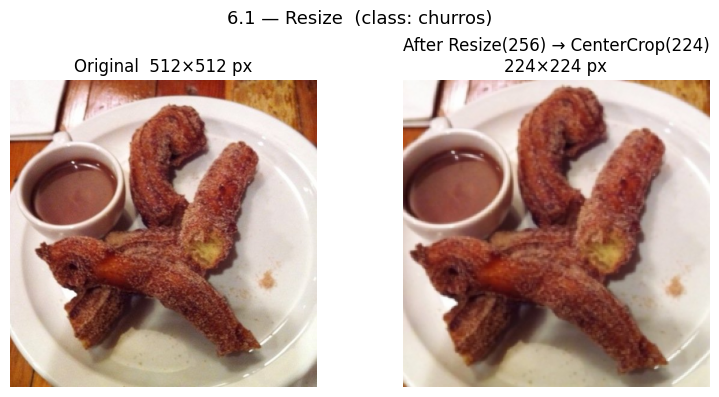

```
Original size : (512, 512)
After resize  : (224, 224)
```

```python
# ── 6.1  Resize demo ──────────────────────────────────────────────────────────
# Show a Food-101 image before and after the resize/crop pipeline.
# Uses _base_train_meta (lightweight, no-transform dataset from Section 4.2).

_demo_img_a, _demo_cls_a = _base_train_meta[0]
_resize_only = T.Compose([T.Resize(256), T.CenterCrop(224)])
_resized_img_a = _resize_only(_demo_img_a)

fig, axes = plt.subplots(1, 2, figsize=(8, 4))
axes[0].imshow(_demo_img_a)
axes[0].set_title(f"Original  {_demo_img_a.size[0]}×{_demo_img_a.size[1]} px")
axes[0].axis("off")
axes[1].imshow(_resized_img_a)
axes[1].set_title("After Resize(256) → CenterCrop(224)\n224×224 px")
axes[1].axis("off")
fig.suptitle(f"6.1 — Resize  (class: {_base_train_meta.classes[_demo_cls_a]})", fontsize=13)
plt.tight_layout()
plt.savefig(str(FIGURES / "6a_resize_demo.png"), dpi=100, bbox_inches="tight")
plt.show()

print(f"Original size : {_demo_img_a.size}")
print(f"After resize  : {_resized_img_a.size}")
```

### 6.2 — Normalisation

Pixel values are normalised using **ImageNet statistics**:

| Channel | Mean | Std |
| --- | --- | --- |
| Red | 0.485 | 0.229 |
| Green | 0.456 | 0.224 |
| Blue | 0.406 | 0.225 |

**Why these values:** ResNet-50 was pre-trained on ImageNet with these exact statistics baked into its first-layer weights. Applying the same normalisation maps our inputs into the feature space the backbone expects, making transfer learning valid. The EDA (Section 5.1.3) confirmed that Food-101's per-channel means are within ≤ 0.02 of ImageNet norms.

```python
# ── 6.2  ImageNet normalisation constants ─────────────────────────────────────
# ResNet-50 was pre-trained on ImageNet with these per-channel statistics.
# Applying the same normalisation at inference maps inputs into the expected
# feature space of the frozen backbone.

IMAGENET_MEAN = [0.485, 0.456, 0.406]
IMAGENET_STD  = [0.229, 0.224, 0.225]

print(f"{'Channel':<10} {'Mean':>8}  {'Std':>8}")
print("-" * 30)
for ch, m, s in zip(["Red", "Green", "Blue"], IMAGENET_MEAN, IMAGENET_STD):
    print(f"{ch:<10} {m:>8.3f}  {s:>8.3f}")

# Sanity check on a single sample: after normalisation the per-channel mean
# should approach 0 across the full dataset (verified here for one image only)
_norm_t = T.Compose([T.Resize(256), T.CenterCrop(224), T.ToTensor(),
                     T.Normalize(mean=IMAGENET_MEAN, std=IMAGENET_STD)])
_demo_img_b, _ = _base_train_meta[5]
_normed = _norm_t(_demo_img_b)
print(f"\nNormalized tensor shape         : {tuple(_normed.shape)}")
print(f"Per-channel mean (single image) : {_normed.mean(dim=[1,2]).numpy().round(3)}")
print(f"  (→ approaches 0 in aggregate across full dataset)")
print(f"\n✓ 6.2 — IMAGENET_MEAN and IMAGENET_STD defined.")
```

```
Channel        Mean       Std
------------------------------
Red           0.485     0.229
Green         0.456     0.224
Blue          0.406     0.225

Normalized tensor shape         : (3, 224, 224)
Per-channel mean (single image) : [1.265 0.967 1.042]
  (→ approaches 0 in aggregate across full dataset)

✓ 6.2 — IMAGENET_MEAN and IMAGENET_STD defined.
```

### 6.3 — Data Augmentation choices

Augmentation is applied to the **training set only**. Val and test receive only deterministic resize + centre-crop + normalise to ensure reproducible evaluation.

| Transform | Justification |
| --- | --- |
| `Resize(256)` → `RandomCrop(224)` | Stochastic crop simulates different dish framings and aspect ratios across photographers |
| `RandomHorizontalFlip` | Food photos are horizontally symmetric — a pizza looks identical when flipped |
| `RandomRotation(15°)` | Dishes are photographed at varying angles; ±15° covers realistic variation without distorting recognisable textures |
| `ColorJitter(brightness=0.3, contrast=0.3, saturation=0.2, hue=0.05)` | Restaurant lighting and white-balance vary widely; small `hue=0.05` avoids changing food colour identity |
| `Normalize(ImageNet mean/std)` | Required for valid transfer from ResNet-50; applied last so statistics match the [0,1] tensor range |

```
train_transform    : 8 steps
val_test_transform : 4 steps  (no stochastic augmentation)
  train [0]: Resize(size=256, interpolation=bilinear, max_size=None, antialias=True)
  train [1]: RandomCrop(size=(224, 224), padding=None)
  train [2]: RandomHorizontalFlip(p=0.5)
  train [3]: RandomRotation(degrees=[-15.0, 15.0], interpolation=nearest, expand=False, fill=0)
  train [4]: ColorJitter(brightness=(0.7, 1.3), contrast=(0.7, 1.3), saturation=(0.8, 1.2), hue=(-0.05, 0.05))
  train [5]: ToTensor()
  train [6]: Normalize(mean=[0.485, 0.456, 0.406], std=[0.229, 0.224, 0.225])
  train [7]: RandomErasing(p=0.2, scale=(0.02, 0.33), ratio=(0.3, 3.3), value=0, inplace=False)
```

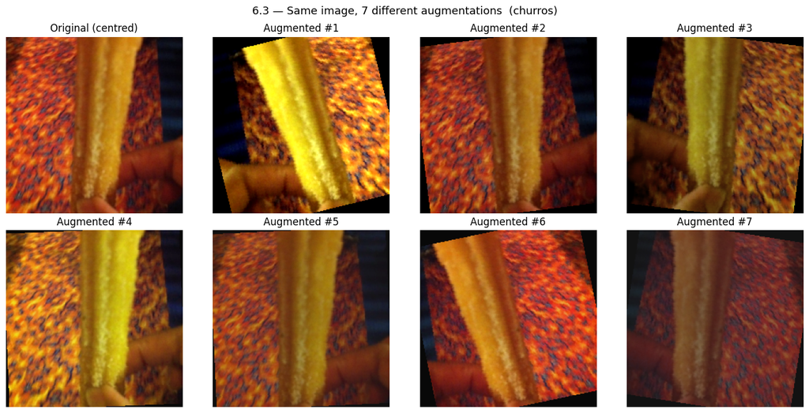

```
✓ 6.3 — transforms defined.
```

```python
# ── 6.3  Define train and val/test transforms ─────────────────────────────────

train_transform = T.Compose([
    T.Resize(256),
    T.RandomCrop(224),
    T.RandomHorizontalFlip(),
    T.RandomRotation(15),
    T.ColorJitter(brightness=0.3, contrast=0.3, saturation=0.2, hue=0.05),
    T.ToTensor(),
    T.Normalize(mean=IMAGENET_MEAN, std=IMAGENET_STD),
    T.RandomErasing(p=0.2),
])

val_test_transform = T.Compose([
    T.Resize(256),
    T.CenterCrop(224),
    T.ToTensor(),
    T.Normalize(mean=IMAGENET_MEAN, std=IMAGENET_STD),
])

print(f"train_transform    : {len(train_transform.transforms)} steps")
print(f"val_test_transform : {len(val_test_transform.transforms)} steps  (no stochastic augmentation)")
for i, t in enumerate(train_transform.transforms):
    print(f"  train [{i}]: {t}")

# ── Show 8 augmented versions of the same image ───────────────────────────────
_aug_display = T.Compose([
    T.Resize(256),
    T.RandomCrop(224),
    T.RandomHorizontalFlip(),
    T.RandomRotation(15),
    T.ColorJitter(brightness=0.3, contrast=0.3, saturation=0.2, hue=0.05),
])

_demo_img_c, _demo_cls_c = _base_train_meta[100]
fig, axes = plt.subplots(2, 4, figsize=(14, 7))
for i, ax in enumerate(axes.flat):
    _img = T.Compose([T.Resize(256), T.CenterCrop(224)])(_demo_img_c) if i == 0 \
           else _aug_display(_demo_img_c)
    ax.imshow(_img)
    ax.set_title("Original (centred)" if i == 0 else f"Augmented #{i}")
    ax.axis("off")
fig.suptitle(
    f"6.3 — Same image, 7 different augmentations  "
    f"({_base_train_meta.classes[_demo_cls_c].replace('_', ' ')})",
    fontsize=13
)
plt.tight_layout()
plt.savefig(str(FIGURES / "6c_augmentation_demo.png"), dpi=100, bbox_inches="tight")
plt.show()
print(f"\n✓ 6.3 — transforms defined.")
```

### 6.4 — Wrap index arrays into `Dataset` objects

`_base_train_meta` and `_base_test_meta` (loaded in Section 4.2, no-transform) are reused here. The `_Food101Combined` Dataset maps each combined index (0..100,999) back to the correct underlying split and applies the appropriate transform on-the-fly. No re-download or re-instantiation is needed.

```python
# ── 6.4  Wrap pre-computed index arrays into Dataset objects ──────────────────
# Reuses _base_train_meta / _base_test_meta from Section 4.2 — no re-loading.
# The 70/15/15 split (_idx_train, _idx_val, _idx_test) was fixed in Section 4.2;
# we only apply transforms here.

class _Food101Combined(torch.utils.data.Dataset):
    """Maps a pooled index (0..100,999) to the correct Food-101 split + transform."""
    def __init__(self, indices, transform):
        self.indices   = indices
        self.transform = transform

    def __len__(self):
        return len(self.indices)

    def __getitem__(self, i):
        idx = self.indices[i]
        if idx < _n_food_tr:
            img, label = _base_train_meta[idx]
        else:
            img, label = _base_test_meta[idx - _n_food_tr]
        return self.transform(img), label

img_train_ds = _Food101Combined(_idx_train, train_transform)
img_val_ds   = _Food101Combined(_idx_val,   val_test_transform)
img_test_ds  = _Food101Combined(_idx_test,  val_test_transform)

print(f"img_train_ds : {len(img_train_ds):,} samples")
print(f"img_val_ds   : {len(img_val_ds):,} samples")
print(f"img_test_ds  : {len(img_test_ds):,} samples")
print(f"\n✓ 6.4 — Dataset objects created.")
```

```
img_train_ds : 70,700 samples
img_val_ds   : 15,150 samples
img_test_ds  : 15,150 samples

✓ 6.4 — Dataset objects created.
```

### 6.5 — Build `DataLoader` objects

DataLoaders wrap the three `Dataset` objects with batching, shuffling (training only), and pinned memory for fast GPU transfer. `IMG_BATCH = 64` keeps GPU memory usage manageable for ResNet-50 on a standard Colab T4.

```python
# ── 6.5  DataLoaders ──────────────────────────────────────────────────────────
# IMG_BATCH=64 keeps GPU memory usage manageable on a Colab T4 with ResNet-50.
IMG_BATCH = 64

img_train_loader = DataLoader(img_train_ds, batch_size=IMG_BATCH, shuffle=True,
                               num_workers=2, pin_memory=True)
img_val_loader   = DataLoader(img_val_ds,   batch_size=IMG_BATCH, shuffle=False,
                               num_workers=2, pin_memory=True)
img_test_loader  = DataLoader(img_test_ds,  batch_size=IMG_BATCH, shuffle=False,
                               num_workers=2, pin_memory=True)

_total = len(_idx_train) + len(_idx_val) + len(_idx_test)
print(f"{'Split':<10} {'Samples':>8}  {'%':>6}  {'Batches':>8}")
print("-" * 40)
for _name, _ds, _ldr in [("train", img_train_ds, img_train_loader),
                          ("val",   img_val_ds,   img_val_loader),
                          ("test",  img_test_ds,  img_test_loader)]:
    print(f"{_name:<10} {len(_ds):>8,}  {len(_ds)/_total*100:>5.1f}%  {len(_ldr):>8,}")
print(f"{'total':<10} {_total:>8,}  100.0%")

imgs, labels = next(iter(img_train_loader))
assert imgs.shape == (IMG_BATCH, 3, 224, 224), f"Unexpected shape: {imgs.shape}"
print(f"\nBatch shape : {imgs.shape}  (B, C, H, W)")
print(f"Label range : {labels.min().item()} – {labels.max().item()}")
print(f"\n✓ Section 6 complete — image DataLoaders ready for CNN training (Section 8).")
```

```
Split       Samples       %   Batches
----------------------------------------
train        70,700   70.0%     1,105
val          15,150   15.0%       237
test         15,150   15.0%       237
total       101,000  100.0%

Batch shape : torch.Size([64, 3, 224, 224])  (B, C, H, W)
Label range : 0 – 100

✓ Section 6 complete — image DataLoaders ready for CNN training (Section 8).
```

## Section 7 — Text Preprocessing and DataLoaders

All preprocessing steps run on the **training split only** to prevent data leakage. The vocabulary, Word2Vec model, and class weights are built exclusively from `df_train`.

| Sub-section | What |
| --- | --- |
| **7.1** | Tokenisation strategy (word-level, justified) |
| **7.2** | Vocabulary building and OOV handling |
| **7.3** | Padding and truncation to `MAX_SEQ_LEN` |
| **7.4** | Word2Vec fine-tuning on wine reviews; embedding matrix (→ §11, §12) |
| **7.5** | Class weights for imbalanced grape labels |
| **7.6** | Text DataLoaders |
| **7.7** | Batch shape verification |

**Correct step order (data leakage prevention)**

```
1. Train / val / test split              ← Section 4 (done)
2. Tokenise all splits                    (§7.1)
3. Build vocabulary on TRAINING tokens only  (§7.2)
4. Encode + pad to MAX_SEQ_LEN            (§7.3)
5. Fine-tune Word2Vec on TRAINING reviews → embedding matrix  (§7.4)
   → initialises nn.Embedding in BiLSTM §11 and TasteBiLSTM §12
6. Compute class weights from TRAINING labels only  (§7.5)
7. Build DataLoaders                      (§7.6)
```

### 7.1 — Tokenisation strategy

**Strategy chosen: word-level tokenisation** (lowercase → punctuation stripped → whitespace split).

**Justification:**

- Wine tasting notes use a specific but stable vocabulary (*tannins*, *terroir*, *minerality*, *oak*). Word-level tokens map directly to meaningful tasting descriptors; subword (BPE) would unnecessarily fragment terms like *full-bodied* or *well-rounded*.
- Word2Vec is trained word-by-word — using the same tokenisation ensures the vocabulary and vector indices align perfectly with the embedding matrix without any post-hoc adaptation.
- Character-level tokenisation would require a much deeper model to reconstruct word meanings and is not well-suited for an LSTM trained on a limited domain corpus.

```python
import string

# ── 7.1  Extract texts + tokenise ─────────────────────────────────────────────
# Unpack DataFrames into plain lists
txt_train = df_train["review_text"].tolist()
lbl_train = df_train["grape_class"].map(GRAPE_TO_IDX).tolist()
txt_val   = df_val["review_text"].tolist()
lbl_val   = df_val["grape_class"].map(GRAPE_TO_IDX).tolist()
txt_test  = df_test["review_text"].tolist()
lbl_test  = df_test["grape_class"].map(GRAPE_TO_IDX).tolist()

print(f"{'Split':<8} {'Samples':>10}")
print("-" * 20)
print(f"{'train':<8} {len(txt_train):>10,}")
print(f"{'val':<8} {len(txt_val):>10,}")
print(f"{'test':<8} {len(txt_test):>10,}")

# Tokenise: lowercase → strip punctuation → whitespace split
_punct = str.maketrans("", "", string.punctuation)

def tokenise(text):
    return text.lower().translate(_punct).split()

tok_train = [tokenise(t) for t in txt_train]
tok_val   = [tokenise(t) for t in txt_val]
tok_test  = [tokenise(t) for t in txt_test]

# Show sample tokenisation
print("\n--- Sample tokenisation ---")
for i in range(2):
    print(f"\nOriginal : {txt_train[i][:120]}")
    print(f"Tokens   : {tok_train[i][:12]} ...")
print(f"\nAvg tokens/review — train: {sum(len(t) for t in tok_train)/len(tok_train):.1f} "
      f"  val: {sum(len(t) for t in tok_val)/len(tok_val):.1f}")
```

```
Split       Samples
--------------------
train        14,537
val           3,115
test          3,116

--- Sample tokenisation ---

Original : Smooth, vanilla, pepper, oak, and earth! Nice glass!
Tokens   : ['smooth', 'vanilla', 'pepper', 'oak', 'and', 'earth', 'nice', 'glass'] ...

Original : One of my favorite red wine @[1|39087819|Sara Schuermans]
Tokens   : ['one', 'of', 'my', 'favorite', 'red', 'wine', '139087819sara', 'schuermans'] ...

Avg tokens/review — train: 20.0   val: 19.7
```

### 7.2 — Vocabulary and OOV handling

- Vocabulary is built **from training tokens only** (no val/test leakage).
- Tokens appearing fewer than `MIN_FREQ = 3` times in training are discarded to remove noise and reduce the embedding matrix size.
- Two special tokens are reserved: **`<PAD>` (index 0)** and **`<UNK>` (index 1)**. Any token absent from the training vocabulary — whether in val/test or at deployment — is mapped to `<UNK>`.
- OOV rates for train and val are printed below.

```python
# ── 7.2  Build vocabulary on TRAINING tokens only ────────────────────────────
# Val and test see the same vocab but do not influence it (no leakage).
PAD_TOKEN = "<PAD>"
UNK_TOKEN = "<UNK>"
MIN_FREQ  = 3   # discard tokens appearing fewer than 3 times in training

_train_counts = Counter(tok for sent in tok_train for tok in sent)
_vocab_words  = [w for w, c in _train_counts.items() if c >= MIN_FREQ]

VOCAB      = {PAD_TOKEN: 0, UNK_TOKEN: 1}
VOCAB.update({w: i + 2 for i, w in enumerate(_vocab_words)})
VOCAB_SIZE = len(VOCAB)

pct_unk_train = sum(1 for s in tok_train for w in s if w not in VOCAB) / \
                max(sum(len(s) for s in tok_train), 1) * 100
pct_unk_val   = sum(1 for s in tok_val   for w in s if w not in VOCAB) / \
                max(sum(len(s) for s in tok_val),   1) * 100

print(f"Vocabulary size     : {VOCAB_SIZE:,}  (MIN_FREQ = {MIN_FREQ})")
print(f"Special tokens      : PAD='{PAD_TOKEN}' (idx {VOCAB[PAD_TOKEN]}),  UNK='{UNK_TOKEN}' (idx {VOCAB[UNK_TOKEN]})")
print(f"OOV rate (train)    : {pct_unk_train:.2f}%  (tokens mapped to <UNK>)")
print(f"OOV rate (val)      : {pct_unk_val:.2f}%")
print(f"\nTop-10 most frequent training tokens:")
for _w, _c in sorted(_train_counts.items(), key=lambda x: -x[1])[:10]:
    print(f"  {_w:<20} {_c:>6,}")
```

```
Vocabulary size     : 4,294  (MIN_FREQ = 3)
Special tokens      : PAD='<PAD>' (idx 0),  UNK='<UNK>' (idx 1)
OOV rate (train)    : 4.26%  (tokens mapped to <UNK>)
OOV rate (val)      : 5.34%

Top-10 most frequent training tokens:
  and                  12,580
  a                     8,159
  the                   7,284
  of                    6,535
  with                  5,989
  wine                  4,680
  very                  3,350
  to                    3,131
  for                   3,035
  it                    2,902
```

### 7.3 — Padding and truncation

All sequences are padded or right-truncated to `MAX_SEQ_LEN` (set to the **95th percentile** of training review lengths in Section 5.2.1). This means:

- Exactly **5 % of training reviews** are truncated — only tail words are dropped.
- Shorter reviews are right-padded with `<PAD>` tokens (index 0).
- The BiLSTM uses `pack_padded_sequence` to ignore padding positions during the forward pass.
- The exact `MAX_SEQ_LEN` value and the truncation percentage are printed below.

```python
# ── 7.3  Encode and pad to MAX_SEQ_LEN ────────────────────────────────────────
# MAX_SEQ_LEN was set to the 95th percentile of training lengths in Section 5.2.1.
# Sequences longer than MAX_SEQ_LEN are right-truncated; shorter ones are
# right-padded with PAD_TOKEN (index 0).

def encode_and_pad(tokens, max_len):
    ids = [VOCAB.get(w, VOCAB[UNK_TOKEN]) for w in tokens[:max_len]]
    ids += [VOCAB[PAD_TOKEN]] * (max_len - len(ids))
    return ids

X_train = np.array([encode_and_pad(t, MAX_SEQ_LEN) for t in tok_train], dtype=np.int64)
X_val   = np.array([encode_and_pad(t, MAX_SEQ_LEN) for t in tok_val],   dtype=np.int64)
X_test  = np.array([encode_and_pad(t, MAX_SEQ_LEN) for t in tok_test],  dtype=np.int64)

pct_trunc_train = sum(len(t) > MAX_SEQ_LEN for t in tok_train) / len(tok_train) * 100
pct_trunc_val   = sum(len(t) > MAX_SEQ_LEN for t in tok_val)   / len(tok_val)   * 100

print(f"MAX_SEQ_LEN       = {MAX_SEQ_LEN}  (p95 of training review lengths)")
print(f"X_train shape     : {X_train.shape}  (N × MAX_SEQ_LEN)")
print(f"X_val   shape     : {X_val.shape}")
print(f"X_test  shape     : {X_test.shape}")
print(f"Truncated (train) : {pct_trunc_train:.1f}%  (reviews longer than MAX_SEQ_LEN)")
print(f"Truncated (val)   : {pct_trunc_val:.1f}%")

# Show a sample encoding
print(f"\n--- Sample encoding (first review) ---")
print(f"Tokens (first 8)  : {tok_train[0][:8]}")
print(f"Encoded (first 8) : {X_train[0][:8].tolist()}")
```

```
MAX_SEQ_LEN       = 61  (p95 of training review lengths)
X_train shape     : (14537, 61)  (N × MAX_SEQ_LEN)
X_val   shape     : (3115, 61)
X_test  shape     : (3116, 61)
Truncated (train) : 4.9%  (reviews longer than MAX_SEQ_LEN)
Truncated (val)   : 4.6%

--- Sample encoding (first review) ---
Tokens (first 8)  : ['smooth', 'vanilla', 'pepper', 'oak', 'and', 'earth', 'nice', 'glass']
Encoded (first 8) : [2, 3, 4, 5, 6, 7, 8, 9]
```

### 7.4 — Word2Vec fine-tuning on wine reviews

`gensim.Word2Vec` is trained from scratch on `tok_train` — the tokenised training reviews. Domain training gives the embeddings wine-specific semantics (*tannins* and *grippy* cluster together; *oak* and *vanilla* cluster together) that generic pre-trained vectors lack.

| Property | Value |
| --- | --- |
| Embedding dimension | `EMBED_DIM = 100` |
| Training corpus | `tok_train` only — no val/test leakage |
| Algorithm | Skip-gram (`sg=1`), negative sampling |
| Window | 5 tokens |
| Epochs | 10 |

The resulting `embedding_matrix` (`VOCAB_SIZE × EMBED_DIM`) is passed to `nn.Embedding.from_pretrained(..., freeze=False)` in **Section 11 (BiLSTM)** and **Section 12 (TasteBiLSTM)** — vectors are fine-tuned further during model training. Tokens absent from the W2V vocabulary are left at zero and learned from scratch. The trained model is saved to `WEIGHTS/w2v_wine.model` for reproducibility.

```python
# ── 7.4  Word2Vec fine-tuning on wine reviews ─────────────────────────────────
# Trained on tok_train only — no leakage from val/test.
# embedding_matrix initialises nn.Embedding in BiLSTM (§11) and TasteBiLSTM (§12).
from gensim.models import Word2Vec as _Word2Vec

EMBED_DIM = 100   # embedding dimension; reused by BiLSTM §11 and TasteBiLSTM §12

print("Training Word2Vec on wine reviews ...")
_w2v = _Word2Vec(
    sentences  = tok_train,
    vector_size= EMBED_DIM,
    window     = 5,
    sg         = 1,         # skip-gram
    negative   = 10,
    min_count  = MIN_FREQ,  # same cut-off as vocabulary §7.2
    workers    = 4,
    epochs     = 10,
    seed       = SEED,
)

# Build embedding matrix aligned to VOCAB indices
embedding_matrix = np.zeros((VOCAB_SIZE, EMBED_DIM), dtype=np.float32)
n_found = 0
for word, idx in VOCAB.items():
    if word in _w2v.wv:
        embedding_matrix[idx] = _w2v.wv[word]
        n_found += 1

_w2v_path = WEIGHTS / "w2v_wine.model"
_w2v.save(str(_w2v_path))

print(f"W2V vocab size   : {len(_w2v.wv):,}")
print(f"Embedding matrix : {embedding_matrix.shape}  (VOCAB_SIZE × EMBED_DIM)")
print(f"Coverage         : {n_found / VOCAB_SIZE * 100:.1f}%  of vocab tokens found in W2V")
print(f"Saved → {_w2v_path}")
print("✓ 7.4 — W2V embedding matrix ready (→ BiLSTM §11, TasteBiLSTM §12).")
```

```
Training Word2Vec on wine reviews ...
W2V vocab size   : 4,292
Embedding matrix : (4294, 100)  (VOCAB_SIZE × EMBED_DIM)
Coverage         : 100.0%  of vocab tokens found in W2V
Saved → weights/w2v_wine.model
✓ 7.4 — W2V embedding matrix ready (→ BiLSTM §11, TasteBiLSTM §12).
```

### 7.5 — Class weights

- Computed via `sklearn compute_class_weight("balanced", ...)` on **training labels only** — no leakage.
- Passed to `nn.CrossEntropyLoss(weight=CLASS_WEIGHTS.to(DEVICE))` inside the BiLSTM training loop.
- Tensor kept on CPU here and moved to the training device when used.

```python
from sklearn.utils.class_weight import compute_class_weight

# ── 7.5  Class weights (TRAINING labels only) ─────────────────────────────────
_cw = compute_class_weight("balanced", classes=np.arange(len(GRAPE_CLASSES)), y=lbl_train)
# Keep on CPU — move to DEVICE only when passed to criterion inside a training cell.
CLASS_WEIGHTS = torch.tensor(_cw, dtype=torch.float32)

print(f"Class weights shape : {CLASS_WEIGHTS.shape}  ({len(GRAPE_CLASSES)} classes)")
print(f"  min = {CLASS_WEIGHTS.min():.3f}   max = {CLASS_WEIGHTS.max():.3f}\n")
print(f"  {'Grape':<25} {'Weight':>8}")
print(f"  {'-'*35}")
for grape, w in zip(GRAPE_CLASSES, CLASS_WEIGHTS):
    print(f"  {grape:<25} {w:>8.3f}")
print("\n✓ 7.5 — CLASS_WEIGHTS ready.")
```

```
Class weights shape : torch.Size([15])  (15 classes)
  min = 0.229   max = 9.991

  Grape                       Weight
  -----------------------------------
  Sangiovese                   0.229
  Shiraz/Syrah                 0.354
  Merlot                       0.598
  Pinot Noir                   0.687
  Tempranillo                  0.863
  Primitivo                    1.080
  Cabernet Sauvignon           1.284
  Aglianico                    1.825
  Tinta Roriz                  2.876
  Corvina                      3.630
  Nebbiolo                     6.461
  Cabernet Franc               6.593
  Montepulciano                7.455
  Barbera                      9.319
  Monastrell                   9.991

✓ 7.5 — CLASS_WEIGHTS ready.
```

### 7.6 — Text DataLoaders

`ReviewDataset` wraps the integer-encoded sequences and class labels so PyTorch's `DataLoader` can yield shuffled mini-batches.

| Loader | Shuffle | Purpose |
| --- | --- | --- |
| `txt_train_loader` | Yes | BiLSTM training (§11); TasteBiLSTM training (§12) |
| `txt_val_loader` | No | Per-epoch validation |
| `txt_test_loader` | No | Final evaluation (used once in §11) |

`TXT_BATCH = 64` matches `IMG_BATCH = 64` so a joint loader can zip both pipelines if needed.

```python
# ── 7.6  Text DataLoaders ─────────────────────────────────────────────────────
class ReviewDataset(torch.utils.data.Dataset):
    def __init__(self, X, y):
        self.X = torch.tensor(X, dtype=torch.long)
        self.y = torch.tensor(y, dtype=torch.long)
    def __len__(self):          return len(self.X)
    def __getitem__(self, i):   return self.X[i], self.y[i]

TXT_BATCH = 64
txt_train_loader = DataLoader(ReviewDataset(X_train, lbl_train), batch_size=TXT_BATCH, shuffle=True)
txt_val_loader   = DataLoader(ReviewDataset(X_val,   lbl_val),   batch_size=TXT_BATCH, shuffle=False)
txt_test_loader  = DataLoader(ReviewDataset(X_test,  lbl_test),  batch_size=TXT_BATCH, shuffle=False)

print(f"TXT_BATCH        : {TXT_BATCH}")
print(f"Train batches    : {len(txt_train_loader)}")
print(f"Val   batches    : {len(txt_val_loader)}")
print(f"Test  batches    : {len(txt_test_loader)}")
print("✓ 7.6 — text DataLoaders ready.")
```

```
TXT_BATCH        : 64
Train batches    : 228
Val   batches    : 49
Test  batches    : 49
✓ 7.6 — text DataLoaders ready.
```

### 7.7 — Batch verification

Confirm that the DataLoaders return the expected tensor shapes and dtypes.

```python
# ── 7.7  Batch verification ───────────────────────────────────────────────────
xb, yb = next(iter(txt_train_loader))
print(f"Text batch  xb.shape : {xb.shape}   dtype={xb.dtype}   (B × MAX_SEQ_LEN)")
print(f"Label batch yb.shape : {yb.shape}   dtype={yb.dtype}")
assert xb.shape == (TXT_BATCH, MAX_SEQ_LEN), f"Unexpected shape: {xb.shape}"
assert yb.shape == (TXT_BATCH,)
print("\n✓ Section 7 complete — text preprocessing, W2V embedding matrix, and DataLoaders ready.")
```

```
Text batch  xb.shape : torch.Size([64, 61])   dtype=torch.int64   (B × MAX_SEQ_LEN)
Label batch yb.shape : torch.Size([64])   dtype=torch.int64

✓ Section 7 complete — text preprocessing, W2V embedding matrix, and DataLoaders ready.
```

## Section 8 — CNN: Custom Architecture (Trained from Scratch)

**Requires GPU — run in Google Colab.**

A VGG-style CNN trained from random initialisation on Food-101. This baseline model is compared directly against ResNet-50 transfer learning (Section 9) to quantify the gain from pre-trained weights.

| Sub-section | What |
| --- | --- |
| **8.1** | Model architecture (`ConvBlock` + `CNNScratch`) and forward-pass sanity check |
| **8.2** | Shared training utilities (`train_one_epoch`, `evaluate`, criterion / optimiser / scheduler) |
| **8.3** | Training loop — per-epoch checkpoints and early stopping |
| **8.3.1** | Resume training (same session, after interruption) |
| **8.3.2** | Restore all state from checkpoint (after kernel restart) |
| **8.4** | Learning curves (loss + accuracy) |
| **8.5** | Final test evaluation: accuracy, macro F1, classification report |
| **8.5.1** | Test visualisations: per-class accuracy bars, confused pairs, heatmap |
| **8.6** | Prediction visualiser: image + top-10 confidence bars |

**Architecture**

Four VGG-style convolutional blocks followed by a three-layer classifier head:

```
Block 1: Conv2d(3→64)    ×2 → BN → ReLU → MaxPool2d(2) → Dropout2d(0.1)  [224→112]
Block 2: Conv2d(64→128)  ×2 → BN → ReLU → MaxPool2d(2) → Dropout2d(0.1)  [112→56]
Block 3: Conv2d(128→256) ×2 → BN → ReLU → MaxPool2d(2) → Dropout2d(0.1)  [ 56→28]
Block 4: Conv2d(256→512) ×2 → BN → ReLU → MaxPool2d(2) → Dropout2d(0.1)  [ 28→14]
         AdaptiveAvgPool2d(1×1) → Flatten(512)
Head:    FC(512→1024) → ReLU → Dropout(0.5)
         FC(1024→512) → ReLU → Dropout(0.3)
         FC(512→101)
```

**Training protocol**

| Hyperparameter | Value |
| --- | --- |
| Epochs (max) | 20 |
| Early stopping patience | 3 (on val loss) |
| Optimiser | Adam, lr = 1e-3 |
| LR scheduler | ReduceLROnPlateau (factor=0.5, patience=2) |
| Loss | CrossEntropyLoss |
| Checkpoint | Saved every epoch (incl. history) — safe to resume after Colab disconnect |

```python
# ── 8.1  Model architecture ───────────────────────────────────────────────────
# VGG-style double-conv blocks: two convolutions at each spatial scale
# before pooling — the biggest single improvement for a 101-class problem.
class ConvBlock(nn.Module):
    def __init__(self, in_ch, out_ch):
        super().__init__()
        self.block = nn.Sequential(
            nn.Conv2d(in_ch,  out_ch, 3, padding=1, bias=False),
            nn.BatchNorm2d(out_ch),
            nn.ReLU(inplace=True),
            nn.Conv2d(out_ch, out_ch, 3, padding=1, bias=False),  # 2nd conv same scale
            nn.BatchNorm2d(out_ch),
            nn.ReLU(inplace=True),
            nn.MaxPool2d(2),
            nn.Dropout2d(0.1),   # light spatial dropout after each pool
        )
    def forward(self, x): return self.block(x)

class CNNScratch(nn.Module):
    def __init__(self, n_classes=101):
        super().__init__()
        self.features = nn.Sequential(
            ConvBlock(3,   64),    # 224 → 112
            ConvBlock(64,  128),   # 112 →  56
            ConvBlock(128, 256),   #  56 →  28
            ConvBlock(256, 512),   #  28 →  14   ← new 4th block
            nn.AdaptiveAvgPool2d(1),
        )
        self.classifier = nn.Sequential(
            nn.Flatten(),
            nn.Linear(512, 1024),
            nn.ReLU(inplace=True),
            nn.Dropout(0.5),
            nn.Linear(1024, 512),
            nn.ReLU(inplace=True),
            nn.Dropout(0.3),
            nn.Linear(512, n_classes),
        )
    def forward(self, x):
        return self.classifier(self.features(x))

    def encode(self, x):
        """Return 512-d feature vector (used by joint model)."""
        return self.features(x).squeeze(-1).squeeze(-1)

cnn_scratch = CNNScratch().to(DEVICE)
total_params = sum(p.numel() for p in cnn_scratch.parameters())
train_params = sum(p.numel() for p in cnn_scratch.parameters() if p.requires_grad)
print(f"CNN scratch — total params : {total_params:,}")
print(f"              trainable    : {train_params:,}")

# Sanity-check forward pass
_dummy = torch.randn(2, 3, 224, 224).to(DEVICE)
assert cnn_scratch(_dummy).shape == (2, 101)
print("Forward pass  : OK → shape (2, 101)")
print("✓ 8.1 — CNNScratch model ready.")
```

```
CNN scratch — total params : 5,789,221
              trainable    : 5,789,221
Forward pass  : OK → shape (2, 101)
✓ 8.1 — CNNScratch model ready.
```

### 8.2 — Training utilities

Two shared helper functions used by both CNN-from-scratch (Section 8) and ResNet-50 (Section 9):

| Function | Role |
| --- | --- |
| `train_one_epoch(model, loader, criterion, optimizer)` | One full pass over the training set; returns mean loss and accuracy |
| `evaluate(model, loader, criterion)` | No-grad validation/test pass; returns mean loss and accuracy |

`criterion_cnn = CrossEntropyLoss()` is used for both models. The optimiser and scheduler are model-specific and defined below.

```python
# ── 8.2  Training utilities ───────────────────────────────────────────────────
def train_one_epoch(model, loader, criterion, optimizer):
    model.train()
    total_loss, correct, n = 0.0, 0, 0
    for imgs, labels in loader:
        imgs, labels = imgs.to(DEVICE), labels.to(DEVICE)
        optimizer.zero_grad()
        logits = model(imgs)
        loss   = criterion(logits, labels)
        loss.backward()
        optimizer.step()
        total_loss += loss.item() * len(labels)
        correct    += (logits.argmax(1) == labels).sum().item()
        n          += len(labels)
    return total_loss / n, correct / n

@torch.no_grad()
def evaluate(model, loader, criterion):
    model.eval()
    total_loss, correct, n = 0.0, 0, 0
    for imgs, labels in loader:
        imgs, labels = imgs.to(DEVICE), labels.to(DEVICE)
        logits = model(imgs)
        total_loss += criterion(logits, labels).item() * len(labels)
        correct    += (logits.argmax(1) == labels).sum().item()
        n          += len(labels)
    return total_loss / n, correct / n

criterion_cnn     = nn.CrossEntropyLoss()
optimizer_scratch = Adam(cnn_scratch.parameters(), lr=1e-3)
scheduler_scratch = ReduceLROnPlateau(optimizer_scratch, factor=0.5, patience=2)

print("✓ 8.2 — training utilities ready.")
print(f"  criterion  : CrossEntropyLoss")
print(f"  optimiser  : Adam  lr=1e-3")
print(f"  scheduler  : ReduceLROnPlateau  factor=0.5  patience=2")
```

```
✓ 8.2 — training utilities ready.
  criterion  : CrossEntropyLoss
  optimiser  : Adam  lr=1e-3
  scheduler  : ReduceLROnPlateau  factor=0.5  patience=2
```

### 8.3 — Training loop with checkpoints and early stopping

```python
# ── 8.3  Training loop ────────────────────────────────────────────────────────
MAX_EPOCHS    = 20
PATIENCE      = 3
best_val_loss = float("inf")
patience_ctr  = 0
history_scratch = {"train_loss": [], "val_loss": [], "train_acc": [], "val_acc": []}

print(f"Training started — CNN from scratch  |  max {MAX_EPOCHS} epochs  |  device: {DEVICE}")
print("-" * 75)

for epoch in range(1, MAX_EPOCHS + 1):
    tr_loss, tr_acc = train_one_epoch(cnn_scratch, img_train_loader, criterion_cnn, optimizer_scratch)
    vl_loss, vl_acc = evaluate(cnn_scratch, img_val_loader, criterion_cnn)
    scheduler_scratch.step(vl_loss)

    history_scratch["train_loss"].append(tr_loss)
    history_scratch["val_loss"].append(vl_loss)
    history_scratch["train_acc"].append(tr_acc)
    history_scratch["val_acc"].append(vl_acc)

    print(f"Epoch {epoch:>2}/{MAX_EPOCHS}  "
          f"train_loss={tr_loss:.4f}  train_acc={tr_acc:.3f}  "
          f"val_loss={vl_loss:.4f}  val_acc={vl_acc:.3f}")

    # Save full checkpoint every epoch (resume-safe after Colab disconnect)
    save_checkpoint({
        "epoch":           epoch,
        "model_state":     cnn_scratch.state_dict(),
        "optimizer_state": optimizer_scratch.state_dict(),
        "val_loss":        vl_loss,
        "history":         history_scratch,
    }, f"cnn_scratch_ckpt_ep{epoch:02d}.pt")

    # Keep separate best-model weights
    if vl_loss < best_val_loss:
        best_val_loss = vl_loss
        patience_ctr  = 0
        save_checkpoint(cnn_scratch.state_dict(), "cnn_scratch_best.pt")
    else:
        patience_ctr += 1
        if patience_ctr >= PATIENCE:
            print(f"\nEarly stopping triggered at epoch {epoch}  (patience={PATIENCE}).")
            break

print(f"\nTraining complete.  Best model saved as: cnn_scratch_best.pt")
```

[output not shown]

### 8.3.1 — Resume training from checkpoint

If the Colab session is still active and only the training loop cell was interrupted, reload the latest epoch checkpoint and continue from where training stopped.

```python
# ── 8.3-RESUME  Continue training from checkpoint ────────────────────────────
# Run this cell INSTEAD of re-running the full training loop above.
# Make sure cells 8.1 and 8.2 (model + optimizer definitions) have been run first.

RESUME_EPOCH = 11                         # last completed epoch

# ── 1. Load checkpoint ───────────────────────────────────────────────────────
_ckpt = load_checkpoint(f"cnn_scratch_ckpt_ep{RESUME_EPOCH:02d}.pt")
cnn_scratch.load_state_dict(_ckpt["model_state"])
optimizer_scratch.load_state_dict(_ckpt["optimizer_state"])
print(f"Loaded checkpoint: epoch {_ckpt['epoch']}, val_loss={_ckpt['val_loss']:.4f}")

# ── 2. Restore history from checkpoint ───────────────────────────────────────
history_scratch = _ckpt["history"]
print(f"History restored: {len(history_scratch['train_loss'])} epochs")

# ── 3. Restore early-stopping state ─────────────────────────────────────────
best_val_loss = min(history_scratch["val_loss"])
patience_ctr  = 0                                  # last saved epoch was the best

# ── 4. Continue training from next epoch ─────────────────────────────────────
MAX_EPOCHS = 20
PATIENCE   = 3

print(f"\nResuming — CNN from scratch  |  epochs {RESUME_EPOCH+1}–{MAX_EPOCHS}  |  device: {DEVICE}")
print("-" * 75)

for epoch in range(RESUME_EPOCH + 1, MAX_EPOCHS + 1):
    tr_loss, tr_acc = train_one_epoch(cnn_scratch, img_train_loader, criterion_cnn, optimizer_scratch)
    vl_loss, vl_acc = evaluate(cnn_scratch, img_val_loader, criterion_cnn)
    scheduler_scratch.step(vl_loss)

    history_scratch["train_loss"].append(tr_loss)
    history_scratch["val_loss"].append(vl_loss)
    history_scratch["train_acc"].append(tr_acc)
    history_scratch["val_acc"].append(vl_acc)

    print(f"Epoch {epoch:>2}/{MAX_EPOCHS}  "
          f"train_loss={tr_loss:.4f}  train_acc={tr_acc:.3f}  "
          f"val_loss={vl_loss:.4f}  val_acc={vl_acc:.3f}")

    save_checkpoint({
        "epoch":           epoch,
        "model_state":     cnn_scratch.state_dict(),
        "optimizer_state": optimizer_scratch.state_dict(),
        "val_loss":        vl_loss,
        "history":         history_scratch,
    }, f"cnn_scratch_ckpt_ep{epoch:02d}.pt")

    if vl_loss < best_val_loss:
        best_val_loss = vl_loss
        patience_ctr  = 0
        save_checkpoint(cnn_scratch.state_dict(), "cnn_scratch_best.pt")
    else:
        patience_ctr += 1
        if patience_ctr >= PATIENCE:
            print(f"\nEarly stopping triggered at epoch {epoch}  (patience={PATIENCE}).")
            break

print(f"\nTraining complete.  Best model saved as: cnn_scratch_best.pt")
```

### 8.3.2 — Restore training state from checkpoint

After a kernel restart (e.g. Colab disconnect), training results and helper functions are lost from memory but checkpoints are still saved on Google Drive. This cell restores **everything** needed by Sections 8.4–8.6 and Section 9:

- `evaluate()` and `train_one_epoch()` functions
- `criterion_cnn` (CrossEntropyLoss)
- `history_scratch` (training curves)
- `cnn_scratch` best weights

```python
# ── 8.3b  Restore all Section 8 state from saved checkpoints ─────────────────
# Use this cell after a kernel restart to reload training history, model weights,
# helper functions, and loss criterion from Drive — without re-running training.
import glob, os

# ── 1. Training utilities (evaluate, train_one_epoch, criterion) ──────────────
@torch.no_grad()
def evaluate(model, loader, criterion):
    model.eval()
    total_loss, correct, n = 0.0, 0, 0
    for imgs, labels in loader:
        imgs, labels = imgs.to(DEVICE), labels.to(DEVICE)
        logits = model(imgs)
        total_loss += criterion(logits, labels).item() * len(labels)
        correct    += (logits.argmax(1) == labels).sum().item()
        n          += len(labels)
    return total_loss / n, correct / n

def train_one_epoch(model, loader, criterion, optimizer):
    model.train()
    total_loss, correct, n = 0.0, 0, 0
    for imgs, labels in loader:
        imgs, labels = imgs.to(DEVICE), labels.to(DEVICE)
        optimizer.zero_grad()
        logits = model(imgs)
        loss   = criterion(logits, labels)
        loss.backward()
        optimizer.step()
        total_loss += loss.item() * len(labels)
        correct    += (logits.argmax(1) == labels).sum().item()
        n          += len(labels)
    return total_loss / n, correct / n

criterion_cnn = nn.CrossEntropyLoss()

# ── 2. Restore history_scratch from last checkpoint ───────────────────────────
_scratch_ckpts = sorted(glob.glob(str(WEIGHTS / "cnn_scratch_ckpt_ep*.pt")))
if not _scratch_ckpts:
    raise FileNotFoundError(
        "No cnn_scratch checkpoint found in weights folder — run Section 8.3 first."
    )

_last_ckpt = load_checkpoint(os.path.basename(_scratch_ckpts[-1]))
history_scratch = _last_ckpt["history"]

# ── 3. Load best model weights into cnn_scratch ──────────────────────────────
cnn_scratch.load_state_dict(load_checkpoint("cnn_scratch_best.pt"))

print(f"✓ 8.3b — All Section 8 state restored:")
print(f"  Functions : evaluate, train_one_epoch")
print(f"  Criterion : criterion_cnn (CrossEntropyLoss)")
print(f"  History   : {len(history_scratch['train_loss'])} epochs from {os.path.basename(_scratch_ckpts[-1])}")
print(f"  Model     : cnn_scratch loaded with best weights (cnn_scratch_best.pt)")
print(f"  Best val loss: {min(history_scratch['val_loss']):.4f}")
print(f"  Best val acc:  {max(history_scratch['val_acc']):.4f}")
```

### 8.4 — Learning curves

Plot training and validation loss and accuracy over epochs. Overfitting shows up as a widening gap between train and val curves. The saved figure is used in the final report.

```
  ✓ cnn_scratch_curves.png  →  Colab VM + Drive
```

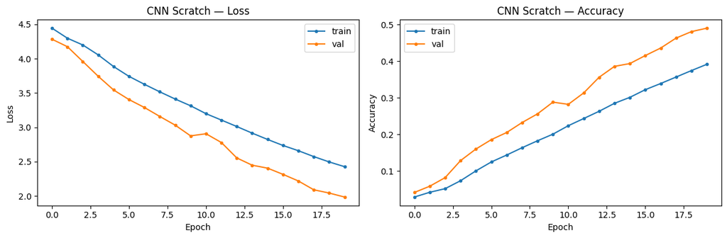

```python
# ── 8.4  Learning curves ──────────────────────────────────────────────────────
fig, (ax1, ax2) = plt.subplots(1, 2, figsize=(12, 4))

ax1.plot(history_scratch["train_loss"], label="train", marker="o", markersize=3)
ax1.plot(history_scratch["val_loss"],   label="val",   marker="o", markersize=3)
ax1.set_title("CNN Scratch — Loss")
ax1.set_xlabel("Epoch"); ax1.set_ylabel("Loss")
ax1.legend()

ax2.plot(history_scratch["train_acc"], label="train", marker="o", markersize=3)
ax2.plot(history_scratch["val_acc"],   label="val",   marker="o", markersize=3)
ax2.set_title("CNN Scratch — Accuracy")
ax2.set_xlabel("Epoch"); ax2.set_ylabel("Accuracy")
ax2.legend()

plt.tight_layout()
save_figure(fig, "cnn_scratch_curves.png")
plt.show()
```

### 8.5 — Final test evaluation

| Metric | Description |
| --- | --- |
| Test accuracy | Overall top-1 accuracy across all 101 classes |
| Macro F1 | Unweighted mean F1 across all classes — not biased by class frequency |
| Classification report | Per-class precision, recall, F1, support |

Results will be compared against ResNet-50 (Section 9) in the discussion.

```python
from sklearn.metrics import classification_report, f1_score

# ── 8.5  Final test evaluation (test set used once) ───────────────────────────
cnn_scratch.load_state_dict(load_checkpoint("cnn_scratch_best.pt"))
_, test_acc = evaluate(cnn_scratch, img_test_loader, criterion_cnn)

all_preds, all_labels = [], []
cnn_scratch.eval()
with torch.no_grad():
    for imgs, labels in img_test_loader:
        preds = cnn_scratch(imgs.to(DEVICE)).argmax(1).cpu()
        all_preds.extend(preds.tolist())
        all_labels.extend(labels.tolist())

macro_f1 = f1_score(all_labels, all_preds, average="macro")
print(f"CNN Scratch — Test accuracy : {test_acc:.4f}")
print(f"              Macro F1      : {macro_f1:.4f}\n")
print(classification_report(all_labels, all_preds,
                             target_names=_base_train_meta.classes,
                             zero_division=0))
print("\n✓ 8.5 — CNN Scratch test evaluation complete.")
```

```
  → Loading from VM: weights/cnn_scratch_best.pt
CNN Scratch — Test accuracy : 0.4828
              Macro F1      : 0.4672

                         precision    recall  f1-score   support

              apple_pie       0.30      0.09      0.14       150
         baby_back_ribs       0.52      0.49      0.50       150
                baklava       0.76      0.49      0.59       150
         beef_carpaccio       0.53      0.72      0.61       150
           beef_tartare       0.42      0.42      0.42       150
             beet_salad       0.61      0.31      0.41       150
               beignets       0.66      0.74      0.70       150
               bibimbap       0.48      0.71      0.57       150
          bread_pudding       0.34      0.17      0.22       150
      breakfast_burrito       0.25      0.11      0.15       150
             bruschetta       0.27      0.53      0.35       150
           caesar_salad       0.42      0.76      0.54       150
                cannoli       0.48      0.43      0.45       150
          caprese_salad       0.40      0.57      0.47       150
            carrot_cake       0.60      0.52      0.56       150
                ceviche       0.34      0.30      0.32       150
           cheese_plate       0.29      0.27      0.28       150
             cheesecake       0.52      0.21      0.30       150
          chicken_curry       0.45      0.44      0.45       150
     chicken_quesadilla       0.33      0.56      0.42       150
          chicken_wings       0.49      0.57      0.53       150
         chocolate_cake       0.40      0.50      0.45       150
       chocolate_mousse       0.30      0.07      0.11       150
                churros       0.68      0.43      0.53       150
           clam_chowder       0.66      0.59      0.62       150
          club_sandwich       0.42      0.61      0.50       150
             crab_cakes       0.34      0.41      0.37       150
           creme_brulee       0.59      0.70      0.64       150
          croque_madame       0.63      0.55      0.58       150
              cup_cakes       0.44      0.29      0.35       150
           deviled_eggs       0.55      0.59      0.57       150
                 donuts       0.43      0.15      0.23       150
              dumplings       0.93      0.65      0.77       150
                edamame       0.99      0.91      0.95       150
```

[output cut: 59 more lines]

```
                  steak       0.39      0.11      0.18       150
   strawberry_shortcake       0.40      0.67      0.50       150
                  sushi       0.51      0.54      0.52       150
                  tacos       0.41      0.19      0.26       150
               takoyaki       0.34      0.21      0.26       150
               tiramisu       0.46      0.35      0.39       150
           tuna_tartare       0.21      0.43      0.29       150
                waffles       0.66      0.52      0.58       150

               accuracy                           0.48     15150
              macro avg       0.49      0.48      0.47     15150
           weighted avg       0.49      0.48      0.47     15150


✓ 8.5 — CNN Scratch test evaluation complete.
```

### 8.5.1 — Test evaluation: visualisations

Three charts complementing the classification report in 8.5:

```
  ✓ cnn_scratch_per_class_accuracy.png  →  Colab VM + Drive
```

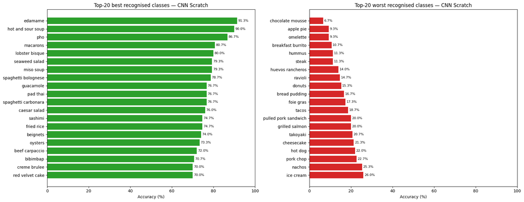

```
  ✓ cnn_scratch_confused_pairs.png  →  Colab VM + Drive
```

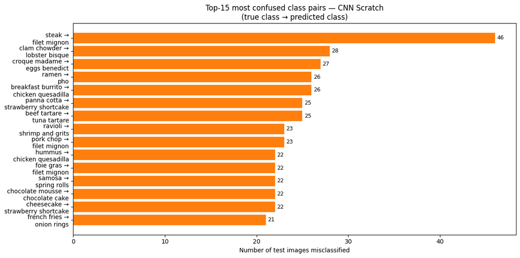

```
  ✓ cnn_scratch_confusion_matrix.png  →  Colab VM + Drive
```

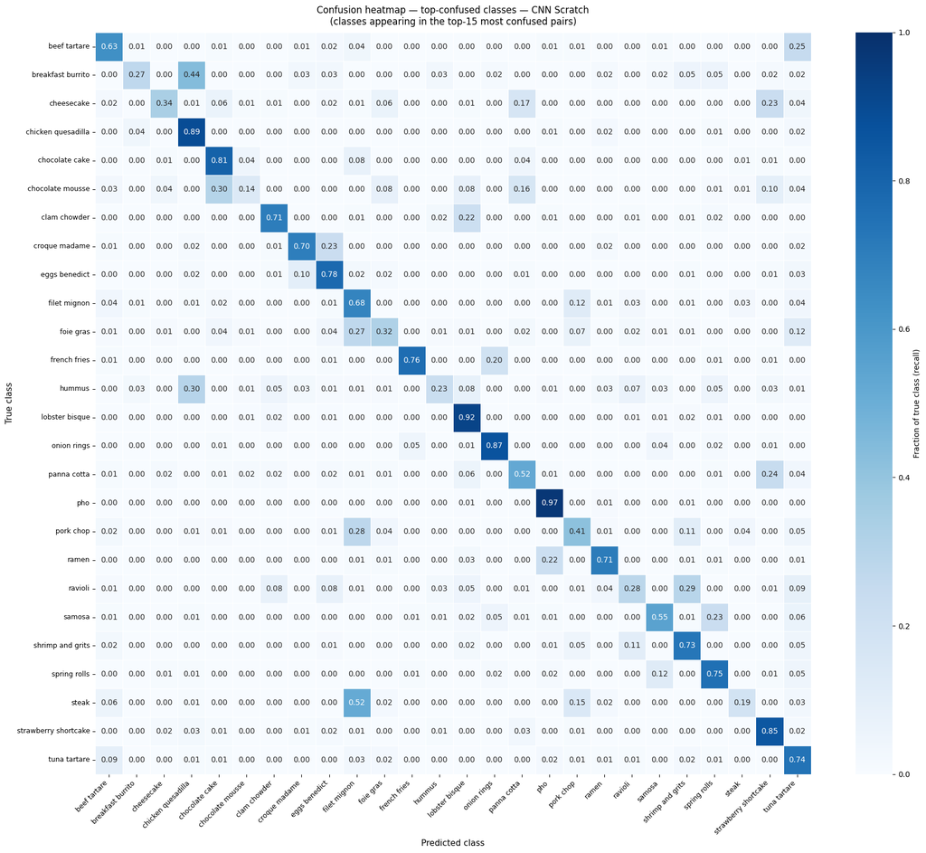

```
✓ 8.5b — visualisations complete.
```

```python
# ── 8.5b  Test evaluation visualisations — CNN Scratch ───────────────────────
import numpy as np
import seaborn as sns
from sklearn.metrics import confusion_matrix

_CLASS_NAMES = _base_train_meta.classes   # 101 Food-101 class names

# Build the full confusion matrix once
sc_cm = confusion_matrix(all_labels, all_preds, labels=list(range(101)))

# ── 1. Per-class accuracy bars ────────────────────────────────────────────────
sc_per_class_acc = sc_cm.diagonal() / sc_cm.sum(axis=1).clip(min=1)

sc_sorted_idx  = np.argsort(sc_per_class_acc)
sc_worst20_idx = sc_sorted_idx[:20]
sc_best20_idx  = sc_sorted_idx[-20:][::-1]

fig, (ax_best, ax_worst) = plt.subplots(1, 2, figsize=(18, 7))

ax_best.barh(
    [_CLASS_NAMES[i].replace("_", " ") for i in sc_best20_idx[::-1]],
    sc_per_class_acc[sc_best20_idx[::-1]] * 100, color="#2ca02c")
ax_best.set_xlim(0, 100)
ax_best.set_xlabel("Accuracy (%)")
ax_best.set_title("Top-20 best recognised classes — CNN Scratch")
for i, v in enumerate(sc_per_class_acc[sc_best20_idx[::-1]] * 100):
    ax_best.text(v + 0.5, i, f"{v:.1f}%", va="center", fontsize=8)

ax_worst.barh(
    [_CLASS_NAMES[i].replace("_", " ") for i in sc_worst20_idx[::-1]],
    sc_per_class_acc[sc_worst20_idx[::-1]] * 100, color="#d62728")
ax_worst.set_xlim(0, 100)
ax_worst.set_xlabel("Accuracy (%)")
ax_worst.set_title("Top-20 worst recognised classes — CNN Scratch")
for i, v in enumerate(sc_per_class_acc[sc_worst20_idx[::-1]] * 100):
    ax_worst.text(v + 0.5, i, f"{v:.1f}%", va="center", fontsize=8)

plt.tight_layout()
save_figure(fig, "cnn_scratch_per_class_accuracy.png")
plt.show()

# ── 2. Top-15 most confused pairs — bar chart ─────────────────────────────────
sc_cm_no_diag = sc_cm.copy()
np.fill_diagonal(sc_cm_no_diag, 0)

TOP_PAIRS     = 15
sc_flat_idx   = np.argsort(sc_cm_no_diag.ravel())[-(TOP_PAIRS):][::-1]
sc_true_idx   = sc_flat_idx // 101
sc_pred_idx   = sc_flat_idx % 101
sc_counts     = sc_cm_no_diag.ravel()[sc_flat_idx]
sc_pair_labels = [
    f"{_CLASS_NAMES[t].replace('_', ' ')} →\n{_CLASS_NAMES[p].replace('_', ' ')}"
    for t, p in zip(sc_true_idx, sc_pred_idx)
]

fig2, ax2 = plt.subplots(figsize=(12, 6))
ax2.barh(sc_pair_labels[::-1], sc_counts[::-1], color="#ff7f0e")
ax2.set_xlabel("Number of test images misclassified")
ax2.set_title(f"Top-{TOP_PAIRS} most confused class pairs — CNN Scratch\n(true class → predicted class)")
for i, v in enumerate(sc_counts[::-1]):
    ax2.text(v + 0.2, i, str(int(v)), va="center", fontsize=9)
plt.tight_layout()
save_figure(fig2, "cnn_scratch_confused_pairs.png")
plt.show()

# ── 3. Focused confusion heatmap — classes from top confused pairs only ────────
# Collect unique class indices that appear in the top pairs
sc_focus_idx = sorted(set(sc_true_idx.tolist() + sc_pred_idx.tolist()))
sc_focus_labels = [_CLASS_NAMES[i].replace("_", " ") for i in sc_focus_idx]

# Slice the full CM to keep only those rows/columns, then row-normalise
sc_cm_focus = sc_cm[np.ix_(sc_focus_idx, sc_focus_idx)]
sc_cm_focus_norm = (sc_cm_focus.astype(float)
                    / sc_cm_focus.sum(axis=1, keepdims=True).clip(min=1))

n_focus = len(sc_focus_idx)
fig3, ax3 = plt.subplots(figsize=(max(10, n_focus * 0.7), max(8, n_focus * 0.6)))
sns.heatmap(
    sc_cm_focus_norm,
    ax=ax3,
    annot=True, fmt=".2f",
    cmap="Blues",
    linewidths=0.5,
    xticklabels=sc_focus_labels,
    yticklabels=sc_focus_labels,
    cbar_kws={"label": "Fraction of true class (recall)"},
    vmin=0, vmax=1,
)
ax3.set_xlabel("Predicted class", fontsize=11)
ax3.set_ylabel("True class", fontsize=11)
ax3.set_title(
    f"Confusion heatmap — top-confused classes — CNN Scratch\n"
    f"(classes appearing in the top-{TOP_PAIRS} most confused pairs)",
    fontsize=12, pad=10)
plt.setp(ax3.get_xticklabels(), rotation=45, ha="right", fontsize=9)
plt.setp(ax3.get_yticklabels(), rotation=0, fontsize=9)
plt.tight_layout()
save_figure(fig3, "cnn_scratch_confusion_matrix.png")
plt.show()

print("✓ 8.5b — visualisations complete.")
```

### 8.6 — Prediction visualiser

For each sample: the original food image is shown on the left with its true label; the right panel shows a **top-10 softmax confidence bar chart**.

- **Green bar** — model's top-1 prediction is correct (`✓ Correct`)
- **Red bar** — model's top-1 prediction is wrong (`✗ Wrong`)
- Dashed line at 50 % marks the decision boundary reference

`plot_predictions()` accepts `class_names`, `n`, `top_k`, and `seed` — it is reused as-is for ResNet-50 in Section 9.

```
  → Loading from VM: weights/cnn_scratch_best.pt
  ✓ cnn_scratch_predictions.png  →  Colab VM + Drive
```

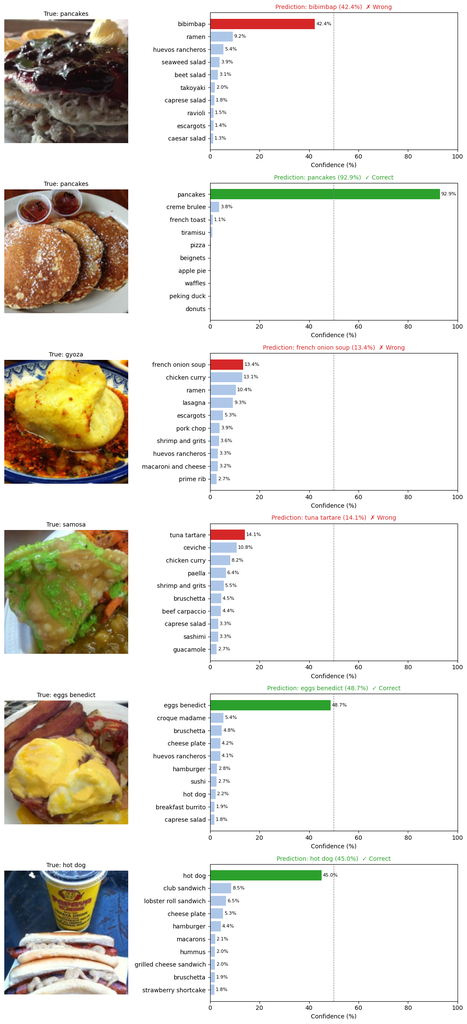

```
✓ Section 8 complete.
```

```python
# ── 8.6  Prediction visualiser ────────────────────────────────────────────────
# plot_predictions() is reused for ResNet-50 in Section 9.
import random

_N_SAMPLES   = 6
_TOP_K       = 10
_CLASS_NAMES = _base_train_meta.classes   # 101 Food-101 class names

def plot_predictions(model, dataset, class_names=_CLASS_NAMES,
                     n=_N_SAMPLES, top_k=_TOP_K, seed=42, save_filename=None):
    """Show n panels: food image (left) + top-k confidence bar chart (right).
    Green bar = correct prediction, red bar = wrong prediction."""
    model.eval()
    rng     = random.Random(seed)
    indices = rng.sample(range(len(dataset)), n)

    fig, axes = plt.subplots(n, 2, figsize=(11, 4 * n),
                             gridspec_kw={"width_ratios": [1, 2]})

    with torch.no_grad():
        for row, idx in enumerate(indices):
            img_tensor, true_label = dataset[idx]

            logits     = model(img_tensor.unsqueeze(0).to(DEVICE))
            probs      = torch.softmax(logits, dim=1).squeeze().cpu()
            top_probs, top_ids = probs.topk(top_k)

            pred_label = top_ids[0].item()
            confidence = top_probs[0].item() * 100
            is_correct = (pred_label == true_label)
            bar_color  = "#2ca02c" if is_correct else "#d62728"

            # ── food image ────────────────────────────────────────────────────
            ax_img = axes[row, 0]
            img_show = img_tensor.clone()
            for c, (m, s) in enumerate(zip(IMAGENET_MEAN, IMAGENET_STD)):
                img_show[c] = img_show[c] * s + m
            ax_img.imshow(img_show.clamp(0, 1).permute(1, 2, 0).numpy())
            ax_img.set_title(f"True: {class_names[true_label].replace('_', ' ')}",
                             fontsize=10)
            ax_img.axis("off")

            # ── confidence bar chart ──────────────────────────────────────────
            ax_bar    = axes[row, 1]
            bar_lbls  = [class_names[i.item()].replace("_", " ") for i in top_ids]
            bar_vals  = [p.item() * 100 for p in top_probs]
            bar_colrs = [bar_color if i == 0 else "#aec7e8" for i in range(top_k)]

            bars = ax_bar.barh(bar_lbls[::-1], bar_vals[::-1], color=bar_colrs[::-1])
            ax_bar.axvline(50, color="gray", linestyle="--", linewidth=0.8)
            ax_bar.set_xlim(0, 100)
            ax_bar.set_xlabel("Confidence (%)")
            ax_bar.set_title(
                f"Prediction: {class_names[pred_label].replace('_', ' ')} "
                f"({confidence:.1f}%)  "
                f"{'✓ Correct' if is_correct else '✗ Wrong'}",
                fontsize=10, color=bar_color,
            )
            for bar, val in zip(bars[::-1], bar_vals):
                if val > 1:
                    ax_bar.text(val + 0.5, bar.get_y() + bar.get_height() / 2,
                                f"{val:.1f}%", va="center", fontsize=8)

    plt.tight_layout()
    if save_filename:
        save_figure(fig, save_filename)
    plt.show()


cnn_scratch.load_state_dict(load_checkpoint("cnn_scratch_best.pt"))
plot_predictions(cnn_scratch, img_test_ds, seed=42,
                 save_filename="cnn_scratch_predictions.png")
print("✓ Section 8 complete.")
```

## Section 9 — CNN: ResNet-50 (Transfer Learning)

**Requires GPU — run in Google Colab.**

ResNet-50 pre-trained on ImageNet is fine-tuned on Food-101 using a two-phase strategy. Reuses `train_one_epoch`, `evaluate`, and `criterion_cnn` defined in Section 8.2.

| Sub-section | What |
| --- | --- |
| **9.1** | Build model — replace final FC layer for 101 classes, freeze backbone |
| **9.2** | Phase A — train head only (5 epochs, LR 1e-3) |
| **9.3** | Phase B — unfreeze `layer4` (10 epochs, LR 1e-4) |
| **9.3.1** | Resume Phase B (same session, after interruption) |
| **9.3.2** | Restore all state from checkpoint (after kernel restart) |
| **9.4** | Learning curves (Phase A + B combined, phase boundary marked) |
| **9.5** | Final test evaluation: accuracy, macro F1, comparison against CNN Scratch |
| **9.5.1** | Test visualisations: per-class accuracy bars, confused pairs, heatmap |
| **9.6** | Prediction visualiser (reuses `plot_predictions()` from §8.6) |
| **9.7** | CNN Scratch vs. ResNet-50 discussion |

**Two-phase fine-tuning rationale**

| Phase | Layers trained | Epochs | LR | Why |
| --- | --- | --- | --- | --- |
| A | Head only (backbone frozen) | 5 | 1e-3 | Stable head initialisation before touching backbone weights |
| B | Head + `layer4` unfrozen | 10 | 1e-4 | Adapts high-level features to food domain without corrupting low-level ImageNet representations |

Checkpoints saved every epoch; best model (lowest Phase B val loss) saved to `cnn_resnet50_best.pt`.

```python
# ── 9.1  Build ResNet-50 ──────────────────────────────────────────────────────
resnet50 = models.resnet50(weights=models.ResNet50_Weights.IMAGENET1K_V1)

# Freeze all layers
for p in resnet50.parameters():
    p.requires_grad = False

# Replace classification head → 101 classes
resnet50.fc = nn.Linear(2048, 101)
resnet50    = resnet50.to(DEVICE)

frozen  = sum(p.numel() for p in resnet50.parameters() if not p.requires_grad)
trained = sum(p.numel() for p in resnet50.parameters() if p.requires_grad)
print(f"ResNet-50 — frozen: {frozen:,}  trainable: {trained:,}")

assert resnet50(torch.randn(2, 3, 224, 224).to(DEVICE)).shape == (2, 101)
print("Forward pass: OK → shape (2, 101)")
```

```
Downloading: "https://download.pytorch.org/models/resnet50-0676ba61.pth" to /root/.cache/torch/hub/checkpoints/resnet50-0676ba61.pth
```

```
ResNet-50 — frozen: 23,508,032  trainable: 206,949
Forward pass: OK → shape (2, 101)
```

### 9.2 — Phase A: train head only (epochs 1–5, LR 1e-3)

The backbone is fully frozen. Only the replacement FC layer is trained. This prevents noisy early gradients from corrupting pre-trained ImageNet features.

```python
# ── 9.2  Phase A — frozen backbone, head only ─────────────────────────────────
# Prerequisites check — catches missing definitions early with clear guidance
_missing = [name for name in
    ["train_one_epoch", "evaluate", "criterion_cnn",
     "img_train_loader", "img_val_loader"]
    if name not in dir() and name not in vars()]
if _missing:
    raise RuntimeError(
        f"\n❌ Missing from kernel: {_missing}\n"
        "   After reconnecting, re-run these sections IN ORDER before Section 9.2:\n"
        "   1. Section 1  (1.0 → 1.3) — imports, paths, Drive mount, helpers\n"
        "   2. Section 2  — Food-101 raw data loading (ds_train, ds_test)\n"
        "   3. Section 4.2 — index arrays (_idx_train, _idx_val, _idx_test)\n"
        "   4. Section 6  — image transforms + DataLoaders\n"
        "   5. Section 8.1 — CNNScratch architecture + criterion_cnn\n"
        "   6. Section 8.2 — train_one_epoch, evaluate\n"
        "   7. Section 9.1 — rebuild ResNet-50\n"
        "   Then re-run this cell."
    )

opt_rn   = Adam(resnet50.fc.parameters(), lr=1e-3)
sch_rn   = ReduceLROnPlateau(opt_rn, factor=0.5, patience=2)
hist_rn  = {"train_loss": [], "val_loss": [], "train_acc": [], "val_acc": []}
best_rn_a_loss = float("inf")

print("── Phase A (frozen backbone, head only) ──")
for epoch in range(1, 6):
    tr_loss, tr_acc = train_one_epoch(resnet50, img_train_loader, criterion_cnn, opt_rn)
    vl_loss, vl_acc = evaluate(resnet50, img_val_loader, criterion_cnn)
    sch_rn.step(vl_loss)
    hist_rn["train_loss"].append(tr_loss); hist_rn["val_loss"].append(vl_loss)
    hist_rn["train_acc"].append(tr_acc);  hist_rn["val_acc"].append(vl_acc)
    save_checkpoint(
        {"epoch": epoch, "model_state": resnet50.state_dict(),
         "optimizer_state": opt_rn.state_dict(), "val_loss": vl_loss,
         "history": hist_rn},
        f"resnet50_phaseA_ckpt_ep{epoch:02d}.pt"
    )
    if vl_loss < best_rn_a_loss:
        best_rn_a_loss = vl_loss
        save_checkpoint(resnet50.state_dict(), "resnet50_phaseA_best.pt")
    print(f"  Ep {epoch} | train {tr_loss:.4f}/{tr_acc:.3f} | val {vl_loss:.4f}/{vl_acc:.3f}")

print("\n✓ Phase A complete — best Phase A weights saved as resnet50_phaseA_best.pt")
```

```
── Phase A (frozen backbone, head only) ──
  ✓ resnet50_phaseA_ckpt_ep01.pt  →  Colab VM + Drive
  ✓ resnet50_phaseA_best.pt  →  Colab VM + Drive
  Ep 1 | train 2.7853/0.348 | val 1.9966/0.500
  ✓ resnet50_phaseA_ckpt_ep02.pt  →  Colab VM + Drive
  ✓ resnet50_phaseA_best.pt  →  Colab VM + Drive
  Ep 2 | train 2.3005/0.437 | val 1.9483/0.517
  ✓ resnet50_phaseA_ckpt_ep03.pt  →  Colab VM + Drive
  ✓ resnet50_phaseA_best.pt  →  Colab VM + Drive
  Ep 3 | train 2.2141/0.458 | val 1.8708/0.537
  ✓ resnet50_phaseA_ckpt_ep04.pt  →  Colab VM + Drive
  ✓ resnet50_phaseA_best.pt  →  Colab VM + Drive
  Ep 4 | train 2.1674/0.467 | val 1.8701/0.538
  ✓ resnet50_phaseA_ckpt_ep05.pt  →  Colab VM + Drive
  ✓ resnet50_phaseA_best.pt  →  Colab VM + Drive
  Ep 5 | train 2.1312/0.475 | val 1.8140/0.549

✓ Phase A complete — best Phase A weights saved as resnet50_phaseA_best.pt
```

### 9.3 — Phase B: unfreeze layer4 (epochs 6–15, LR 1e-4)

Unfreezes ResNet-50's final convolutional block (layer4) and continues training at a 10× lower learning rate. Low LR is essential here — layer4 already contains useful high-level features; we adapt rather than overwrite them.

Run this cell when continuing in the same session immediately after Phase A. If the session was interrupted, use **9.3b** to restore from checkpoint first.

```python
# ── 9.3  Phase B — unfreeze layer4 ───────────────────────────────────────────
# Run this cell only if Phase A finished in the SAME session.
# After a disconnect → use 9.3-RESUME below instead.

for p in resnet50.layer4.parameters():
    p.requires_grad = True

opt_rn_b     = Adam(filter(lambda p: p.requires_grad, resnet50.parameters()), lr=1e-4)
sch_rn_b     = ReduceLROnPlateau(opt_rn_b, factor=0.5, patience=2)
best_rn_loss = float("inf")

print("── Phase B (layer4 + head unfrozen) ──")
for epoch in range(6, 16):
    tr_loss, tr_acc = train_one_epoch(resnet50, img_train_loader, criterion_cnn, opt_rn_b)
    vl_loss, vl_acc = evaluate(resnet50, img_val_loader, criterion_cnn)
    sch_rn_b.step(vl_loss)
    hist_rn["train_loss"].append(tr_loss); hist_rn["val_loss"].append(vl_loss)
    hist_rn["train_acc"].append(tr_acc);  hist_rn["val_acc"].append(vl_acc)
    save_checkpoint(
        {"epoch": epoch, "model_state": resnet50.state_dict(),
         "optimizer_state": opt_rn_b.state_dict(), "val_loss": vl_loss,
         "history": hist_rn},
        f"resnet50_phaseB_ckpt_ep{epoch:02d}.pt"
    )
    print(f"  Ep {epoch} | train {tr_loss:.4f}/{tr_acc:.3f} | val {vl_loss:.4f}/{vl_acc:.3f}")
    if vl_loss < best_rn_loss:
        best_rn_loss = vl_loss
        save_checkpoint(resnet50.state_dict(), "cnn_resnet50_best.pt")

print("\n✓ Phase B complete — best model saved as cnn_resnet50_best.pt")
```

```
── Phase B (layer4 + head unfrozen) ──
  ✓ resnet50_phaseB_ckpt_ep06.pt  →  Colab VM + Drive
  Ep 6 | train 1.6133/0.585 | val 1.1549/0.697
  ✓ cnn_resnet50_best.pt  →  Colab VM + Drive
  ✓ resnet50_phaseB_ckpt_ep07.pt  →  Colab VM + Drive
  Ep 7 | train 1.2543/0.668 | val 1.0693/0.721
  ✓ cnn_resnet50_best.pt  →  Colab VM + Drive
  ✓ resnet50_phaseB_ckpt_ep08.pt  →  Colab VM + Drive
  Ep 8 | train 1.0883/0.708 | val 0.9983/0.738
  ✓ cnn_resnet50_best.pt  →  Colab VM + Drive
  ✓ resnet50_phaseB_ckpt_ep09.pt  →  Colab VM + Drive
  Ep 9 | train 0.9799/0.734 | val 0.9939/0.742
  ✓ cnn_resnet50_best.pt  →  Colab VM + Drive
  ✓ resnet50_phaseB_ckpt_ep10.pt  →  Colab VM + Drive
  Ep 10 | train 0.8939/0.754 | val 0.9638/0.753
  ✓ cnn_resnet50_best.pt  →  Colab VM + Drive
  ✓ resnet50_phaseB_ckpt_ep11.pt  →  Colab VM + Drive
  Ep 11 | train 0.8153/0.772 | val 0.9615/0.761
  ✓ cnn_resnet50_best.pt  →  Colab VM + Drive
  ✓ resnet50_phaseB_ckpt_ep12.pt  →  Colab VM + Drive
  Ep 12 | train 0.7554/0.788 | val 0.9311/0.764
  ✓ cnn_resnet50_best.pt  →  Colab VM + Drive
  ✓ resnet50_phaseB_ckpt_ep13.pt  →  Colab VM + Drive
  Ep 13 | train 0.6970/0.803 | val 0.9211/0.771
  ✓ cnn_resnet50_best.pt  →  Colab VM + Drive
  ✓ resnet50_phaseB_ckpt_ep14.pt  →  Colab VM + Drive
  Ep 14 | train 0.6491/0.814 | val 0.9370/0.765
  ✓ resnet50_phaseB_ckpt_ep15.pt  →  Colab VM + Drive
  Ep 15 | train 0.6028/0.825 | val 0.9169/0.777
  ✓ cnn_resnet50_best.pt  →  Colab VM + Drive

✓ Phase B complete — best model saved as cnn_resnet50_best.pt
```

### 9.3.1 — Resume Phase B from checkpoint

If Phase B was interrupted mid-run, reload the latest Phase B epoch checkpoint and continue from where training stopped (session must still be active).

```python
# ── 9.3-RESUME  Restore and continue Phase B after a disconnect ───────────────
# After reconnecting: re-run Sections 1.0 → 1.3 first, then run THIS cell.
# DO NOT run the 9.3 cell above — it assumes Phase A model is still in memory.

# ── Step 1: Rebuild model architecture ────────────────────────────────────────
resnet50 = models.resnet50(weights=None)
resnet50.fc = nn.Linear(2048, 101)
for p in resnet50.layer4.parameters():
    p.requires_grad = True
resnet50 = resnet50.to(DEVICE)

# ── Step 2: Find the latest Phase B checkpoint (fall back to Phase A best) ────
resume_from   = None
start_epoch   = 6
best_rn_loss  = float("inf")
ckpt          = None

for ep in range(15, 5, -1):
    try:
        ckpt = load_checkpoint(f"resnet50_phaseB_ckpt_ep{ep:02d}.pt")
        resume_from = ep
        break
    except FileNotFoundError:
        pass

if resume_from is None:
    print("  No Phase B checkpoint found — loading Phase A best to start Phase B")
    # Try to restore Phase A history from its last checkpoint
    try:
        _ckpt_a = load_checkpoint("resnet50_phaseA_ckpt_ep05.pt")
        hist_rn = _ckpt_a["history"]
        print(f"  Phase A history restored: {len(hist_rn['train_loss'])} epochs")
    except (FileNotFoundError, KeyError):
        hist_rn = {"train_loss": [], "val_loss": [], "train_acc": [], "val_acc": []}
        print("  Phase A history not available — starting history fresh")
    resnet50.load_state_dict(load_checkpoint("resnet50_phaseA_best.pt"))
    start_epoch  = 6
    best_rn_loss = float("inf")
else:
    resnet50.load_state_dict(ckpt["model_state"])
    start_epoch  = ckpt["epoch"] + 1
    best_rn_loss = ckpt["val_loss"]
    hist_rn      = ckpt["history"]
    print(f"  Resuming Phase B from epoch {start_epoch} "
          f"(last val loss: {best_rn_loss:.4f}, "
          f"history: {len(hist_rn['train_loss'])} epochs)")

# ── Step 3: Resume Phase B ────────────────────────────────────────────────────
opt_rn_b = Adam(filter(lambda p: p.requires_grad, resnet50.parameters()), lr=1e-4)
sch_rn_b = ReduceLROnPlateau(opt_rn_b, factor=0.5, patience=2)
if ckpt is not None and "optimizer_state" in ckpt:
    opt_rn_b.load_state_dict(ckpt["optimizer_state"])

print(f"\n── Phase B resumed (epochs {start_epoch}–15) ──")
for epoch in range(start_epoch, 16):
    tr_loss, tr_acc = train_one_epoch(resnet50, img_train_loader, criterion_cnn, opt_rn_b)
    vl_loss, vl_acc = evaluate(resnet50, img_val_loader, criterion_cnn)
    sch_rn_b.step(vl_loss)
    hist_rn["train_loss"].append(tr_loss); hist_rn["val_loss"].append(vl_loss)
    hist_rn["train_acc"].append(tr_acc);  hist_rn["val_acc"].append(vl_acc)
    save_checkpoint(
        {"epoch": epoch, "model_state": resnet50.state_dict(),
         "optimizer_state": opt_rn_b.state_dict(), "val_loss": vl_loss,
         "history": hist_rn},
        f"resnet50_phaseB_ckpt_ep{epoch:02d}.pt"
    )
    print(f"  Ep {epoch} | train {tr_loss:.4f}/{tr_acc:.3f} | val {vl_loss:.4f}/{vl_acc:.3f}")
    if vl_loss < best_rn_loss:
        best_rn_loss = vl_loss
        save_checkpoint(resnet50.state_dict(), "cnn_resnet50_best.pt")

print("\n✓ Phase B complete — best model saved as cnn_resnet50_best.pt")
```

### 9.3.2 — Restore training state from checkpoint

After a kernel restart (e.g. Colab disconnect), training results and helper functions are lost from memory but checkpoints are still saved on Google Drive. This cell restores **everything** needed by Sections 9.4–9.5:

- `evaluate()` and `train_one_epoch()` functions
- `criterion_cnn` (CrossEntropyLoss)
- `hist_rn` (training curves — Phase A + Phase B combined)
- `resnet50` best weights (`cnn_resnet50_best.pt`)

> **When to use:** Run this cell instead of 9.3 / 9.3-RESUME when you only need to produce learning curves, evaluation, or visualisations from a previously completed training run.

```python
# ── 9.3b  Restore all Section 9 state from saved checkpoints ─────────────────
# Use this cell after a kernel restart to reload training history, model weights,
# helper functions, and loss criterion from Drive — without re-running training.
import glob, os

# ── 1. Training utilities (evaluate, train_one_epoch, criterion) ─────────────
@torch.no_grad()
def evaluate(model, loader, criterion):
    model.eval()
    total_loss, correct, n = 0.0, 0, 0
    for imgs, labels in loader:
        imgs, labels = imgs.to(DEVICE), labels.to(DEVICE)
        logits = model(imgs)
        total_loss += criterion(logits, labels).item() * len(labels)
        correct    += (logits.argmax(1) == labels).sum().item()
        n          += len(labels)
    return total_loss / n, correct / n

def train_one_epoch(model, loader, criterion, optimizer):
    model.train()
    total_loss, correct, n = 0.0, 0, 0
    for imgs, labels in loader:
        imgs, labels = imgs.to(DEVICE), labels.to(DEVICE)
        optimizer.zero_grad()
        logits = model(imgs)
        loss   = criterion(logits, labels)
        loss.backward()
        optimizer.step()
        total_loss += loss.item() * len(labels)
        correct    += (logits.argmax(1) == labels).sum().item()
        n          += len(labels)
    return total_loss / n, correct / n

criterion_cnn = nn.CrossEntropyLoss()

# ── 2. Restore hist_rn — Phase B checkpoint first, fall back to Phase A ───────
_rn_b_ckpts = sorted(glob.glob(str(WEIGHTS / 'resnet50_phaseB_ckpt_ep*.pt')))
_rn_a_ckpts = sorted(glob.glob(str(WEIGHTS / 'resnet50_phaseA_ckpt_ep*.pt')))

if _rn_b_ckpts:
    _last_ckpt_rn = load_checkpoint(os.path.basename(_rn_b_ckpts[-1]))
    _source = f'Phase B  ({os.path.basename(_rn_b_ckpts[-1])})'
elif _rn_a_ckpts:
    _last_ckpt_rn = load_checkpoint(os.path.basename(_rn_a_ckpts[-1]))
    _source = f'Phase A  ({os.path.basename(_rn_a_ckpts[-1])})'
else:
    raise FileNotFoundError(
        'No ResNet-50 checkpoint found in weights folder — run Section 9.2 / 9.3 first.'
    )

hist_rn = _last_ckpt_rn['history']

# ── 3. Rebuild ResNet-50 architecture and load best weights ────────────────
resnet50 = models.resnet50(weights=None)
resnet50.fc = nn.Linear(2048, 101)
resnet50 = resnet50.to(DEVICE)
resnet50.load_state_dict(load_checkpoint('cnn_resnet50_best.pt'))

print('✓ 9.3b — All Section 9 state restored:')
print(f'  Functions : evaluate, train_one_epoch')
print(f'  Criterion : criterion_cnn (CrossEntropyLoss)')
print(f'  History   : {len(hist_rn["train_loss"])} epochs  ← {_source}')
print(f'  Model     : resnet50 loaded with best weights (cnn_resnet50_best.pt)')
print(f'  Best val loss: {min(hist_rn["val_loss"]):.4f}')
print(f'  Best val acc:  {max(hist_rn["val_acc"]):.4f}')
```

### 9.4 — Learning curves

Plot combined Phase A + Phase B training and validation loss/accuracy. The phase boundary (epoch 5) is marked with a vertical dashed line to show where backbone unfreezing occurs.

```
  ✓ resnet50_curves.png  →  Colab VM + Drive
```

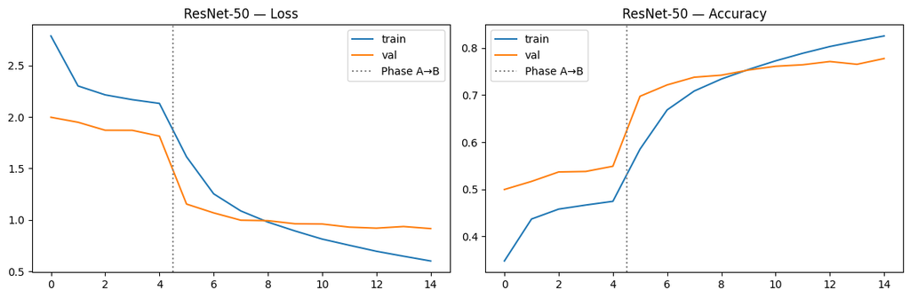

```python
# ── 9.4  Learning curves ──────────────────────────────────────────────────────
fig, (ax1, ax2) = plt.subplots(1, 2, figsize=(12, 4))
ax1.plot(hist_rn["train_loss"], label="train"); ax1.plot(hist_rn["val_loss"], label="val")
# Phase A→B boundary only visible if hist_rn contains both phases
if len(hist_rn["train_loss"]) > 5:
    ax1.axvline(4.5, color="gray", linestyle=":", label="Phase A→B")
ax1.set_title("ResNet-50 — Loss"); ax1.legend()
ax2.plot(hist_rn["train_acc"],  label="train"); ax2.plot(hist_rn["val_acc"],  label="val")
if len(hist_rn["train_acc"]) > 5:
    ax2.axvline(4.5, color="gray", linestyle=":", label="Phase A→B")
ax2.set_title("ResNet-50 — Accuracy"); ax2.legend()
plt.tight_layout()
save_figure(fig, "resnet50_curves.png")
plt.show()
```

### 9.5 — Final test evaluation

The **test set is used exactly once** here. Loads `cnn_resnet50_best.pt` (best Phase B val loss) and reports test accuracy and macro F1, with a side-by-side comparison against CNN Scratch (Section 8.5).

```python
from sklearn.metrics import f1_score

# ── 9.5  Final test evaluation (test set used once) ───────────────────────────
resnet50.load_state_dict(load_checkpoint("cnn_resnet50_best.pt"))
_, rn_test_acc = evaluate(resnet50, img_test_loader, criterion_cnn)

rn_preds, rn_labels = [], []
resnet50.eval()
with torch.no_grad():
    for imgs, labels in img_test_loader:
        preds = resnet50(imgs.to(DEVICE)).argmax(1).cpu()
        rn_preds.extend(preds.tolist())
        rn_labels.extend(labels.tolist())

rn_f1 = f1_score(rn_labels, rn_preds, average="macro")
print(f"ResNet-50   — Test accuracy: {rn_test_acc:.4f}  Macro F1: {rn_f1:.4f}")

# Side-by-side comparison — only available if Section 8.5 ran in this session
if "test_acc" in vars() and "macro_f1" in vars():
    print(f"CNN Scratch — Test accuracy: {test_acc:.4f}  Macro F1: {macro_f1:.4f}")
    print(f"ResNet-50 gain             : +{(rn_test_acc - test_acc)*100:.1f} pp accuracy")
else:
    print("CNN Scratch — results not in memory (re-run §8.5 to compare)")
print("\n✓ 9.5 — ResNet-50 test evaluation complete.")
```

```
  → Loading from VM: weights/cnn_resnet50_best.pt
ResNet-50   — Test accuracy: 0.7723  Macro F1: 0.7714
CNN Scratch — Test accuracy: 0.4828  Macro F1: 0.4672
ResNet-50 gain             : +29.0 pp accuracy

✓ 9.5 — ResNet-50 test evaluation complete.
```

### 9.5.1 — Test evaluation: visualisations

Three charts complementing the classification report in 9.5:

1. **Top-20 best / worst classes** — per-class accuracy bars
2. **Top-15 most confused pairs** — bar chart of highest off-diagonal confusion counts
3. **Focused confusion heatmap** — only the classes involved in the top-15 confused pairs, row-normalised so each cell is a recall fraction

```
  ✓ resnet50_per_class_accuracy.png  →  Colab VM + Drive
```

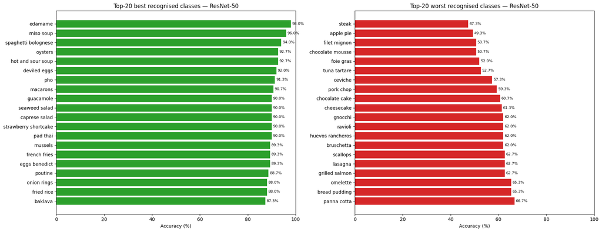

```
  ✓ resnet50_confused_pairs.png  →  Colab VM + Drive
```

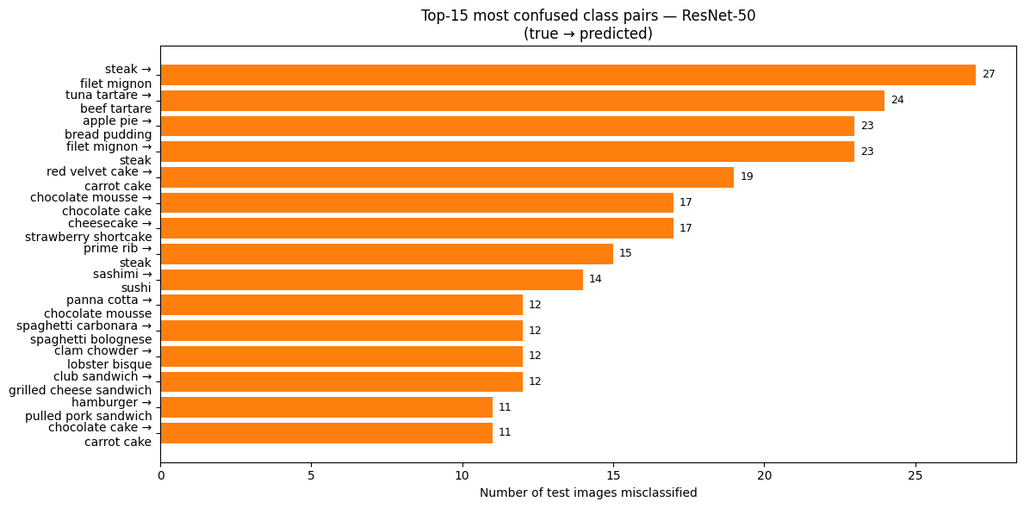

```
  ✓ resnet50_confusion_matrix.png  →  Colab VM + Drive
```

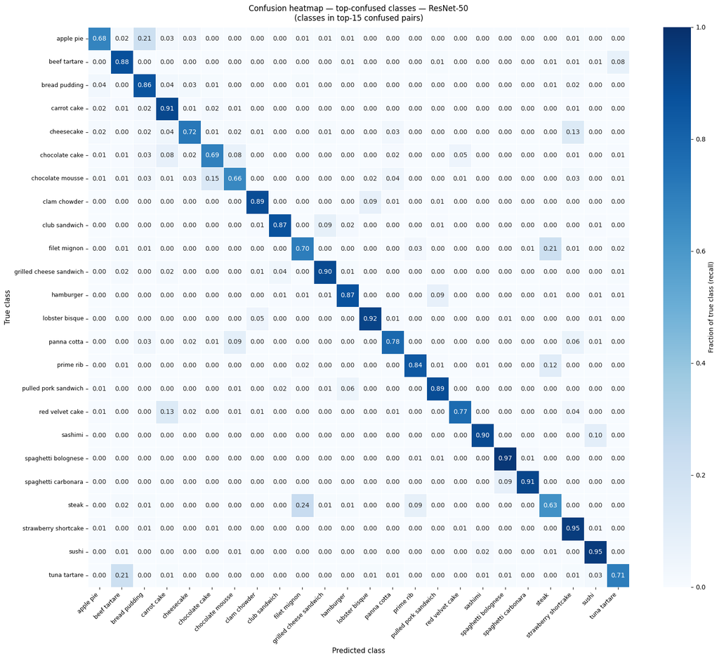

```
✓ 9.5b — ResNet-50 visualisations complete.
```

```python
# ── 9.5b  Test evaluation visualisations — ResNet-50 ─────────────────────────
import seaborn as sns
from sklearn.metrics import confusion_matrix

_CLASS_NAMES = _base_train_meta.classes   # 101 Food-101 class names

cm = confusion_matrix(rn_labels, rn_preds, labels=list(range(101)))

# ── 1. Per-class accuracy bars ────────────────────────────────────────────────
per_class_acc = cm.diagonal() / cm.sum(axis=1).clip(min=1)
sorted_idx    = np.argsort(per_class_acc)
worst20_idx   = sorted_idx[:20]
best20_idx    = sorted_idx[-20:][::-1]

fig, (ax_best, ax_worst) = plt.subplots(1, 2, figsize=(18, 7))

ax_best.barh(
    [_CLASS_NAMES[i].replace("_", " ") for i in best20_idx[::-1]],
    per_class_acc[best20_idx[::-1]] * 100, color="#2ca02c")
ax_best.set_xlim(0, 100); ax_best.set_xlabel("Accuracy (%)")
ax_best.set_title("Top-20 best recognised classes — ResNet-50")
for i, v in enumerate(per_class_acc[best20_idx[::-1]] * 100):
    ax_best.text(v + 0.5, i, f"{v:.1f}%", va="center", fontsize=8)

ax_worst.barh(
    [_CLASS_NAMES[i].replace("_", " ") for i in worst20_idx[::-1]],
    per_class_acc[worst20_idx[::-1]] * 100, color="#d62728")
ax_worst.set_xlim(0, 100); ax_worst.set_xlabel("Accuracy (%)")
ax_worst.set_title("Top-20 worst recognised classes — ResNet-50")
for i, v in enumerate(per_class_acc[worst20_idx[::-1]] * 100):
    ax_worst.text(v + 0.5, i, f"{v:.1f}%", va="center", fontsize=8)

plt.tight_layout()
save_figure(fig, "resnet50_per_class_accuracy.png")
plt.show()

# ── 2. Top-15 most confused pairs — bar chart ─────────────────────────────────
cm_no_diag = cm.copy()
np.fill_diagonal(cm_no_diag, 0)

TOP_PAIRS   = 15
flat_idx    = np.argsort(cm_no_diag.ravel())[-TOP_PAIRS:][::-1]
true_idx    = flat_idx // 101
pred_idx    = flat_idx % 101
counts      = cm_no_diag.ravel()[flat_idx]
pair_labels = [
    f"{_CLASS_NAMES[t].replace('_', ' ')} →\n{_CLASS_NAMES[p].replace('_', ' ')}"
    for t, p in zip(true_idx, pred_idx)
]

fig2, ax2 = plt.subplots(figsize=(12, 6))
ax2.barh(pair_labels[::-1], counts[::-1], color="#ff7f0e")
ax2.set_xlabel("Number of test images misclassified")
ax2.set_title(f"Top-{TOP_PAIRS} most confused class pairs — ResNet-50\n(true → predicted)")
for i, v in enumerate(counts[::-1]):
    ax2.text(v + 0.2, i, str(int(v)), va="center", fontsize=9)
plt.tight_layout()
save_figure(fig2, "resnet50_confused_pairs.png")
plt.show()

# ── 3. Focused confusion heatmap ──────────────────────────────────────────────
focus_idx    = sorted(set(true_idx.tolist() + pred_idx.tolist()))
focus_labels = [_CLASS_NAMES[i].replace("_", " ") for i in focus_idx]
cm_focus     = cm[np.ix_(focus_idx, focus_idx)]
cm_focus_norm = cm_focus.astype(float) / cm_focus.sum(axis=1, keepdims=True).clip(min=1)

n_focus = len(focus_idx)
fig3, ax3 = plt.subplots(figsize=(max(10, n_focus * 0.7), max(8, n_focus * 0.6)))
sns.heatmap(cm_focus_norm, ax=ax3, annot=True, fmt=".2f", cmap="Blues",
            linewidths=0.5, xticklabels=focus_labels, yticklabels=focus_labels,
            cbar_kws={"label": "Fraction of true class (recall)"}, vmin=0, vmax=1)
ax3.set_xlabel("Predicted class", fontsize=11)
ax3.set_ylabel("True class", fontsize=11)
ax3.set_title(
    f"Confusion heatmap — top-confused classes — ResNet-50\n"
    f"(classes in top-{TOP_PAIRS} confused pairs)",
    fontsize=12, pad=10)
plt.setp(ax3.get_xticklabels(), rotation=45, ha="right", fontsize=9)
plt.setp(ax3.get_yticklabels(), rotation=0, fontsize=9)
plt.tight_layout()
save_figure(fig3, "resnet50_confusion_matrix.png")
plt.show()

print("✓ 9.5b — ResNet-50 visualisations complete.")
```

### 9.6 — Prediction visualiser

Same layout as Section 8.6: food image + top-10 softmax confidence bar chart. Uses a different random seed so different samples are shown. `plot_predictions()` must be in memory from Section 8.6; if not, re-run that cell first.

```
  → Loading from VM: weights/cnn_resnet50_best.pt
  ✓ resnet50_predictions.png  →  Colab VM + Drive
```

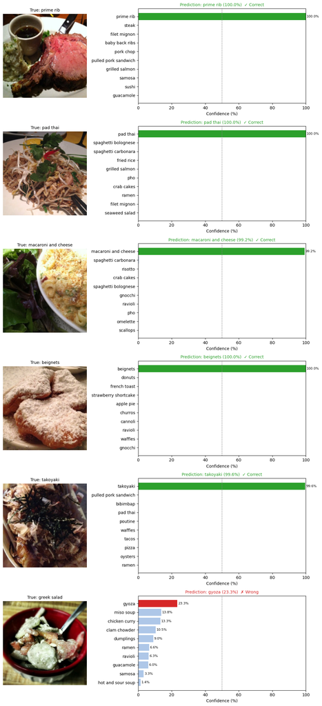

```
✓ Section 9 complete — best ResNet-50 weights: cnn_resnet50_best.pt
```

```python
# ── 9.6  Prediction visualiser — ResNet-50 ────────────────────────────────────
# Reuses plot_predictions() from Section 8.6.
# Different seed → different test samples than Section 8.6.
resnet50.load_state_dict(load_checkpoint("cnn_resnet50_best.pt"))
plot_predictions(resnet50, img_test_ds, seed=99,
                 save_filename="resnet50_predictions.png")
print("\n✓ Section 9 complete — best ResNet-50 weights: cnn_resnet50_best.pt")
```

### 9.7 — CNN Scratch vs. ResNet-50: Discussion

[output not shown]

#### Why ResNet-50 outperforms by such a large margin

**1. ImageNet pre-training — a 14-million-image head start.**  
ResNet-50 was trained on 14 million ImageNet images before it saw a single food photo. It already recognises textures (crispy batter, glossy sauce, flaky pastry), shapes (round, layered, irregular), and lighting patterns. The CNN scratch model builds all of these representations from 75,750 training images alone — an order of magnitude less data for a far harder initialisation problem.

**2. Representational depth — 50 layers vs. 4 blocks.**  
ResNet-50 has 50 convolutional layers and residual skip connections that allow gradients to flow cleanly through the entire network. The scratch CNN has 4 double-conv blocks, giving it roughly 8 conv layers. With 101 classes to separate, many of them visually similar (spaghetti bolognese vs. spaghetti carbonara; chocolate cake vs. red velvet cake), shallow architectures cannot build fine-grained discriminative representations in the final layers.

**3. Two-phase fine-tuning — stable feature extraction before specialisation.**  
Phase A froze the backbone and trained only the classification head for 5 epochs. This prevented the pre-trained features from being corrupted by noisy early gradients. Phase B then unfroze only layer4 — the final ResNet block — and fine-tuned at a 10x lower learning rate (1e-4 vs 1e-3). This controlled unfreezing preserved low-level features (edges, textures) while adapting high-level features (food-specific patterns) to the target domain.

**4. Domain similarity — ImageNet contains food.**  
ImageNet includes food categories (bananas, pizza, strawberries, ice cream). The pre-trained feature maps are not just generically useful — they are specifically well-calibrated for the visual properties of food photography: colour saturation, plated presentation, overhead angles. The scratch CNN must discover all of this without any prior.

#### Failure mode analysis

ResNet-50 recovers faster from these ambiguous pairs because its deeper feature hierarchy captures subtle cues (sauce sheen, garnish colour, crust texture) that the scratch model cannot resolve at its depth.

## Section 10 — CNN Explainability: Grad-CAM

Grad-CAM (Gradient-weighted Class Activation Mapping) visualises **which spatial regions** of a food image drove ResNet-50's classification decision. Examining where the model attends confirms it uses food-relevant features (textures, plating shapes, garnish colour) rather than background artefacts.

Six representative examples are shown — two correct top-1 predictions, two wrong top-1 (true class not in top-5), and two top-5 hits (correct class recognised but not ranked first).

| Sub-section | What |
| --- | --- |
| **10.1** | Restore prerequisites after kernel restart (skip if session still active) |
| **10.2** | Grad-CAM visualisation — 6 annotated examples |

### 10.1 — Restore prerequisites after kernel restart

After reconnecting to Colab, re-run **Section 1** (imports, paths, helpers) first, then run this cell to rebuild `resnet50` and `img_test_loader`. Skip entirely if the session is still active.

```python
# ── 10.1  Restore prerequisites after kernel restart ─────────────────────────
# Prerequisites: Section 1 (imports, paths, DEVICE, load_checkpoint, save_figure).
# Skip this cell if the session is still active — resnet50 is already in memory.

# Rebuild ResNet-50 and load best weights
resnet50 = models.resnet50(weights=None)
resnet50.fc = nn.Linear(2048, 101)
resnet50 = resnet50.to(DEVICE)
resnet50.load_state_dict(load_checkpoint("cnn_resnet50_best.pt"))
resnet50.eval()
print("resnet50 — best weights loaded (cnn_resnet50_best.pt)")

# Rebuild img_test_loader using the Food-101 raw test split.
# For Grad-CAM visualisation we just need individual images — the 70/15/15 split
# is not required here (the full Food-101 test set is used as the sample pool).
_vis_transform = T.Compose([
    T.Resize(256), T.CenterCrop(224), T.ToTensor(),
    T.Normalize(mean=IMAGENET_MEAN, std=IMAGENET_STD),
])
_vis_ds         = Food101(root=DATA_DIR, split="test", transform=_vis_transform)
img_test_loader = DataLoader(_vis_ds, batch_size=IMG_BATCH, shuffle=False,
                             num_workers=2, pin_memory=True)
print(f"img_test_loader — {len(_vis_ds):,} images (Food-101 test split)")
print("✓ 10.1 — prerequisites restored.")
```

```
  → Loading from VM: weights/cnn_resnet50_best.pt
resnet50 — best weights loaded (cnn_resnet50_best.pt)
```

[output not shown]

### 10.2 — Grad-CAM visualisation

Hooks into `layer4[-1]` (the final residual block) to capture activations and gradients, then overlays the resulting heatmap on the original image using `torchcam`.

- **Row 1** — original food image with true label, predicted label, and case tag
- **Row 2** — Grad-CAM overlay (warm regions = high activation, cool = low activation)
- Green title = correct top-1 | Orange = top-5 hit (wrong top-1) | Red = complete miss

> **Requires:** `pip install torchcam` — run once per Colab session.

```
  → Loading from VM: weights/cnn_resnet50_best.pt
  ✓ gradcam_resnet50.png  →  Colab VM + Drive
```

[figure not shown]

```
✓ Section 10 complete — Grad-CAM figure saved → gradcam_resnet50.png
```

```python
# ── 10.2  Grad-CAM visualisation ─────────────────────────────────────────────
# !pip install torchcam   ← run once per session if not installed
from torchcam.methods import GradCAM
from torchcam.utils   import overlay_mask
from torchvision.transforms.functional import to_pil_image

_CLASS_NAMES = _base_train_meta.classes   # 101 Food-101 class names
_MEAN = torch.tensor(IMAGENET_MEAN).view(3, 1, 1)
_STD  = torch.tensor(IMAGENET_STD).view(3, 1, 1)

resnet50.load_state_dict(load_checkpoint("cnn_resnet50_best.pt"))
resnet50.eval()
cam_extractor = GradCAM(resnet50, target_layer="layer4")

# ── Collect 6 representative examples from the test loader ────────────────────
examples = {"correct": [], "top5": [], "wrong": []}
for imgs, labels in img_test_loader:
    imgs_dev = imgs.to(DEVICE)
    logits   = resnet50(imgs_dev)
    top5     = logits.topk(5, dim=1).indices.cpu()
    top1     = logits.argmax(1).cpu()
    for i in range(len(labels)):
        lbl = labels[i].item()
        if top1[i] == lbl and len(examples["correct"]) < 2:
            examples["correct"].append((imgs[i].detach(), lbl, top1[i].item(), "correct ✓"))
        elif top1[i] != lbl and lbl in top5[i].tolist() and len(examples["top5"]) < 2:
            examples["top5"].append((imgs[i].detach(), lbl, top1[i].item(), "top-5 hit"))
        elif top1[i] != lbl and lbl not in top5[i].tolist() and len(examples["wrong"]) < 2:
            examples["wrong"].append((imgs[i].detach(), lbl, top1[i].item(), "wrong ✗"))
    if all(len(v) >= 2 for v in examples.values()):
        break

all_ex = examples["correct"] + examples["top5"] + examples["wrong"]

# ── Plot: row 0 = original image, row 1 = Grad-CAM overlay ───────────────────
fig, axes = plt.subplots(2, 6, figsize=(22, 8))
_color_map = {"correct ✓": "green", "top-5 hit": "orange", "wrong ✗": "red"}

for col, (img_t, true_lbl, pred_lbl, case) in enumerate(all_ex):
    out = resnet50(img_t.unsqueeze(0).to(DEVICE))
    cam = cam_extractor(pred_lbl, out)[0]

    orig    = (img_t.cpu() * _STD + _MEAN).clamp(0, 1)
    overlay = overlay_mask(to_pil_image(orig), to_pil_image(cam.squeeze(0)), alpha=0.5)

    color = _color_map[case]
    axes[0, col].imshow(to_pil_image(orig))
    axes[0, col].set_title(
        f"True: {_CLASS_NAMES[true_lbl].replace('_', ' ')}\n"
        f"Pred: {_CLASS_NAMES[pred_lbl].replace('_', ' ')}\n"
        f"[{case}]",
        fontsize=7, color=color)
    axes[0, col].axis("off")
    axes[1, col].imshow(overlay)
    axes[1, col].set_title("Grad-CAM", fontsize=7)
    axes[1, col].axis("off")

plt.suptitle("Section 10 — Grad-CAM: what ResNet-50 attends to when classifying food",
             fontsize=12)
plt.tight_layout()
save_figure(fig, "gradcam_resnet50.png")
plt.show()
cam_extractor.remove_hooks()
print("✓ Section 10 complete — Grad-CAM figure saved → gradcam_resnet50.png")
```

## Section 11 — RNN / LSTM Branch (Text Model)

This section trains **three text classification models** on the **WineSensed** wine-review dataset to predict **grape variety** (15 classes) from tasting-note text, progressing from a simple recurrent baseline to a pre-trained Transformer encoder.

### Sub-sections

[output not shown]

### Model overview

[output not shown]

### Design choices (LSTM / BiLSTM)

| Choice | Rationale |
| --- | --- |
| W2V 100-d embeddings, fine-tuned | Trained directly on wine reviews (§7.4) — captures domain vocabulary (`tannins`, `terroir`, `minerality`); embedding weights are further adapted during RNN training |
| `pack_padded_sequence` | Ignores `<PAD>` positions during LSTM forward pass — correct gradient flow |
| Gradient clipping (max-norm 5) | Standard RNN stability measure |
| Weighted CrossEntropy | Corrects for class imbalance across 15 grape varieties (`CLASS_WEIGHTS` from §7.5) |
| Early stopping (patience = 4) | Prevents overfitting on the relatively small WineSensed corpus |
| Per-epoch Drive checkpoints | Full state saved each epoch — training can resume after a Colab disconnect |

### Design choices (DistilBERT)

| Choice | Rationale |
| --- | --- |
| Frozen backbone | Avoids catastrophic forgetting on the small wine dataset; only the 15-class head is updated |
| `[CLS]` token pooling | Standard BERT practice — the `[CLS]` position is pre-trained to summarise the full sequence |
| Sub-word tokenisation | Handles domain-specific words (e.g. `terroir` → `terr`, `##oir`) without OOV issues |
| `max_len = 128` | Covers >95% of wine review lengths; GPU-memory-friendly |

**Prerequisites:** Section 1 (imports, `DEVICE`, `load_checkpoint`, `save_figure`), §4.1 (splits), §7.1–7.6 (`X_train/val/test`, `lbl_train/val/test`, `VOCAB`, `VOCAB_SIZE`, `MAX_SEQ_LEN`, `embedding_matrix`, `CLASS_WEIGHTS`)

### 11.1 — Text Dataset and DataLoaders

`WineTextDataset` wraps the integer-encoded sequences, their real non-padding lengths (required for `pack_padded_sequence`), and integer grape labels. This cell builds `txt_train_loader`, `txt_val_loader`, and `txt_test_loader` shared by all three text models in §11.

```python
# ── 11.1  Text Dataset and DataLoaders ───────────────────────────────────────
from torch.nn.utils.rnn import pack_padded_sequence, pad_packed_sequence

class WineTextDataset(torch.utils.data.Dataset):
    """Dataset for padded token-id sequences + sequence lengths + labels."""
    def __init__(self, sequences, labels):
        self.X       = torch.tensor(sequences, dtype=torch.long)
        self.y       = torch.tensor(labels,    dtype=torch.long)
        self.lengths = (self.X != 0).sum(dim=1).clamp(min=1)

    def __len__(self):
        return len(self.y)

    def __getitem__(self, i):
        return self.X[i], self.lengths[i], self.y[i]


TXT_BATCH = 64

txt_train_ds = WineTextDataset(X_train, lbl_train)
txt_val_ds   = WineTextDataset(X_val,   lbl_val)
txt_test_ds  = WineTextDataset(X_test,  lbl_test)

txt_train_loader = DataLoader(txt_train_ds, batch_size=TXT_BATCH, shuffle=True,
                               num_workers=0, pin_memory=False)
txt_val_loader   = DataLoader(txt_val_ds,   batch_size=TXT_BATCH, shuffle=False,
                               num_workers=0, pin_memory=False)
txt_test_loader  = DataLoader(txt_test_ds,  batch_size=TXT_BATCH, shuffle=False,
                               num_workers=0, pin_memory=False)

print(f"{'Split':<10} {'Samples':>8}  {'Batches':>8}")
print("-" * 30)
for _name, _ds, _ldr in [("train", txt_train_ds, txt_train_loader),
                          ("val",   txt_val_ds,   txt_val_loader),
                          ("test",  txt_test_ds,  txt_test_loader)]:
    print(f"{_name:<10} {len(_ds):>8,}  {len(_ldr):>8,}")

_xb_t, _lb_t, _yb_t = next(iter(txt_train_loader))
print(f"\nBatch shapes:")
print(f"  sequences : {_xb_t.shape}   (B x MAX_SEQ_LEN={MAX_SEQ_LEN})")
print(f"  lengths   : {_lb_t.shape}   min={_lb_t.min()}, max={_lb_t.max()}")
print(f"  labels    : {_yb_t.shape}   classes 0-{_yb_t.max()}")
print(f"\n✓ 11.1 — Text DataLoaders ready.")
```

```
Split       Samples   Batches
------------------------------
train        14,537       228
val           3,115        49
test          3,116        49

Batch shapes:
  sequences : torch.Size([64, 61])   (B x MAX_SEQ_LEN=61)
  lengths   : torch.Size([64])   min=5, max=61
  labels    : torch.Size([64])   classes 0-14

✓ 11.1 — Text DataLoaders ready.
```

### 11.2 — Variation 1: Unidirectional LSTM Baseline

**Architecture:**

```
Input (B × L)  →  Embedding (W2V 100-d, fine-tuned)
               →  Dropout(0.4)
               →  LSTM (100-d → 256-d, 2 layers, unidirectional)
               →  Last hidden state of final layer  (B × 256)
               →  Dropout(0.4)
               →  Linear(256 → 15)
```

- Reads each wine review **left-to-right only**; the final hidden state summarises the whole sequence.
- `pack_padded_sequence` ensures `<PAD>` tokens do not contribute to gradients.
- This is the **baseline** — deliberately simple so improvements in §11.6 are clearly attributable to bidirectionality and attention.

```python
# ── 11.2  Unidirectional LSTM Baseline ───────────────────────────────────────
class LSTMBaseline(nn.Module):
    def __init__(self, vocab_size, embed_dim, hidden_dim, n_classes,
                 n_layers=2, dropout=0.4, embedding_matrix=None):
        super().__init__()
        self.embedding = nn.Embedding(vocab_size, embed_dim, padding_idx=0)
        if embedding_matrix is not None:
            self.embedding.weight.data.copy_(
                torch.tensor(embedding_matrix, dtype=torch.float32))
        self.lstm = nn.LSTM(embed_dim, hidden_dim, num_layers=n_layers,
                            batch_first=True,
                            dropout=dropout if n_layers > 1 else 0.0)
        self.drop = nn.Dropout(dropout)
        self.fc   = nn.Linear(hidden_dim, n_classes)

    def forward(self, x, lengths):
        emb    = self.drop(self.embedding(x))
        packed = pack_padded_sequence(emb, lengths.cpu(),
                                      batch_first=True, enforce_sorted=False)
        _, (hidden, _) = self.lstm(packed)
        out = self.drop(hidden[-1])
        return self.fc(out)

    def encode(self, x, lengths):
        emb    = self.embedding(x)
        packed = pack_padded_sequence(emb, lengths.cpu(),
                                      batch_first=True, enforce_sorted=False)
        _, (hidden, _) = self.lstm(packed)
        return hidden[-1]


HIDDEN_DIM  = 256
N_LAYERS    = 2
DROPOUT_RNN = 0.4

lstm_model = LSTMBaseline(
    vocab_size=VOCAB_SIZE, embed_dim=EMBED_DIM, hidden_dim=HIDDEN_DIM,
    n_classes=len(GRAPE_CLASSES), n_layers=N_LAYERS, dropout=DROPOUT_RNN,
    embedding_matrix=embedding_matrix,
).to(DEVICE)

_total = sum(p.numel() for p in lstm_model.parameters())
print(f"LSTMBaseline — total params : {_total:,}")
_out_lstm = lstm_model(_xb_t.to(DEVICE), _lb_t.to(DEVICE))
assert _out_lstm.shape == (TXT_BATCH, len(GRAPE_CLASSES))
print(f"Forward pass  : OK → {_out_lstm.shape}")
print("✓ 11.2 — LSTMBaseline ready.")
```

```
LSTMBaseline — total params : 1,326,183
Forward pass  : OK → torch.Size([64, 15])
✓ 11.2 — LSTMBaseline ready.
```

### 11.3 — Shared training utilities

Two helper functions shared by the LSTM Baseline (§11.4) and BiLSTM + Attention (§11.7):

| Function | Role |
| --- | --- |
| `train_text_epoch(model, loader, criterion, optimizer)` | One full training pass; returns mean loss and accuracy |
| `eval_text(model, loader, criterion)` | No-grad validation/test pass; returns mean loss and accuracy |

```python
# ── 11.3  Shared text training utilities ─────────────────────────────────────
def train_text_epoch(model, loader, criterion, optimizer):
    model.train()
    total_loss, correct, n = 0.0, 0, 0
    for seqs, lengths, labels in loader:
        seqs, lengths, labels = seqs.to(DEVICE), lengths.to(DEVICE), labels.to(DEVICE)
        optimizer.zero_grad()
        logits = model(seqs, lengths)
        loss   = criterion(logits, labels)
        loss.backward()
        nn.utils.clip_grad_norm_(model.parameters(), max_norm=5.0)
        optimizer.step()
        total_loss += loss.item() * len(labels)
        correct    += (logits.argmax(1) == labels).sum().item()
        n          += len(labels)
    return total_loss / n, correct / n

@torch.no_grad()
def eval_text(model, loader, criterion):
    model.eval()
    total_loss, correct, n = 0.0, 0, 0
    for seqs, lengths, labels in loader:
        seqs, lengths, labels = seqs.to(DEVICE), lengths.to(DEVICE), labels.to(DEVICE)
        logits      = model(seqs, lengths)
        total_loss += criterion(logits, labels).item() * len(labels)
        correct    += (logits.argmax(1) == labels).sum().item()
        n          += len(labels)
    return total_loss / n, correct / n

criterion_txt = nn.CrossEntropyLoss(weight=CLASS_WEIGHTS.to(DEVICE))
print("✓ 11.3 — training utilities ready.")
print(f"  criterion_txt : CrossEntropyLoss(weight=CLASS_WEIGHTS)  — {len(GRAPE_CLASSES)} classes")
```

```
✓ 11.3 — training utilities ready.
  criterion_txt : CrossEntropyLoss(weight=CLASS_WEIGHTS)  — 15 classes
```

### 11.4 — Training the LSTM Baseline

| Setting | Value |
| --- | --- |
| Optimiser | Adam, lr = 1e-3, weight_decay = 1e-5 |
| LR scheduler | ReduceLROnPlateau × 0.5, patience 2 |
| Max epochs | 30 |
| Early stopping | patience = 4 |
| Gradient clipping | max-norm 5 |

Best weights saved to `weights/lstm_best.pt`.

```python
# ── 11.4  Train the LSTM Baseline ────────────────────────────────────────────
TXT_EPOCHS   = 30
TXT_PATIENCE = 4

opt_lstm   = Adam(lstm_model.parameters(), lr=1e-3, weight_decay=1e-5)
sched_lstm = ReduceLROnPlateau(opt_lstm, factor=0.5, patience=2)

history_lstm       = {"train_loss": [], "val_loss": [], "train_acc": [], "val_acc": []}
best_val_loss_lstm = float("inf")
no_improve_lstm    = 0
best_ckpt_lstm     = WEIGHTS / "lstm_best.pt"

print(f"Training LSTMBaseline  (max {TXT_EPOCHS} epochs, patience={TXT_PATIENCE})")
print(f"{'Epoch':>5}  {'tr_loss':>8}  {'tr_acc':>7}  {'vl_loss':>8}  {'vl_acc':>7}  {'lr':>9}")
print("-" * 57)

for epoch in range(1, TXT_EPOCHS + 1):
    tr_loss, tr_acc = train_text_epoch(lstm_model, txt_train_loader, criterion_txt, opt_lstm)
    vl_loss, vl_acc = eval_text(lstm_model, txt_val_loader, criterion_txt)
    history_lstm["train_loss"].append(tr_loss)
    history_lstm["val_loss"].append(vl_loss)
    history_lstm["train_acc"].append(tr_acc)
    history_lstm["val_acc"].append(vl_acc)
    sched_lstm.step(vl_loss)
    lr_now = opt_lstm.param_groups[0]["lr"]
    if vl_loss < best_val_loss_lstm:
        best_val_loss_lstm = vl_loss
        no_improve_lstm    = 0
        save_checkpoint(lstm_model.state_dict(), "lstm_best.pt")
        marker = " ✓"
    else:
        no_improve_lstm += 1
        marker = ""
    # ── per-epoch full checkpoint (enables resume after disconnect) ────────────
    save_checkpoint(
        {"epoch": epoch, "model_state": lstm_model.state_dict(),
         "optimizer_state": opt_lstm.state_dict(), "val_loss": vl_loss,
         "history": history_lstm},
        f"lstm_ckpt_ep{epoch:02d}.pt"
    )
    print(f"{epoch:>5}  {tr_loss:>8.4f}  {tr_acc:>7.4f}  {vl_loss:>8.4f}  {vl_acc:>7.4f}  {lr_now:>9.2e}{marker}")
    if no_improve_lstm >= TXT_PATIENCE:
        print(f"\nEarly stopping at epoch {epoch}.")
        break

print(f"\nBest val loss : {best_val_loss_lstm:.4f}  →  {best_ckpt_lstm}")
print("✓ 11.4 — LSTM Baseline training complete.")
```

```
Training LSTMBaseline  (max 30 epochs, patience=4)
Epoch   tr_loss   tr_acc   vl_loss   vl_acc         lr
---------------------------------------------------------
  ✓ lstm_best.pt  →  Colab VM + Drive
  ✓ lstm_ckpt_ep01.pt  →  Colab VM + Drive
    1    2.7140   0.0931    2.7334   0.2729   1.00e-03 ✓
  ✓ lstm_best.pt  →  Colab VM + Drive
  ✓ lstm_ckpt_ep02.pt  →  Colab VM + Drive
    2    2.6267   0.1703    2.5307   0.2109   1.00e-03 ✓
  ✓ lstm_ckpt_ep03.pt  →  Colab VM + Drive
    3    2.5640   0.1623    2.5545   0.2064   1.00e-03
  ✓ lstm_ckpt_ep04.pt  →  Colab VM + Drive
    4    2.4717   0.1620    2.5353   0.1538   1.00e-03
  ✓ lstm_best.pt  →  Colab VM + Drive
  ✓ lstm_ckpt_ep05.pt  →  Colab VM + Drive
    5    2.3816   0.1878    2.5286   0.1011   1.00e-03 ✓
  ✓ lstm_best.pt  →  Colab VM + Drive
  ✓ lstm_ckpt_ep06.pt  →  Colab VM + Drive
    6    2.2838   0.1727    2.4320   0.1839   1.00e-03 ✓
  ✓ lstm_ckpt_ep07.pt  →  Colab VM + Drive
    7    2.1847   0.2028    2.4680   0.1560   1.00e-03
  ✓ lstm_ckpt_ep08.pt  →  Colab VM + Drive
    8    2.0981   0.2144    2.4554   0.1669   1.00e-03
  ✓ lstm_ckpt_ep09.pt  →  Colab VM + Drive
    9    1.9547   0.2275    2.5096   0.2029   5.00e-04
  ✓ lstm_ckpt_ep10.pt  →  Colab VM + Drive
   10    1.8205   0.2713    2.5849   0.2006   5.00e-04

Early stopping at epoch 10.

Best val loss : 2.4320  →  weights/lstm_best.pt
✓ 11.4 — LSTM Baseline training complete.
```